# Epidemic Zones Analysis

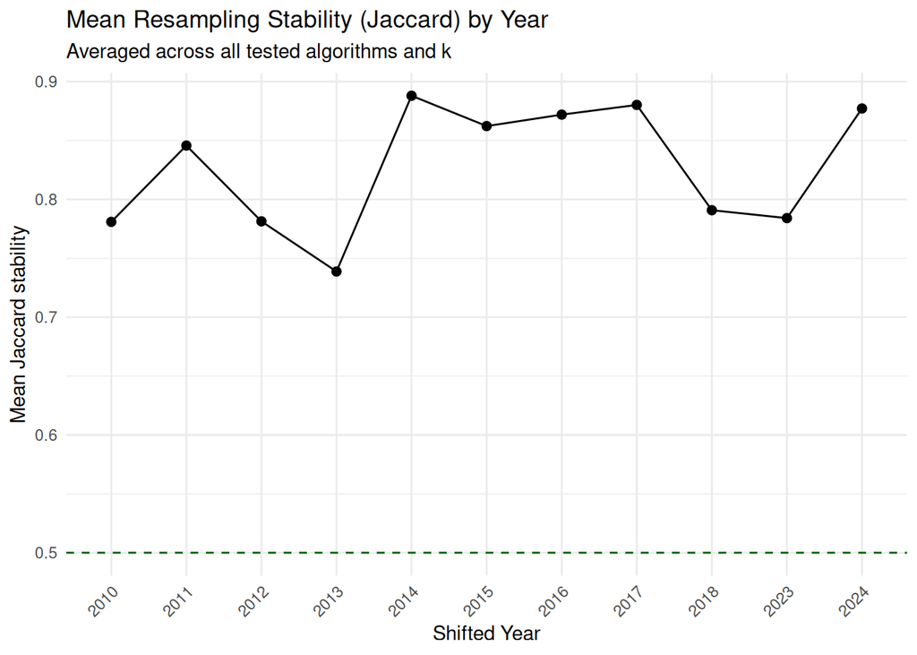

```r
plot_year_stability(all_year_stability_shifted) +
  labs(x = "Shifted Year")
```

Most of the results for years in both partitions hover around the 0.8 value for the calculated Jaccard index. Showing relatively high stability.

We can also plot a heatmap of the consensus results from each partition to get a better sense of the results.

First for the calendar year partition:

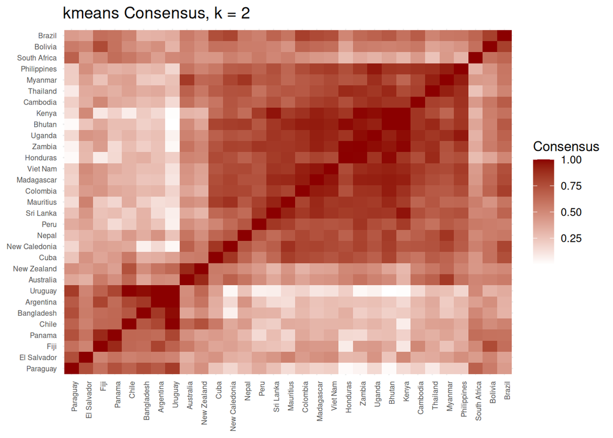

```r
plot_consensus_heatmap(pipeline_calendar_final$consensus$kmeans$k2,
                       title = paste(CHOSEN_ALGO, "Consensus, k =", K_FINAL),
                       country_lookup = pipeline_calendar_final$country_lookup)
```

And then for the shifted year partition:

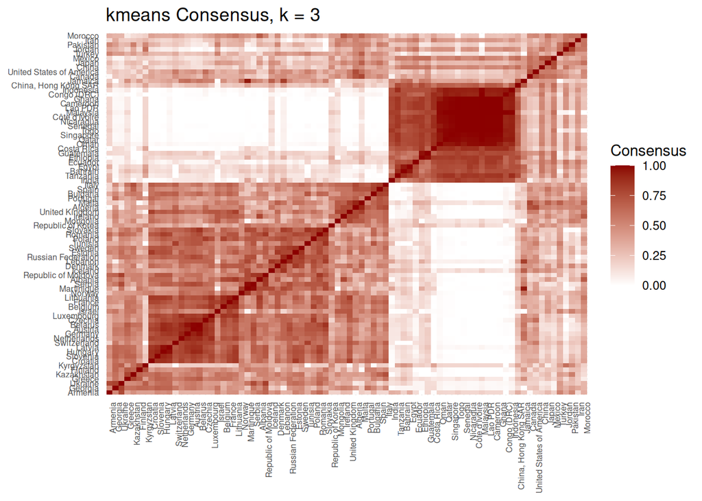

```r
plot_consensus_heatmap(pipeline_shifted_final$consensus$kmeans$k3,
                       title = paste(CHOSEN_ALGO, "Consensus, k =", K_FINAL_SHIFTED),
                       country_lookup = pipeline_shifted_final$country_lookup)
```

### 5.5 Final Consensus Clustering from Clustering Ensemble

There are many methods that can be used for determining the final clustering from an ensemble consensus matrix. This can be done by computing hierarchical clustering directly from the matrix, or transforming the matrix into a graph object and using a graph clustering algorithm. We’ll assess our final ensembles by computing the Dunn index for each of these methods given our final chosen k values and algorithm.

First for the calendar year partition:

```r
consensus_validity <- compare_k_selection_all_methods(pipeline_calendar_final$consensus$kmeans$k2,
                                                      k_range = K_FINAL,
                                                      country_lookup = pipeline_calendar$country_lookup)
```

```
## Final clustering: hierarchical (ward.D2 linkage) on (1 - consensus matrix), k = 2
```

```
## Final clustering: louvain, resolution = 0.950, k = 2
```

```
## Final clustering: leiden, resolution = 0.950, k = 2
```

```
## Final clustering: walktrap, k = 2
```

```
## Final clustering: spectral (kernlab::specc), k = 2
## (graph_obj built afterward for plotting only -- clustering used the consensus matrix directly)
```

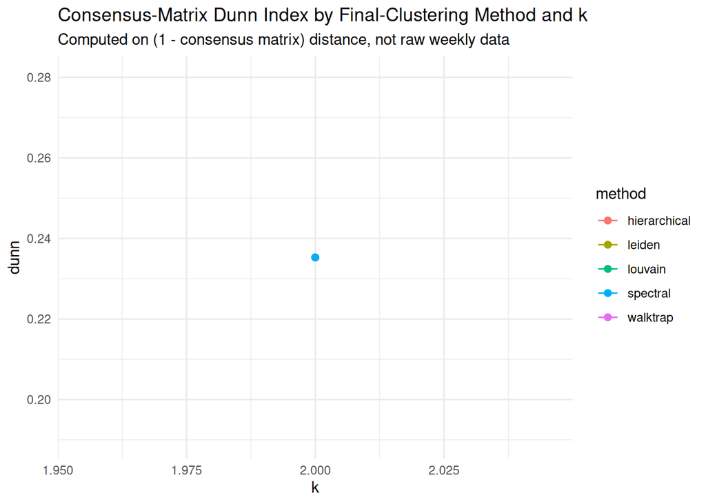

```r
plot_consensus_validity_compare(consensus_validity, metric = "dunn")
```

And then for the shifted year partition:

```r
consensus_validity_shifted <- compare_k_selection_all_methods(pipeline_shifted_final$consensus$kmeans$k3,
                                                              k_range = K_FINAL_SHIFTED,
                                                              country_lookup = pipeline_shifted_final$country_lookup)
```

```
## Final clustering: hierarchical (ward.D2 linkage) on (1 - consensus matrix), k = 3
```

```
## Final clustering: louvain, resolution = 1.050, k = 3
```

```
## Final clustering: leiden, resolution = 1.050, k = 3
```

```
## Final clustering: walktrap, k = 3
```

```
## Final clustering: spectral (kernlab::specc), k = 3
## (graph_obj built afterward for plotting only -- clustering used the consensus matrix directly)
```

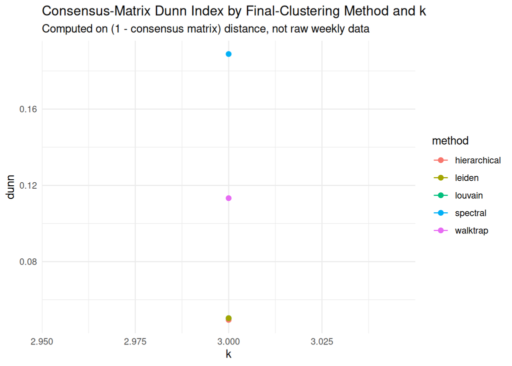

```r
plot_consensus_validity_compare(consensus_validity_shifted, metric = "dunn")
```

Given the verification and logical support, we will apply the `spectral` method for the final clustering results. And then plot the final results on a global map to see the geographic distribution.

```r
final_calendar_clustering <- extract_final_clusters_graph(pipeline_calendar_final$consensus$kmeans$k2,
                                                          K_FINAL,
                                                          country_lookup = pipeline_calendar_final$country_lookup,
                                                          algorithm = "spectral")
```

```
## Final clustering: spectral (kernlab::specc), k = 2
## (graph_obj built afterward for plotting only -- clustering used the consensus matrix directly)
```

```r
final_shifted_clustering <- extract_final_clusters_graph(pipeline_shifted_final$consensus$kmeans$k3,
                                                         K_FINAL_SHIFTED,
                                                         country_lookup = pipeline_shifted$country_lookup,
                                                         algorithm = "spectral")
```

```
## Final clustering: spectral (kernlab::specc), k = 3
## (graph_obj built afterward for plotting only -- clustering used the consensus matrix directly)
```

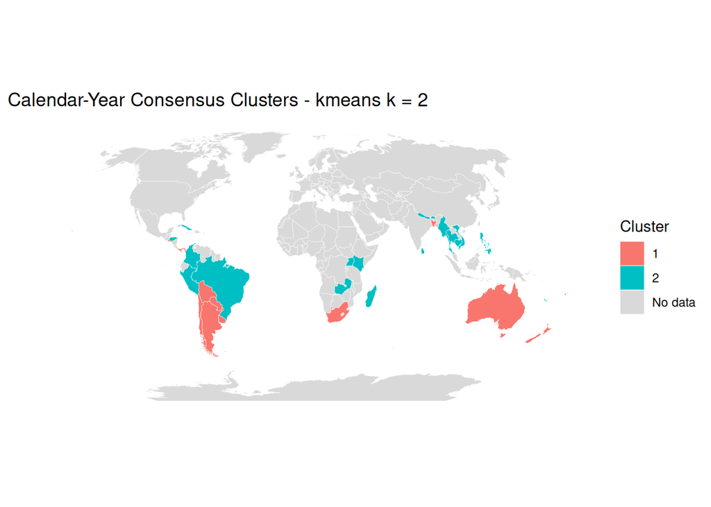

```r
plot_cluster_map(final_calendar_clustering$labels,
                 title = paste("Calendar-Year Consensus Clusters -", CHOSEN_ALGO, "k =", K_FINAL))
```

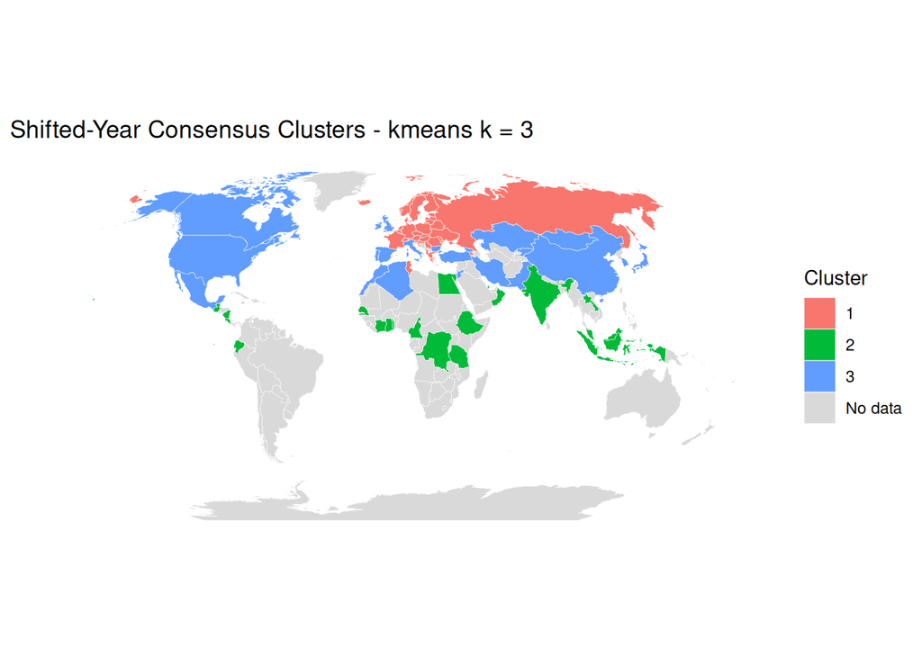

```r
plot_cluster_map(final_shifted_clustering$labels,
                 title = paste("Shifted-Year Consensus Clusters -", CHOSEN_ALGO, "k =", K_FINAL_SHIFTED))
```

Clusters appear to have good relative latitudinal congruence, which is expected given previous knowledge on influenza seasonality.

We can also assess a countries cluster membership stability by consensus matrix values against all other members of its final cluster and by the raw resampling percentages of the times the said country ends up in it’s cluster. First for the calendar year partition:

```r
item_cons <- compute_item_consensus(pipeline_calendar_final$consensus$kmeans$k2,
                                    final_calendar_clustering$labels)

boot_pct <- compute_bootstrap_membership_pct(pipeline_calendar_final$year_mats,
                                             final_calendar_clustering$labels,
                                             algo = CHOSEN_ALGO,
                                             k = K_FINAL,
                                             resample_pct = RESAMPLE_PCT,
                                             n_boot = 1000)

raw_cluster_tally <- compute_raw_cluster_tally(pipeline_calendar_final$year_mats,
                                               algo = CHOSEN_ALGO,
                                               k = K_FINAL,
                                               resample_pct = RESAMPLE_PCT,
                                               n_boot = 1000)
```

```
## No reference_year specified -- using '2019' (most countries: 31)
##
## Reference clustering built from year '2019', algorithm 'kmeans', k = 2, resample_pct = 0.90
##
## Most-shifting countries (highest shift_score = assignment most split across clusters):
##     country_code n_runs_present     modal_cluster shift_score
## AUS          AUS           9014 aligned_cluster_1   0.4896827
## BOL          BOL           9004 aligned_cluster_2   0.4336961
## ZAF          ZAF           8982 aligned_cluster_1   0.4149410
## SLV          SLV           7235 aligned_cluster_1   0.3990325
## NZL          NZL           8982 aligned_cluster_1   0.3975729
## FJI          FJI           4532 aligned_cluster_1   0.3793027
## CUB          CUB           9018 aligned_cluster_2   0.3031714
## BRA          BRA           8922 aligned_cluster_2   0.2945528
## NPL          NPL           8022 aligned_cluster_2   0.2597856
## CHL          CHL           9012 aligned_cluster_1   0.2543276
## PAN          PAN           7129 aligned_cluster_1   0.2543134
## MMR          MMR           4480 aligned_cluster_2   0.2354911
## PER          PER           9001 aligned_cluster_2   0.2338629
## ARG          ARG           9032 aligned_cluster_1   0.2022808
## BGD          BGD           8972 aligned_cluster_1   0.1978377
```

```r
raw_cluster_tally_y <- compute_raw_cluster_tally_by_year(pipeline_calendar_final$year_mats,
                                                          algo = CHOSEN_ALGO,
                                                          k = K_FINAL,
                                                          resample_pct = RESAMPLE_PCT,
                                                          n_boot = 1000)
```

```
## No reference_year specified -- using '2019' (most countries: 31)
##
## Reference clustering built from year '2019', algorithm 'kmeans', k = 2, resample_pct = 0.90
```

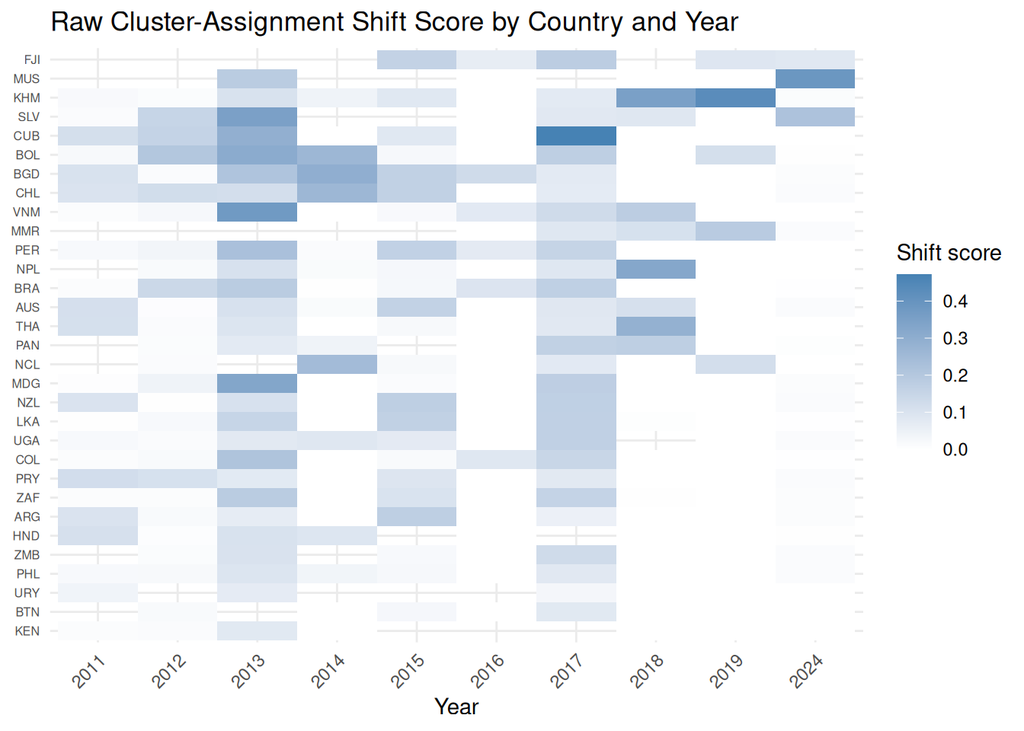

```r
plot_raw_cluster_shift_heatmap(tally_by_year_df = raw_cluster_tally_y)
```

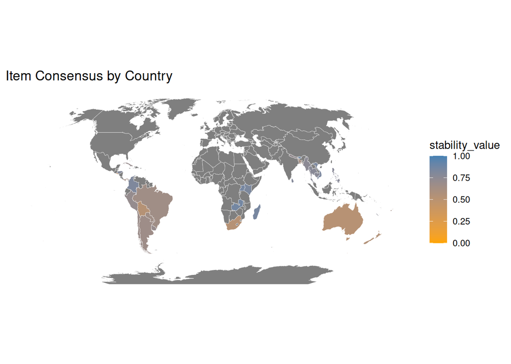

```r
# name the set for plotting
boot_pct_named <- setNames(boot_pct$bootstrap_membership_pct, boot_pct$country_code)

# stability table
stability_comparison <- boot_pct %>%
    mutate(item_consensus = round(item_cons[country_code], 3)) %>%
    { if (!is.null(pipeline_calendar_final$country_lookup)) mutate(., country_name = pipeline_calendar_final$country_lookup[country_code], .after = country_code) else . } %>%
    arrange(final_cluster, desc(bootstrap_membership_pct)) %>%
  rename(resampling_membership_pct = bootstrap_membership_pct)

plot_stability_map(item_cons, title = "Item Consensus by Country", legend_name = "Item consensus") +
  scale_fill_gradient(low = "orange", high = "steelblue", limits = c(0, 1), oob = scales::squish)
```

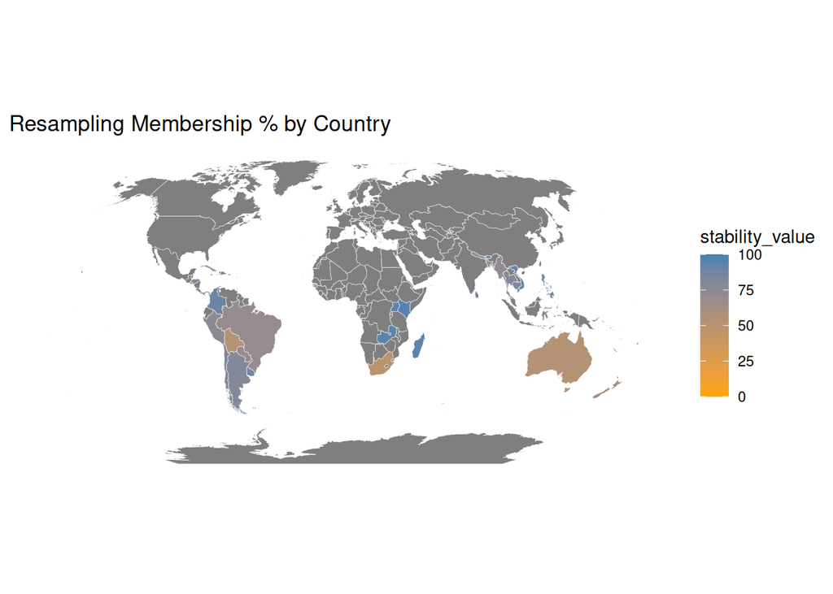

```r
plot_stability_map(boot_pct_named, title = "Resampling Membership % by Country", legend_name = "% in final cluster") +
  scale_fill_gradient(low = "orange", high = "steelblue", limits = c(0, 100), oob = scales::squish)
```

```r
# Summary by cluster
stability_comparison %>%
  group_by(final_cluster) %>%
  summarise(mean_resampling_membership_pct = mean(resampling_membership_pct),
            mean_item_consensus = mean(item_consensus)) %>%
  kable(format = "html") %>%
  kable_styling(bootstrap_options = c("striped", "hover", "condensed"), full_width = FALSE) %>%
  scroll_box(height = "400px")
```

| final_cluster | mean_resampling_membership_pct | mean_item_consensus |
| --- | --- | --- |
| 1 | 68.12500 | 0.6042500 |
| 2 | 84.20526 | 0.7848421 |

```r
# Display the raw table of values
stability_comparison %>%
  kable(format = "html") %>%
  kable_styling(bootstrap_options = c("striped", "hover", "condensed"), full_width = FALSE) %>%
  scroll_box(height = "400px")
```

| country_code | country_name | final_cluster | resampling_membership_pct | n_opportunities | item_consensus |
| --- | --- | --- | --- | --- | --- |
| URY | Uruguay | 1 | 87.9 | 5363 | 0.703 |
| CHL | Chile | 1 | 80.9 | 9011 | 0.678 |
| ARG | Argentina | 1 | 79.3 | 9030 | 0.662 |
| FJI | Fiji | 1 | 79.1 | 4532 | 0.643 |
| PRY | Paraguay | 1 | 72.0 | 8931 | 0.650 |
| BGD | Bangladesh | 1 | 71.3 | 8975 | 0.630 |
| PAN | Panama | 1 | 69.6 | 7126 | 0.641 |
| NZL | New Zealand | 1 | 61.2 | 8984 | 0.550 |
| SLV | El Salvador | 1 | 60.9 | 7238 | 0.522 |
| BOL | Bolivia | 1 | 53.5 | 8993 | 0.528 |
| AUS | Australia | 1 | 53.3 | 9013 | 0.519 |
| ZAF | South Africa | 1 | 48.5 | 8979 | 0.525 |
| BTN | Bhutan | 2 | 96.1 | 7146 | 0.875 |
| KEN | Kenya | 2 | 96.0 | 6299 | 0.826 |
| ZMB | Zambia | 2 | 94.5 | 7210 | 0.860 |
| MDG | Madagascar | 2 | 93.9 | 8984 | 0.845 |
| UGA | Uganda | 2 | 93.8 | 8038 | 0.851 |
| VNM | Viet Nam | 2 | 91.6 | 9017 | 0.833 |
| COL | Colombia | 2 | 89.2 | 8996 | 0.814 |
| MUS | Mauritius | 2 | 87.6 | 4479 | 0.791 |
| LKA | Sri Lanka | 2 | 87.3 | 9009 | 0.793 |
| KHM | Cambodia | 2 | 84.0 | 8963 | 0.771 |
| PHL | Philippines | 2 | 83.9 | 9042 | 0.777 |
| HND | Honduras | 2 | 83.6 | 7131 | 0.794 |
| NCL | New Caledonia | 2 | 80.2 | 7111 | 0.763 |
| THA | Thailand | 2 | 78.7 | 8944 | 0.773 |
| PER | Peru | 2 | 74.8 | 9004 | 0.712 |
| MMR | Myanmar | 2 | 73.2 | 4482 | 0.757 |
| NPL | Nepal | 2 | 71.3 | 8020 | 0.720 |
| BRA | Brazil | 2 | 70.5 | 8930 | 0.654 |
| CUB | Cuba | 2 | 69.7 | 9020 | 0.703 |

Then for the shifted year partition:

```r
item_cons_shifted <- compute_item_consensus(pipeline_shifted_final$consensus$kmeans$k3,
                                            final_shifted_clustering$labels)



boot_pct_shifted <- compute_bootstrap_membership_pct(pipeline_shifted_final$year_mats,
                                                     final_shifted_clustering$labels,
                                                     algo = CHOSEN_ALGO,
                                                     k = K_FINAL_SHIFTED,
                                                     resample_pct = RESAMPLE_PCT,
                                                     n_boot = 1000)

raw_cluster_tally_shifted <- compute_raw_cluster_tally(pipeline_shifted_final$year_mats,
                                                       algo = CHOSEN_ALGO,
                                                       k = K_FINAL_SHIFTED,
                                                       resample_pct = RESAMPLE_PCT,
                                                       n_boot = 1000)
```

```
## No reference_year specified -- using '2015' (most countries: 80)
##
## Reference clustering built from year '2015', algorithm 'kmeans', k = 3, resample_pct = 0.90
##
## Most-shifting countries (highest shift_score = assignment most split across clusters):
##     country_code n_runs_present     modal_cluster shift_score
## JAM          JAM           5363 aligned_cluster_1   0.6401268
## MAR          MAR           8105 aligned_cluster_2   0.6240592
## CAN          CAN           9934 aligned_cluster_1   0.6112341
## JPN          JPN           9875 aligned_cluster_3   0.6014177
## ISL          ISL           9884 aligned_cluster_3   0.5865034
## MLT          MLT           6293 aligned_cluster_1   0.5685683
## USA          USA           9923 aligned_cluster_1   0.5678726
## ARM          ARM           5397 aligned_cluster_1   0.5569761
## CHN          CHN           9892 aligned_cluster_2   0.5564092
## KOR          KOR           9878 aligned_cluster_3   0.5539583
## NOR          NOR           9869 aligned_cluster_1   0.5234573
## ESP          ESP           9912 aligned_cluster_1   0.5185634
## DZA          DZA           5430 aligned_cluster_1   0.5132597
## JOR          JOR           8079 aligned_cluster_3   0.5052606
## IRN          IRN           9903 aligned_cluster_2   0.5026760
```

```r
raw_cluster_tally_shifted_y <- compute_raw_cluster_tally_by_year(pipeline_shifted_final$year_mats,
                                                                 algo = CHOSEN_ALGO,
                                                                 k = K_FINAL_SHIFTED,
                                                                 resample_pct = RESAMPLE_PCT,
                                                                 n_boot = 1000)
```

```
## No reference_year specified -- using '2015' (most countries: 80)
##
## Reference clustering built from year '2015', algorithm 'kmeans', k = 3, resample_pct = 0.90
```

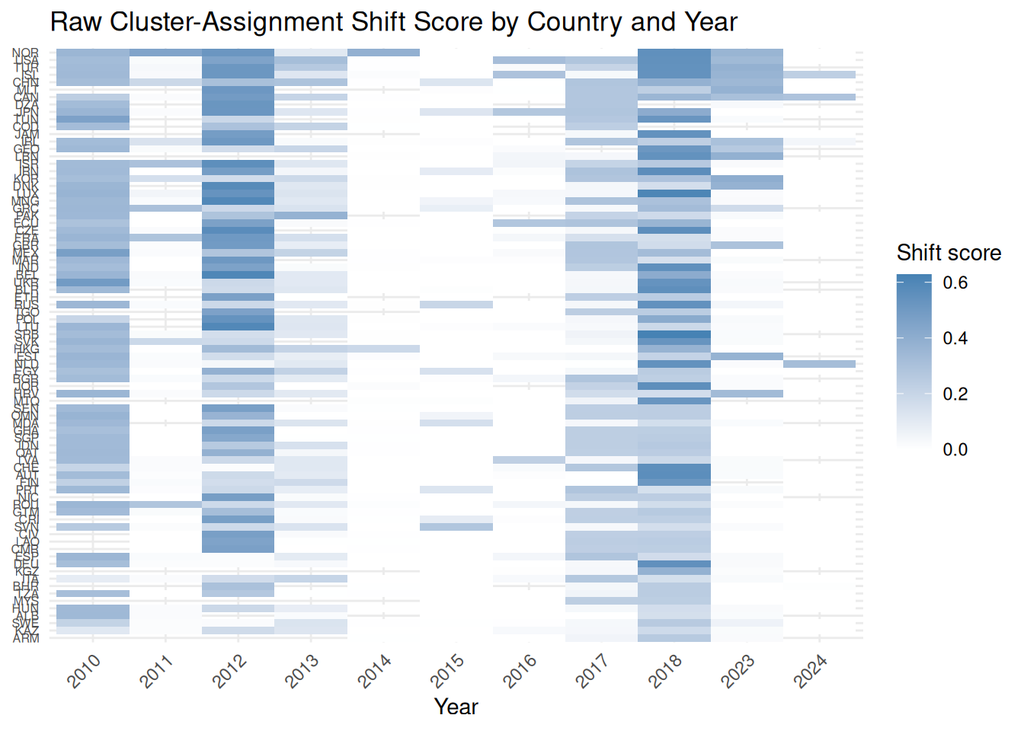

```r
plot_raw_cluster_shift_heatmap(tally_by_year_df = raw_cluster_tally_shifted_y)
```

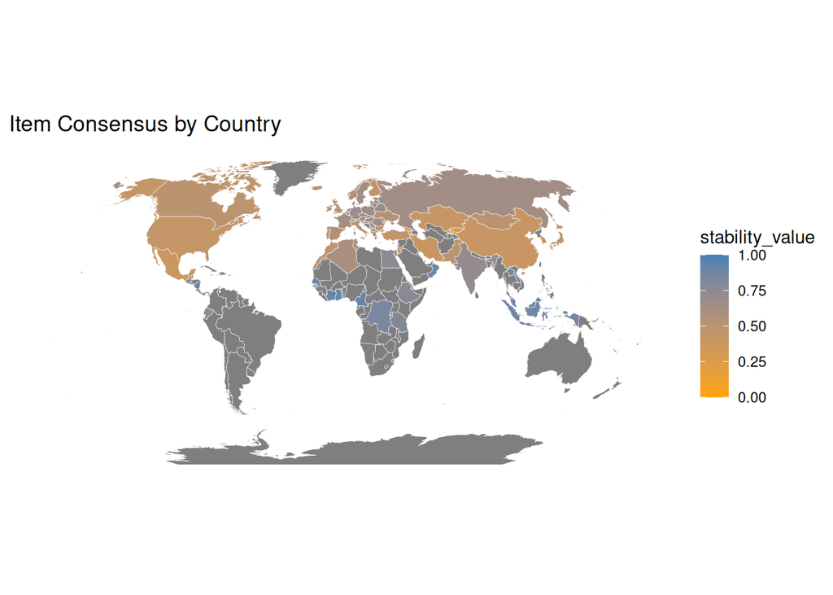

```r
# name the set for plotting
boot_pct_shifted_named <- setNames(boot_pct_shifted$bootstrap_membership_pct, boot_pct_shifted$country_code)

# stability table
stability_comparison_shifted <- boot_pct_shifted %>%
    mutate(item_consensus = round(item_cons_shifted[country_code], 3)) %>%
    { if (!is.null(pipeline_shifted_final$country_lookup)) mutate(., country_name = pipeline_shifted_final$country_lookup[country_code], .after = country_code) else . } %>%
    arrange(final_cluster, desc(bootstrap_membership_pct)) %>%
  rename(resampling_membership_pct = bootstrap_membership_pct)

plot_stability_map(item_cons_shifted, title = "Item Consensus by Country", legend_name = "Item consensus") +
  scale_fill_gradient(low = "orange", high = "steelblue", limits = c(0, 1), oob = scales::squish)
```

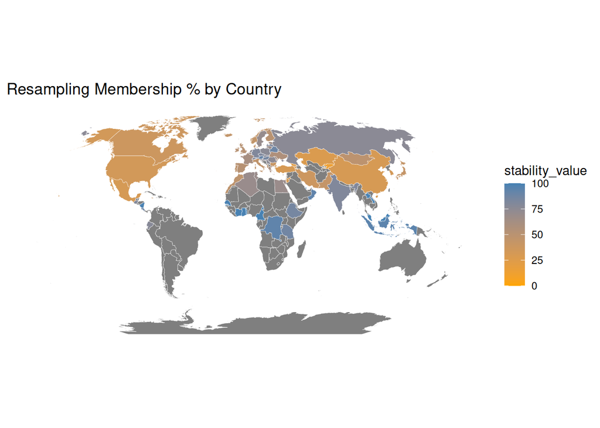

```r
plot_stability_map(boot_pct_shifted_named, title = "Resampling Membership % by Country", legend_name = "% in final cluster") +
  scale_fill_gradient(low = "orange", high = "steelblue", limits = c(0, 100), oob = scales::squish)
```

```r
# Summary by cluster
stability_comparison_shifted %>%
  group_by(final_cluster) %>%
  summarise(mean_resampling_membership_pct = mean(resampling_membership_pct),
            mean_item_consensus = mean(item_consensus)) %>%
  kable(format = "html") %>%
  kable_styling(bootstrap_options = c("striped", "hover", "condensed"), full_width = FALSE) %>%
  scroll_box(height = "400px")
```

| final_cluster | mean_resampling_membership_pct | mean_item_consensus |
| --- | --- | --- |
| 1 | 66.96765 | 0.6184412 |
| 2 | 89.90000 | 0.8328636 |
| 3 | 40.61250 | 0.4694583 |

```r
# Display the raw table of values
stability_comparison_shifted %>%
  kable(format = "html") %>%
  kable_styling(bootstrap_options = c("striped", "hover", "condensed"), full_width = FALSE) %>%
  scroll_box(height = "400px")
```

| country_code | country_name | final_cluster | resampling_membership_pct | n_opportunities | item_consensus |
| --- | --- | --- | --- | --- | --- |
| AUT | Austria | 1 | 90.2 | 9877 | 0.706 |
| BLR | Belarus | 1 | 88.3 | 8118 | 0.712 |
| HUN | Hungary | 1 | 85.3 | 9973 | 0.691 |
| CZE | Czechia | 1 | 81.3 | 9034 | 0.658 |
| LVA | Latvia | 1 | 81.2 | 9042 | 0.675 |
| DEU | Germany | 1 | 80.5 | 9929 | 0.692 |
| CHE | Switzerland | 1 | 79.1 | 9995 | 0.606 |
| SVK | Slovakia | 1 | 77.9 | 9020 | 0.674 |
| SVN | Slovenia | 1 | 76.7 | 9931 | 0.662 |
| POL | Poland | 1 | 76.6 | 8966 | 0.672 |
| RUS | Russian Federation | 1 | 76.3 | 9965 | 0.640 |
| SRB | Serbia | 1 | 76.0 | 8986 | 0.652 |
| ROU | Romania | 1 | 75.1 | 9917 | 0.679 |
| LUX | Luxembourg | 1 | 74.7 | 9957 | 0.671 |
| NLD | Netherlands | 1 | 74.4 | 9901 | 0.681 |
| HRV | Croatia | 1 | 72.1 | 9924 | 0.646 |
| SWE | Sweden | 1 | 70.4 | 9915 | 0.630 |
| TUN | Tunisia | 1 | 68.7 | 7228 | 0.569 |
| LTU | Lithuania | 1 | 67.2 | 9015 | 0.653 |
| EST | Estonia | 1 | 64.6 | 9000 | 0.642 |
| BEL | Belgium | 1 | 64.3 | 9895 | 0.633 |
| MDA | Republic of Moldova | 1 | 63.6 | 8100 | 0.624 |
| LBN | Lebanon | 1 | 63.2 | 5403 | 0.624 |
| FRA | France | 1 | 61.1 | 9932 | 0.627 |
| GRC | Greece | 1 | 61.1 | 8965 | 0.541 |
| UKR | Ukraine | 1 | 56.9 | 9011 | 0.522 |
| MTQ | Martinique | 1 | 53.7 | 4537 | 0.599 |
| ALB | Albania | 1 | 51.4 | 7232 | 0.605 |
| FIN | Finland | 1 | 50.4 | 8976 | 0.456 |
| DNK | Denmark | 1 | 46.2 | 9010 | 0.599 |
| NOR | Norway | 1 | 45.1 | 9846 | 0.555 |
| ISL | Iceland | 1 | 44.6 | 9893 | 0.527 |
| JAM | Jamaica | 1 | 44.0 | 5360 | 0.478 |
| ARM | Armenia | 1 | 34.7 | 5395 | 0.426 |
| MYS | Malaysia | 2 | 100.0 | 5387 | 0.892 |
| LAO | Lao PDR | 2 | 99.7 | 8948 | 0.908 |
| CMR | Cameroon | 2 | 99.6 | 9011 | 0.907 |
| TGO | Togo | 2 | 99.5 | 6335 | 0.895 |
| CIV | Côte d’Ivoire | 2 | 99.4 | 9034 | 0.907 |
| GHA | Ghana | 2 | 99.4 | 9859 | 0.901 |
| NIC | Nicaragua | 2 | 99.3 | 8048 | 0.907 |
| SEN | Senegal | 2 | 99.2 | 9942 | 0.900 |
| SGP | Singapore | 2 | 98.8 | 9883 | 0.901 |
| QAT | Qatar | 2 | 98.1 | 9875 | 0.899 |
| IDN | Indonesia | 2 | 94.4 | 9984 | 0.864 |
| COD | Congo (DRC) | 2 | 93.1 | 5411 | 0.835 |
| OMN | Oman | 2 | 92.8 | 9914 | 0.884 |
| CRI | Costa Rica | 2 | 88.4 | 9012 | 0.808 |
| TZA | Tanzania | 2 | 86.9 | 9900 | 0.802 |
| ETH | Ethiopia | 2 | 85.3 | 6298 | 0.770 |
| IND | India | 2 | 80.9 | 9925 | 0.712 |
| GTM | Guatemala | 2 | 79.7 | 9855 | 0.734 |
| ECU | Ecuador | 2 | 77.8 | 9904 | 0.749 |
| BHR | Bahrain | 2 | 69.5 | 6364 | 0.732 |
| EGY | Egypt | 2 | 68.8 | 9907 | 0.745 |
| HKG | China, Hong Kong SAR | 2 | 67.2 | 9935 | 0.671 |
| DZA | Algeria | 3 | 69.3 | 5429 | 0.598 |
| MLT | Malta | 3 | 62.5 | 6293 | 0.585 |
| IRL | Ireland | 3 | 51.7 | 9855 | 0.533 |
| ESP | Spain | 3 | 51.4 | 9905 | 0.544 |
| GBR | United Kingdom | 3 | 51.4 | 9842 | 0.523 |
| MNG | Mongolia | 3 | 48.7 | 9927 | 0.498 |
| PRT | Portugal | 3 | 47.7 | 9944 | 0.512 |
| MAR | Morocco | 3 | 47.6 | 8105 | 0.474 |
| ITA | Italy | 3 | 46.1 | 9894 | 0.533 |
| JPN | Japan | 3 | 43.4 | 9864 | 0.474 |
| PAK | Pakistan | 3 | 43.4 | 8062 | 0.486 |
| BGR | Bulgaria | 3 | 41.1 | 9024 | 0.485 |
| ISR | Israel | 3 | 41.1 | 9884 | 0.490 |
| IRN | Iran | 3 | 37.9 | 9908 | 0.404 |
| CAN | Canada | 3 | 37.5 | 9925 | 0.486 |
| USA | United States of America | 3 | 33.5 | 9924 | 0.431 |
| KOR | Republic of Korea | 3 | 32.8 | 9874 | 0.431 |
| MEX | Mexico | 3 | 31.3 | 9928 | 0.390 |
| TUR | Turkey | 3 | 31.0 | 8959 | 0.448 |
| CHN | China | 3 | 30.7 | 9901 | 0.409 |
| JOR | Jordan | 3 | 30.1 | 8083 | 0.430 |
| KAZ | Kazakhstan | 3 | 27.7 | 9891 | 0.412 |
| GEO | Georgia | 3 | 23.1 | 8132 | 0.392 |
| KGZ | Kyrgyzstan | 3 | 13.7 | 4468 | 0.299 |

From the results almost all clusters exhibit moderate to strong stability, with the exception of shifted-year final cluster 3. We’ll take a look at the year to year variability of aligned cluster membership from countries within this cluster.

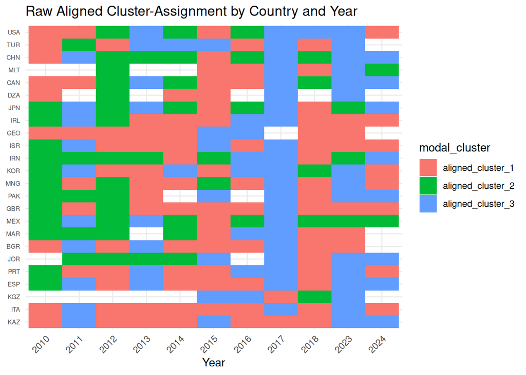

```r
shifted_cluster_3 <- final_shifted_clustering$labels_df %>%
  filter(cluster == 3)

plot_raw_cluster_membership_heatmap(raw_cluster_tally_shifted_y %>%
                                      filter(country_code %in% shifted_cluster_3$country_code))
```

We can see that overall, members within the clustering group have a lot of shift for where they assign, year to year. Though there are some exceptions, with countries that remain relatively stable with limited membership shifts. **An important note, these aligned clusters do not reflect the final clusters assigned from the consensus matrix, they are generated from the raw resampling data aligned to the anchor year (year with the most complete data) to get a sense of the a countries movement in a discrete simplified format.**

We’ll now add these clustering results back to the `*_pass` dataset partitions and conduct further analysis.

```r
co_cy_pass <- co_cy_pass %>%
  left_join(final_calendar_clustering$labels_df,
            by = c("COUNTRY_CODE" = "country_code",
                   "COUNTRY" = "country_name")) %>%
  mutate(kmeans_cluster = cluster) %>%
  mutate(kmeans_cluster = paste0("CY", kmeans_cluster)) %>%
  select(-cluster)

co_sy_pass <- co_sy_pass %>%
  left_join(final_shifted_clustering$labels_df,
            by = c("COUNTRY_CODE" = "country_code",
                   "COUNTRY" = "country_name")) %>%
  mutate(kmeans_cluster = cluster) %>%
  mutate(kmeans_cluster = paste0("SY", kmeans_cluster)) %>%
  select(-cluster)
```

### 5.6 Generation of Cluster Distributions

GAM fits were generated for each cluster using all burden data in each cluster (`inf_all_burden`). Similarly, country GAM fits were also generated for all passing country data (using `inf_all_burden`).

Clusters from the shifted year partition were initially tagged with “SY” and clusters from the calendar year partition were tagged with “CY”. To consolidate labeling, the cluster partitions were combined and labeled A-E. Cluster mapping is as follows:

A = SY1, B = SY3, C = SY2, D = CY2, E = CY1.

`inf_all_burden` is non-negative and right-skewed, with exact zeros possible in off-season weeks, so each GAM used a Tweedie family (compound Poisson-Gamma, log link by default) rather than the default Gaussian, with REML smoothness selection; 95% confidence intervals were built on the log (link) scale and back-transformed, so they stay non-negative, then renormalized by the same constant as the fitted curve. The per-cluster summary curves are hierarchical GAMs: a shared cyclic smooth over the fitting week is fit alongside a country-specific factor-smooth term (`bs = "fs"`) that lets each country’s curve deviate from the cluster-level average, following the “global smoother plus group-level smoothers” approach described in Pedersen et al. (Pedersen et al. 2019). The reported fit/CI for each cluster excludes the country-specific term, so it reflects the shared seasonal pattern, but the shared smooth’s own uncertainty is now estimated jointly with the country-level deviations. Properly widening the CI to reflect between-country variability in epidemic timing, rather than treating all country-weeks within a cluster as independent, identically-distributed observations.

```r
# Compute weekly mean of clusters per year, and week

# Combine data with clustering
co_comb_pass <- bind_rows(co_sy_pass, co_cy_pass) %>%
  mutate(combined_cluster = case_when(kmeans_cluster == "SY1" ~ "A",
                                      kmeans_cluster == "SY2" ~ "C",
                                      kmeans_cluster == "SY3" ~ "B",
                                      kmeans_cluster == "CY2" ~ "D",
                                      kmeans_cluster == "CY1" ~ "E"),
         LABEL = paste0(combined_cluster, "-", COUNTRY))

### Week to shifted_week conversion (built first; needed to relabel the GAM axis below)
shifted_wks <- co_sy %>% select(COUNTRY, YEAR, WEEK, shifted_week) %>% filter(COUNTRY == "Albania" & YEAR == 2017) %>%
  select(WEEK, shifted_week)

# Cluster GAM estimations
# A/B/C (SY-derived) clusters must be fit on shifted_week, not calendar WEEK, or a
# single epidemic spanning the Dec/Jan boundary gets split across the week axis
# (see Section 2); bs = "cc" enforces a smooth cyclic join at week 52 -> week 1.
# inf_all_burden is non-negative, right-skewed, and can be exactly 0 in the
# off-season, which rules out Gamma (requires y > 0); tw() (Tweedie, log link
# by default) handles the zeros while still letting variance scale with the
# mean. method = "REML" gives more reliable smoothness selection and
# better-calibrated CIs than the gam() default (GCV).
# A country-specific factor-smooth (bs="fs") is added so each country can
# deviate from the shared cluster smooth; this absorbs between-country
# correlation into its own term instead of letting it silently narrow the
# cluster-level CI (Pedersen et al. 2019 "GS" hierarchical GAM structure).
inf_cluster_gam <- co_comb_pass %>%
  filter(WEEK < 53) %>%
  mutate(fit_week = if_else(combined_cluster %in% c("A", "B", "C"), shifted_week, WEEK),
         COUNTRY_CODE = factor(COUNTRY_CODE)) %>%
  group_by(combined_cluster, kmeans_cluster) %>%
  nest() %>%
  mutate(inf_clust_mdl = purrr::map(data, ~ gam(inf_all_burden ~ s(fit_week, bs = "cc", k = 30) +
                                                s(fit_week, COUNTRY_CODE, bs = "fs", k = 8,
                                                  xt = list(bs = "cc"), m = 1),
                                                family = tw(),
                                                method = "REML",
                                                knots = list(fit_week = c(0.5, 52.5)),
                                                na.action=na.omit, data = .x)),
         # predict the shared cluster-level curve only (exclude the country-specific
         # factor-smooth) on the link (log) scale so the back-transformed CI can't go negative
         inf_clust_pred = purrr::map2(inf_clust_mdl, data, ~ predict(
           .x,
           newdata = data.frame(fit_week = 1:52,
                                 COUNTRY_CODE = factor(levels(.y$COUNTRY_CODE)[1], levels = levels(.y$COUNTRY_CODE))),
           type = "link", se.fit = TRUE,
           exclude = "s(fit_week,COUNTRY_CODE)"))) %>%
  mutate(inf_clust_fit = purrr::map(inf_clust_pred, ~ exp(.x$fit)),
         inf_clust_lwr = purrr::map(inf_clust_pred, ~ exp(.x$fit - 1.96 * .x$se.fit)),
         inf_clust_upr = purrr::map(inf_clust_pred, ~ exp(.x$fit + 1.96 * .x$se.fit)),
         inf_clust_se = purrr::map(inf_clust_pred, ~ .x$se.fit))

# Basis-dimension (k) adequacy check: an edf near k' signals either the
# shared cyclic smooth or a country-level factor-smooth is too rigid to
# capture its curve shape; re-check after fitting since adding the
# country-specific term changes both smooths' effective degrees of freedom.
cluster_gam_k_check <- inf_cluster_gam %>%
  mutate(k_check = purrr::map(inf_clust_mdl, ~ as.data.frame(mgcv::k.check(.x)))) %>%
  dplyr::select(combined_cluster, kmeans_cluster, k_check) %>%
  unnest(k_check)

cluster_gam_k_check %>%
  kable(format = "html", digits = 3) %>%
  kable_styling(bootstrap_options = c("striped", "hover", "condensed"), full_width = FALSE) %>%
  scroll_box(height = "400px")
```

| combined_cluster | kmeans_cluster | k’ | edf | k-index | p-value |
| --- | --- | --- | --- | --- | --- |
| A | SY1 | 28 | 17.988 | 0.851 | 0.262 |
| A | SY1 | 238 | 210.573 | 0.851 | 0.270 |
| B | SY3 | 28 | 14.729 | 0.921 | 0.885 |
| B | SY3 | 168 | 146.661 | 0.921 | 0.850 |
| C | SY2 | 28 | 6.631 | 0.966 | 0.882 |
| C | SY2 | 154 | 135.796 | 0.966 | 0.880 |
| E | CY1 | 28 | 10.810 | 0.892 | 0.278 |
| E | CY1 | 84 | 72.359 | 0.892 | 0.258 |
| D | CY2 | 28 | 8.780 | 0.941 | 0.322 |
| D | CY2 | 133 | 118.367 | 0.941 | 0.320 |

```r
inf_cluster_gam_v <- dplyr::select(inf_cluster_gam, -data, -inf_clust_mdl, -inf_clust_pred) %>%
  unnest() %>%
  mutate(fit_week = seq_along(inf_clust_fit)) %>%
  # normalize fit/lwr/upr by the same constant so the CI still brackets the probability curve
  mutate(inf_clust_fit_new = inf_clust_fit / sum(inf_clust_fit),
         inf_clust_lwr_new = inf_clust_lwr / sum(inf_clust_fit),
         inf_clust_upr_new = inf_clust_upr / sum(inf_clust_fit)) %>%
  # restore a calendar WEEK label for display/export (fit_week IS the calendar week for D/E)
  left_join(shifted_wks, by = c("fit_week" = "shifted_week")) %>%
  mutate(WEEK = if_else(combined_cluster %in% c("A", "B", "C"), WEEK, fit_week))
```

A basis-dimension adequacy check (`mgcv::k.check()`) was reviewed after refitting, since the added country-specific factor-smooth introduces its own `k'`/edf alongside the shared cyclic smooth’s; both were checked for under-fitting.

```r
### Summary of GAM distributions, by cluster, which will help me determine which weeks the bulk of activity occurs during
gam_summaries <- inf_cluster_gam_v %>%
  group_by(combined_cluster) %>%
  summarise(sumof = sum(inf_clust_fit_new),
            meanof = mean(inf_clust_fit_new),
            q05 = quantile(inf_clust_fit_new, 0.05),
            q25 = quantile(inf_clust_fit_new, 0.25),
            q50 = quantile(inf_clust_fit_new, 0.50),
            q75 = quantile(inf_clust_fit_new, 0.75),
            q95 = quantile(inf_clust_fit_new, 0.95))

# Convert 1D arrays to straight vectors to avoid downstream errors
inf_cluster_gam_v <- inf_cluster_gam_v %>%
  mutate(inf_clust_fit = as.numeric(drop(inf_clust_fit)),
         inf_clust_se = as.numeric(drop(inf_clust_se)),
         inf_clust_lwr = as.numeric(drop(inf_clust_lwr)),
         inf_clust_upr = as.numeric(drop(inf_clust_upr)),
         inf_clust_fit_new = as.numeric(drop(inf_clust_fit_new)),
         inf_clust_lwr_new = as.numeric(drop(inf_clust_lwr_new)),
         inf_clust_upr_new = as.numeric(drop(inf_clust_upr_new)))

### merge summaries with GAM fitted values by week
inf_cluster_gam_distn <- left_join(inf_cluster_gam_v, gam_summaries, by = c("combined_cluster")) %>%
  mutate(respective_week = fit_week) %>%
  arrange(combined_cluster, respective_week) %>%
  group_by(combined_cluster) %>%
   mutate(
    above_med = !is.na(inf_clust_fit_new) & inf_clust_fit_new >= q50,
    below_med = !is.na(inf_clust_fit_new) & inf_clust_fit_new < q50,
    # new group id each time the logical changes (TRUE<->FALSE) or starts;
    # grouped by combined_cluster so lag()/cumsum() reset at each cluster boundary
    # rather than relying solely on the compound group_by() key further below
    above_grp = cumsum(coalesce(above_med != lag(above_med), above_med)),
    below_grp = cumsum(coalesce(below_med != lag(below_med), below_med))
  ) %>%
  ungroup() %>%
  group_by(combined_cluster, above_grp) %>%
  mutate(above_streak = if_else(above_med, row_number(), 0L),
         above_streak_max = max(above_streak)) %>%
  ungroup() %>%
  # Length of each below-median run (0 for above-median blocks); used below to
  # decide which below-median dips are brief enough to bridge over.
  group_by(combined_cluster, below_grp) %>%
  mutate(below_run_length = if_else(below_med, as.integer(n()), 0L)) %>%
  ungroup() %>%
  # Bridge brief (<3-week) below-median dips into the surrounding above-median
  # run -- a short-lived dip shouldn't be treated as ending the season; only a
  # genuinely sustained decline (>= 3 weeks below median) counts as a real break.
  mutate(bridged_above = above_med | (below_med & below_run_length < 3)) %>%
  group_by(combined_cluster) %>%
  mutate(bridged_grp = cumsum(coalesce(bridged_above != lag(bridged_above), bridged_above))) %>%
  ungroup() %>%
  group_by(combined_cluster, bridged_grp) %>%
  mutate(bridged_streak = if_else(bridged_above, row_number(), 0L),
         bridged_streak_max = max(bridged_streak)) %>%
  ungroup() %>%
  # The epidemic season's start is the first week of the single longest run of
  # consecutive weeks above the median, after bridging brief dips (must be
  # >= 3 weeks to count as a detectable season). The season's end is the
  # first week of the immediately-following run of weeks below the median
  # (per the WHO-style definition: "the end of influenza epidemics as the
  # first week in which the burden remained below the median for >= 3
  # weeks"). Because bridging already merges any below-median run
  # <3 weeks into the surrounding above-median run, the run immediately
  # following the chosen longest run is guaranteed (by construction) to
  # already be >= 3 weeks long -- so no separate length check is needed here.
  # If no run reaches 3 weeks, there is no detectable season (start/end = NA).
  # Ties for longest run are broken by taking the chronologically first run.
  #
  # CYCLIC WRAP for "end": the GAM's cyclic spline makes week 52 and week 1
  # part of one continuous annual curve, but run-detection above is linear
  # (lag()/cumsum() don't know the array loops). If the chosen season reaches
  # the array's very last row, there is no "following" group within this one
  # year's window -- but the decline may genuinely continue into the array's
  # own first group (week 1 picks back up right where week 52 left off), so
  # wrap around to group 0 in that case. Two situations are deliberately left
  # as NA rather than risk an incorrect wrapped answer: (1) the season IS
  # group 0 itself with no later group at all (truly no decline all year),
  # and (2) group 0 is itself an above-median run (the season likely spans
  # the array boundary rather than ending there -- not handled by this fix).
  group_by(combined_cluster) %>%
  mutate(season_max_len = suppressWarnings(max(bridged_streak_max[bridged_above & bridged_streak_max >= 3], na.rm = TRUE)),
         is_candidate_season_grp = bridged_above & bridged_streak_max == season_max_len & is.finite(season_max_len),
         season_run_id  = ifelse(any(is_candidate_season_grp), suppressWarnings(min(bridged_grp[is_candidate_season_grp])), NA_integer_),
         is_season_week = !is.na(season_run_id) & bridged_grp == season_run_id,
         respective_epidemic_start = ifelse(any(is_season_week), suppressWarnings(min(respective_week[is_season_week])), NA_integer_),
         group0_is_above = any(bridged_grp == 0 & bridged_above),
         has_direct_next_grp = !is.na(season_run_id) & any(bridged_grp == (season_run_id + 1)),
         end_search_grp = case_when(
           is.na(season_run_id) ~ NA_integer_,
           has_direct_next_grp ~ season_run_id + 1L,
           season_run_id == 0L ~ NA_integer_,
           !group0_is_above ~ 0L,
           TRUE ~ NA_integer_
         ),
         is_end_week = !is.na(end_search_grp) & bridged_grp == end_search_grp,
         respective_epidemic_end = ifelse(any(is_end_week), suppressWarnings(min(respective_week[is_end_week])), NA_integer_)) %>%
  ungroup() %>%
  select(-season_max_len, -is_candidate_season_grp, -season_run_id, -group0_is_above, -has_direct_next_grp, -end_search_grp, -is_end_week)

# min(x, na.rm = TRUE) on an all-NA vector returns Inf (with a warning), not NA --
# this guards the "no detectable season" case (every row NA) so it stays NA
# instead of silently becoming Inf downstream (e.g., in epidemic_start_month).
safe_min_na <- function(x) if (all(is.na(x))) NA_integer_ else min(x, na.rm = TRUE)

epidemic_thresholds <- inf_cluster_gam_distn %>%
  group_by(combined_cluster) %>%
  summarise(respective_epidemic_start = safe_min_na(respective_epidemic_start),
            respective_epidemic_end = safe_min_na(respective_epidemic_end),
            # % of the cluster's total annual burden (inf_clust_fit_new sums to 1 across
            # all 52 weeks) falling within the epidemic window; wraps across the
            # week-52/week-1 boundary if the window itself does (e.g. start=48, end=6).
            epidemic_burden_pct = if_else(
              is.na(respective_epidemic_start) | is.na(respective_epidemic_end),
              NA_real_,
              100 * sum(inf_clust_fit_new[if (respective_epidemic_start <= respective_epidemic_end) {
                respective_week >= respective_epidemic_start & respective_week <= respective_epidemic_end
              } else {
                respective_week >= respective_epidemic_start | respective_week <= respective_epidemic_end
              }]))) %>%
  left_join(shifted_wks, c("respective_epidemic_start" = "shifted_week")) %>% rename(calendar_epidemic_start = WEEK) %>%
  left_join(shifted_wks, c("respective_epidemic_end" = "shifted_week"))  %>% rename(calendar_epidemic_end = WEEK) %>%
  mutate(epidemic_start = case_when(combined_cluster %in% c("A", "B", "C") ~ calendar_epidemic_start,
                                    combined_cluster %in% c("D", "E") ~ respective_epidemic_start),
         epidemic_start_month = ceiling(epidemic_start / 4.348),
         epidemic_end   = case_when(combined_cluster %in% c("A", "B", "C") ~ calendar_epidemic_end,
                                    combined_cluster %in% c("D", "E") ~ respective_epidemic_end),
         epidemic_end_month = ceiling(epidemic_end / 4.348),
         epidemic_burden_pct = round(epidemic_burden_pct, 1)) %>%
  select(combined_cluster, epidemic_start, epidemic_start_month, epidemic_end, epidemic_end_month, epidemic_burden_pct)
kable(epidemic_thresholds, format = "html",
      col.names = c("Epidemic zone",
                    "Week",
                    "Month",
                    "Week",
                    "Month",
                    "% of annual burden")) %>%
  add_header_above(c(" " = 1, "Epidemic start" = 2, "Epidemic end" = 2, " " = 1)) %>%
  kable_styling(bootstrap_options = c("striped", "hover", "condensed"),
                    full_width = FALSE)
```

| Epidemic zone | Epidemic start Week | Epidemic start Month | Epidemic end Week | Epidemic end Month | % of annual burden |
| --- | --- | --- | --- | --- | --- |
| A | 47 | 11 | 21 | 5 | 98.4 |
| B | 45 | 11 | 19 | 5 | 96.5 |
| C | 39 | 9 | 13 | 3 | 56.5 |
| D | 22 | 6 | 45 | 11 | 55.3 |
| E | 18 | 5 | 44 | 11 | 82.4 |

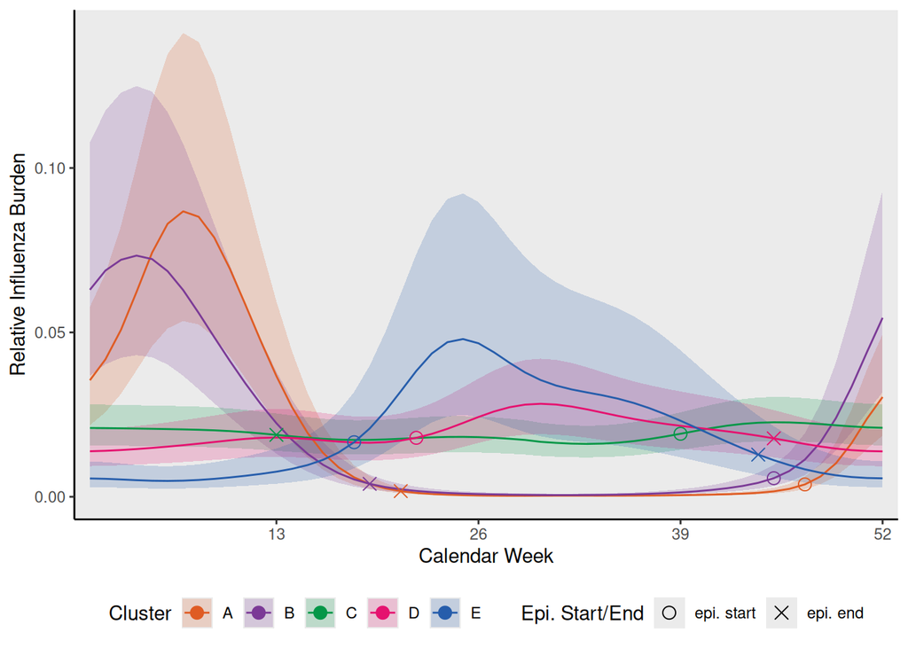

```r
inf_cluster_gam_v <- inf_cluster_gam_v %>%
  left_join(epidemic_thresholds %>%
              select(combined_cluster, epidemic_start, epidemic_end),
            by = c("combined_cluster")) %>%
  mutate(x_start_end = case_when(WEEK == epidemic_start |
                                   WEEK == epidemic_end ~ WEEK,
                                 .default = NA),
         y_start_end = case_when(WEEK == epidemic_start |
                                   WEEK == epidemic_end ~ inf_clust_fit_new,
                                 .default = NA),
         start_end = case_when(WEEK == epidemic_start ~ "epi. start",
                               WEEK == epidemic_end ~ "epi. end",
                               .default = NA)) %>%
  select(-epidemic_start, -epidemic_end)

inf_cluster_gam_plot <- ggplot(inf_cluster_gam_v, aes(x = WEEK, y = inf_clust_fit_new, group = combined_cluster)) +
  geom_ribbon(alpha = 0.2, aes(ymin = inf_clust_lwr_new,
                               ymax = inf_clust_upr_new, fill = combined_cluster)) +
  geom_line(aes(color = combined_cluster)) +
  geom_point(aes(color = combined_cluster, x = x_start_end, y = y_start_end, shape = start_end), size = 3) +
  scale_color_manual(values = c("A" = "#DF5C24",
                                "B" = "#7B3A96",
                                "C" = "#059748",
                                "D" = "#E5126F",
                                "E" = "#265DAB"),
                     breaks = c("A","B","C","D","E")) +
  scale_fill_manual(values = c("A" = "#DF5C24",
                               "B" = "#7B3A96",
                               "C" = "#059748",
                               "D" = "#E5126F",
                               "E" = "#265DAB"),
                    breaks = c("A","B","C","D","E")) +
  scale_shape_manual(
    limits = c("epi. start", "epi. end"),
    values = c("epi. start" = 1, "epi. end" = 4),
    na.translate = FALSE
  ) +
  ylab("Relative Influenza Burden") +
  xlab("Calendar Week") +
  scale_x_continuous(expand = c(0,0), breaks = c(13,26,39,52), limits = c(0,53)) +
  guides(color=guide_legend(title="Cluster", nrow = 1, order = 1),
         fill=guide_legend(title="Cluster", nrow = 1, order = 1),
         shape=guide_legend(title="Epi. Start/End", nrow = 1, order = 2)) +
  #ggtitle("GAM Fits For Clusters") +
  theme(panel.grid.major = element_blank(), panel.grid.minor = element_blank(),
        axis.line = element_line(colour = "black"),
        legend.position="bottom")

ggsave("plots/inf_cluster_gam_plot.pdf", inf_cluster_gam_plot, units = "in", height = 6, width = 9)

inf_cluster_gam_plot
```

```r
# Country GAM estimations (same fit_week / cyclic-spline / Tweedie-REML logic as the cluster GAM above)
inf_co_gam <- co_comb_pass %>%
  filter(WEEK < 53) %>%
  mutate(fit_week = if_else(combined_cluster %in% c("A", "B", "C"), shifted_week, WEEK)) %>%
  group_by(combined_cluster, COUNTRY, COUNTRY_CODE, LABEL) %>%
  nest() %>%
  mutate(inf_clust_mdl = purrr::map(data, ~ gam(inf_all_burden ~ s(fit_week, bs = "cc", k = 30),
                                                family = tw(),
                                                method = "REML",
                                                knots = list(fit_week = c(0.5, 52.5)),
                                                na.action=na.omit, data = .x)),
         inf_clust_pred = purrr::map(inf_clust_mdl, ~ predict(.x, data.frame(fit_week = 1:52), type = "link", se.fit = TRUE))) %>%
  mutate(inf_clust_fit = purrr::map(inf_clust_pred, ~ exp(.x$fit)),
         inf_clust_lwr = purrr::map(inf_clust_pred, ~ exp(.x$fit - 1.96 * .x$se.fit)),
         inf_clust_upr = purrr::map(inf_clust_pred, ~ exp(.x$fit + 1.96 * .x$se.fit)),
         inf_clust_se = purrr::map(inf_clust_pred, ~ .x$se.fit))

inf_co_gam_v <- dplyr::select(inf_co_gam, -data, -inf_clust_mdl, -inf_clust_pred) %>%
  unnest() %>%
  mutate(fit_week = seq_along(inf_clust_fit)) %>%
  mutate(inf_clust_fit_new = inf_clust_fit / sum(inf_clust_fit),
         inf_clust_lwr_new = inf_clust_lwr / sum(inf_clust_fit),
         inf_clust_upr_new = inf_clust_upr / sum(inf_clust_fit)) %>%
  left_join(shifted_wks, by = c("fit_week" = "shifted_week")) %>%
  mutate(WEEK = if_else(combined_cluster %in% c("A", "B", "C"), WEEK, fit_week))

inf_co_gam_plot <- ggplot(inf_co_gam_v, aes(x = WEEK, y = inf_clust_fit_new, group = combined_cluster)) +
  geom_point(data = co_comb_pass %>% filter(WEEK < 53), aes(x = WEEK, y = inf_all_burden), alpha = 0.1) +
  geom_ribbon(alpha = 0.5, aes(ymin = inf_clust_lwr_new,
                               ymax = inf_clust_upr_new, fill = combined_cluster)) +
  geom_line(aes(color = combined_cluster)) +
  scale_color_manual(values = c("A" = "#DF5C24",
                                "B" = "#7B3A96",
                                "C" = "#059748",
                                "D" = "#E5126F",
                                "E" = "#265DAB"),
                     breaks = c("A","B","C","D","E")) +
  scale_fill_manual(values = c("A" = "#DF5C24",
                               "B" = "#7B3A96",
                               "C" = "#059748",
                               "D" = "#E5126F",
                               "E" = "#265DAB"),
                    breaks = c("A","B","C","D","E")) +
  ylab("GAM Fit Value") +
  xlab("week") +
  scale_x_continuous(expand = c(0,0), breaks = c(13,26,39,52), limits = c(0,53)) +
  guides(color=guide_legend(title="Cluster", nrow = 1),
         fill=guide_legend(title="Cluster", nrow = 1)) +
  facet_wrap_paginate(~LABEL, ncol = 4, nrow = 5, page = 1) +
  ggtitle("GAM Fits For Countries") +
  theme(panel.grid.major = element_blank(), panel.grid.minor = element_blank(),
        axis.line = element_line(colour = "black"),
        legend.position="bottom")

gam_num_pg <- n_pages(inf_co_gam_plot)

pdf("plots/country_weekly_burden_gams.pdf", paper = "USr", width = 9)
for(i in 1:gam_num_pg) {
  print(
    ggplot(inf_co_gam_v, aes(x = WEEK, y = inf_clust_fit_new, group = combined_cluster)) +
      geom_point(data = co_comb_pass %>% filter(WEEK < 53), aes(x = WEEK, y = inf_all_burden), alpha = 0.1) +
      geom_ribbon(alpha = 0.5, aes(ymin = inf_clust_lwr_new,
                                   ymax = inf_clust_upr_new, fill = combined_cluster)) +
      geom_line(aes(color = combined_cluster)) +
      scale_color_manual(values = c("A" = "#DF5C24",
                                    "B" = "#7B3A96",
                                    "C" = "#059748",
                                    "D" = "#E5126F",
                                    "E" = "#265DAB"),
                         breaks = c("A","B","C","D","E")) +
      scale_fill_manual(values = c("A" = "#DF5C24",
                                   "B" = "#7B3A96",
                                   "C" = "#059748",
                                   "D" = "#E5126F",
                                   "E" = "#265DAB"),
                        breaks = c("A","B","C","D","E")) +
      ylab("GAM Fit Value") +
      xlab("week") +
      scale_x_continuous(expand = c(0,0), breaks = c(13,26,39,52), limits = c(0,53)) +
      guides(color=guide_legend(title="Cluster", nrow = 1),
             fill=guide_legend(title="Cluster", nrow = 1)) +
      facet_wrap_paginate(~LABEL, ncol = 4, nrow = 5, page = i) +
      ggtitle("GAM Fits For Countries") +
      theme(panel.grid.major = element_blank(), panel.grid.minor = element_blank(),
            axis.line = element_line(colour = "black"),
            legend.position="bottom")
  )
}
invisible(dev.off())
```

```r
# Convert 1D arrays to numeric to avoid downstream complication
inf_co_gam_v <- inf_co_gam_v %>%
  mutate(inf_clust_fit = as.numeric(drop(inf_clust_fit)),
         inf_clust_se = as.numeric(drop(inf_clust_se)),
         inf_clust_lwr = as.numeric(drop(inf_clust_lwr)),
         inf_clust_upr = as.numeric(drop(inf_clust_upr)),
         inf_clust_fit_new = as.numeric(drop(inf_clust_fit_new)),
         inf_clust_lwr_new = as.numeric(drop(inf_clust_lwr_new)),
         inf_clust_upr_new = as.numeric(drop(inf_clust_upr_new)))

### Summary of GAM distributions, by country, which will help me determine which weeks the bulk of activity occurs during
co_gam_summaries <- inf_co_gam_v %>%
  group_by(COUNTRY) %>%
  summarise(sumof = sum(inf_clust_fit_new),
            meanof = mean(inf_clust_fit_new),
            q05 = quantile(inf_clust_fit_new, 0.05),
            q25 = quantile(inf_clust_fit_new, 0.25),
            q50 = quantile(inf_clust_fit_new, 0.50),
            q75 = quantile(inf_clust_fit_new, 0.75),
            q95 = quantile(inf_clust_fit_new, 0.95))


### merge summaries with GAM fitted values by week
inf_co_gam_distn <- left_join(inf_co_gam_v, co_gam_summaries, by = c("COUNTRY")) %>%
  mutate(respective_week = fit_week) %>%
  arrange(COUNTRY, respective_week) %>%
  group_by(COUNTRY) %>%
   mutate(
    above_med = !is.na(inf_clust_fit_new) & inf_clust_fit_new >= q50,
    below_med = !is.na(inf_clust_fit_new) & inf_clust_fit_new < q50,
    # new group id each time the logical changes (TRUE<->FALSE) or starts;
    # grouped by COUNTRY so lag()/cumsum() reset at each country boundary
    # rather than relying solely on the compound group_by() key further below
    above_grp = cumsum(coalesce(above_med != lag(above_med), above_med)),
    below_grp = cumsum(coalesce(below_med != lag(below_med), below_med))
  ) %>%
  ungroup() %>%
  group_by(COUNTRY, above_grp) %>%
  mutate(above_streak = if_else(above_med, row_number(), 0L),
         above_streak_max = max(above_streak)) %>%
  ungroup() %>%
  # Length of each below-median run (0 for above-median blocks); used below to
  # decide which below-median dips are brief enough to bridge over.
  group_by(COUNTRY, below_grp) %>%
  mutate(below_run_length = if_else(below_med, as.integer(n()), 0L)) %>%
  ungroup() %>%
  # Bridge brief (<3-week) below-median dips into the surrounding above-median
  # run -- a short-lived dip shouldn't be treated as ending the season; only a
  # genuinely SUSTAINED decline (>= 3 weeks below median) counts as a real break.
  mutate(bridged_above = above_med | (below_med & below_run_length < 3)) %>%
  group_by(COUNTRY) %>%
  mutate(bridged_grp = cumsum(coalesce(bridged_above != lag(bridged_above), bridged_above))) %>%
  ungroup() %>%
  group_by(COUNTRY, bridged_grp) %>%
  mutate(bridged_streak = if_else(bridged_above, row_number(), 0L),
         bridged_streak_max = max(bridged_streak)) %>%
  ungroup() %>%
  # The epidemic season's START is the first week of the SINGLE LONGEST run of
  # consecutive weeks above the median, after bridging brief dips (must be
  # >= 3 weeks to count as a detectable season). The season's END is the
  # first week of the immediately-following run of weeks below the median
  # (per the WHO-style definition: "the end of influenza epidemics as the
  # first week in which the burden remained below the median for >= 3
  # weeks"). Because bridging already merges any below-median run shorter
  # than 3 weeks into the surrounding above-median run, the run immediately
  # following the chosen longest run is guaranteed (by construction) to
  # already be >= 3 weeks long -- so no separate length check is needed here.
  # If no run reaches 3 weeks, there is no detectable season (start/end = NA).
  # Ties for longest run are broken by taking the chronologically first run.
  #
   # CYCLIC WRAP for "end": the GAM's cyclic spline makes week 52 and week 1
  # part of one continuous annual curve, but run-detection above is linear
  # (lag()/cumsum() don't know the array loops). If the chosen season reaches
  # the array's very last row, there is no "following" group within this one
  # year's window -- but the decline may genuinely continue into the array's
  # OWN first group (week 1 picks back up right where week 52 left off), so
  # wrap around to group 0 in that case. Two situations are deliberately left
  # as NA rather than risk an incorrect wrapped answer: (1) the season IS
  # group 0 itself with no later group at all (truly no decline all year),
  # and (2) group 0 is itself an above-median run (the season likely spans
  # the array boundary rather than ending there -- not handled by this fix).
  group_by(COUNTRY) %>%
  mutate(season_max_len = suppressWarnings(max(bridged_streak_max[bridged_above & bridged_streak_max >= 3], na.rm = TRUE)),
         is_candidate_season_grp = bridged_above & bridged_streak_max == season_max_len & is.finite(season_max_len),
         season_run_id  = ifelse(any(is_candidate_season_grp), suppressWarnings(min(bridged_grp[is_candidate_season_grp])), NA_integer_),
         is_season_week = !is.na(season_run_id) & bridged_grp == season_run_id,
         respective_epidemic_start = ifelse(any(is_season_week), suppressWarnings(min(respective_week[is_season_week])), NA_integer_),
         group0_is_above = any(bridged_grp == 0 & bridged_above),
         has_direct_next_grp = !is.na(season_run_id) & any(bridged_grp == (season_run_id + 1)),
         end_search_grp = case_when(
           is.na(season_run_id) ~ NA_integer_,
           has_direct_next_grp ~ season_run_id + 1L,
           season_run_id == 0L ~ NA_integer_,
           !group0_is_above ~ 0L,
           TRUE ~ NA_integer_
         ),
         is_end_week = !is.na(end_search_grp) & bridged_grp == end_search_grp,
         respective_epidemic_end = ifelse(any(is_end_week), suppressWarnings(min(respective_week[is_end_week])), NA_integer_)) %>%
  ungroup() %>%
  select(-season_max_len, -is_candidate_season_grp, -season_run_id, -is_season_week, -group0_is_above, -has_direct_next_grp, -end_search_grp, -is_end_week)


### epidemic starts and ends for each country
epidemic_thresholds_co <- inf_co_gam_distn %>%
  group_by(COUNTRY, combined_cluster) %>%

  summarise(respective_epidemic_start = safe_min_na(respective_epidemic_start),
            respective_epidemic_end = safe_min_na(respective_epidemic_end)) %>%
  left_join(shifted_wks, c("respective_epidemic_start" = "shifted_week")) %>% rename(calendar_epidemic_start = WEEK) %>%
  left_join(shifted_wks, c("respective_epidemic_end" = "shifted_week"))  %>% rename(calendar_epidemic_end = WEEK) %>%
  mutate(epidemic_start = case_when(combined_cluster %in% c("A", "B", "C") ~ calendar_epidemic_start,
                                    combined_cluster %in% c("D", "E") ~ respective_epidemic_start),
         epidemic_start_month = ceiling(epidemic_start / 4.348),
         epidemic_end   = case_when(combined_cluster %in% c("A", "B", "C") ~ calendar_epidemic_end,
                                    combined_cluster %in% c("D", "E") ~ respective_epidemic_end),
         epidemic_end_month = ceiling(epidemic_end / 4.348)) %>%
  select(COUNTRY, combined_cluster, epidemic_start, epidemic_start_month, epidemic_end, epidemic_end_month)
```

```r
# Cluster Mean Results
comb_cluster_yr_mean <- co_comb_pass %>%
  filter(WEEK < 53) %>%
  group_by(combined_cluster, YEAR, WEEK) %>%
  summarise(yearly_mean_burden = mean(inf_all_burden, na.rm = TRUE),
            conf_min = t.test(inf_all_burden)$conf.int[1],
            conf_max = t.test(inf_all_burden)$conf.int[2])

comb_cluster_wk_mean <- co_comb_pass %>%
  filter(WEEK < 53) %>%
  group_by(combined_cluster, WEEK) %>%
  summarise(weekly_mean_burden = mean(inf_all_burden, na.rm = TRUE),
            conf_min = t.test(inf_all_burden)$conf.int[1],
            conf_max = t.test(inf_all_burden)$conf.int[2])

comb_co_wk_mean <- co_comb_pass %>%
  filter(WEEK < 53) %>%
  group_by(combined_cluster, WEEK, LABEL, COUNTRY) %>%
  summarise(weekly_mean_burden = mean(inf_all_burden, na.rm = TRUE),
            conf_min = t.test(inf_all_burden)$conf.int[1],
            conf_max = t.test(inf_all_burden)$conf.int[2])

cl_res_by_yr <- ggplot(comb_cluster_yr_mean, aes(x = WEEK, y = yearly_mean_burden)) +
  geom_ribbon(alpha = 0.2, aes(ymin=conf_min, ymax=conf_max, fill = combined_cluster)) +
  geom_line(aes(color = combined_cluster)) +
  scale_color_manual(values = c("A" = "#DF5C24",
                                "B" = "#7B3A96",
                                "C" = "#059748",
                                "D" = "#E5126F",
                                "E" = "#265DAB"),
                     breaks = c("A","B","C","D","E")) +
  scale_fill_manual(values = c("A" = "#DF5C24",
                               "B" = "#7B3A96",
                               "C" = "#059748",
                               "D" = "#E5126F",
                               "E" = "#265DAB"),
                    breaks = c("A","B","C","D","E")) +
  scale_x_continuous(expand = c(0,0), breaks = c(13,26,39,52), limits = c(0,53)) +
  facet_wrap(~YEAR) +
  ylab("Weekly Mean Burden") +
  xlab("week") +
  ggtitle("Cluster Weekly Means By Year With CI") +
  guides(color=guide_legend(title="Cluster", nrow = 1),
         fill=guide_legend(title="Cluster", nrow = 1)) +
  theme(panel.grid.major = element_blank(), panel.grid.minor = element_blank(),
        axis.line = element_line(colour = "black"),
            legend.position="bottom")

ggsave("plots/cluster_mean_by_yr.pdf", cl_res_by_yr, units = "in", height = 6, width = 9)

cl_res_by_wk <- ggplot(comb_cluster_wk_mean, aes(x = WEEK, y = weekly_mean_burden)) +
  geom_ribbon(alpha = 0.2, aes(ymin=conf_min, ymax=conf_max, fill = combined_cluster)) +
  geom_line(aes(color = combined_cluster)) +
  scale_color_manual(values = c("A" = "#DF5C24",
                                "B" = "#7B3A96",
                                "C" = "#059748",
                                "D" = "#E5126F",
                                "E" = "#265DAB"),
                     breaks = c("A","B","C","D","E")) +
  scale_fill_manual(values = c("A" = "#DF5C24",
                               "B" = "#7B3A96",
                               "C" = "#059748",
                               "D" = "#E5126F",
                               "E" = "#265DAB"),
                    breaks = c("A","B","C","D","E")) +
  scale_x_continuous(expand = c(0,0), breaks = c(13,26,39,52), limits = c(0,53)) +
  ylab("Weekly Mean Burden") +
  xlab("week") +
  ggtitle("Cluster Weekly Means With CI") +
  guides(color=guide_legend(title="Cluster", nrow = 1),
         fill=guide_legend(title="Cluster", nrow = 1)) +
  theme(panel.grid.major = element_blank(), panel.grid.minor = element_blank(),
        axis.line = element_line(colour = "black"),
        legend.position="bottom")

ggsave("plots/cluster_mean_by_wk.pdf", cl_res_by_wk, units = "in", height = 6, width = 9)

inf_co_mean_plot <- ggplot(comb_co_wk_mean, aes(x = WEEK, y = weekly_mean_burden, group = combined_cluster)) +
  geom_point(data = co_comb_pass %>% filter(WEEK < 53), aes(x = WEEK, y = inf_all_burden), alpha = 0.1) +
  geom_ribbon(alpha = 0.5, aes(ymin = conf_min,
                               ymax = conf_max, fill = combined_cluster)) +
  geom_line(aes(color = combined_cluster)) +
  scale_color_manual(values = c("A" = "#DF5C24",
                                "B" = "#7B3A96",
                                "C" = "#059748",
                                "D" = "#E5126F",
                                "E" = "#265DAB"),
                     breaks = c("A","B","C","D","E")) +
  scale_fill_manual(values = c("A" = "#DF5C24",
                               "B" = "#7B3A96",
                               "C" = "#059748",
                               "D" = "#E5126F",
                               "E" = "#265DAB"),
                    breaks = c("A","B","C","D","E")) +
  ylab("Weekly Mean Burden") +
  xlab("week") +
  scale_x_continuous(expand = c(0,0), breaks = c(13,26,39,52), limits = c(0,53)) +
  guides(color=guide_legend(title="Cluster", nrow = 1),
         fill=guide_legend(title="Cluster", nrow = 1)) +
  facet_wrap_paginate(~LABEL, ncol = 4, nrow = 5, page = 1) +
  ggtitle("Weekly Mean Burdens For Countries With CI") +
  theme(panel.grid.major = element_blank(), panel.grid.minor = element_blank(),
        axis.line = element_line(colour = "black"),
        legend.position="bottom")

mean_num_pg <- n_pages(inf_co_mean_plot)

pdf("plots/country_weekly_burden_means.pdf", paper = "USr", width = 9)
for(i in 1:mean_num_pg) {
  print(
    ggplot(comb_co_wk_mean, aes(x = WEEK, y = weekly_mean_burden, group = combined_cluster)) +
      geom_point(data = co_comb_pass %>% filter(WEEK < 53), aes(x = WEEK, y = inf_all_burden), alpha = 0.1) +
      geom_ribbon(alpha = 0.5, aes(ymin = conf_min,
                                   ymax = conf_max, fill = combined_cluster)) +
      geom_line(aes(color = combined_cluster)) +
      scale_color_manual(values = c("A" = "#DF5C24",
                                    "B" = "#7B3A96",
                                    "C" = "#059748",
                                    "D" = "#E5126F",
                                    "E" = "#265DAB"),
                         breaks = c("A","B","C","D","E")) +
      scale_fill_manual(values = c("A" = "#DF5C24",
                                   "B" = "#7B3A96",
                                   "C" = "#059748",
                                   "D" = "#E5126F",
                                   "E" = "#265DAB"),
                        breaks = c("A","B","C","D","E")) +
      ylab("Weekly Mean Burden") +
      xlab("week") +
      scale_x_continuous(expand = c(0,0), breaks = c(13,26,39,52), limits = c(0,53)) +
      guides(color=guide_legend(title="Cluster", nrow = 1),
             fill=guide_legend(title="Cluster", nrow = 1)) +
      facet_wrap_paginate(~LABEL, ncol = 4, nrow = 5, page = i) +
      ggtitle("Weekly Mean Burdens For Countries With CI") +
      theme(panel.grid.major = element_blank(), panel.grid.minor = element_blank(),
            axis.line = element_line(colour = "black"),
            legend.position="bottom")
  )
}
invisible(dev.off())

# GAM vs Weekly Mean
comb_cl_gam_vs_wk_mean <- ggplot(comb_cluster_wk_mean, aes(x = WEEK, y = weekly_mean_burden)) +
  geom_line(aes(color = combined_cluster, linetype = "Weekly Mean")) +
  geom_line(data = inf_cluster_gam_v, aes(x = WEEK, y = inf_clust_fit_new, color = combined_cluster,
                                          linetype = "GAM")) +
  scale_color_manual(values = c("A" = "#DF5C24",
                                "B" = "#7B3A96",
                                "C" = "#059748",
                                "D" = "#E5126F",
                                "E" = "#265DAB"),
                     breaks = c("A","B","C","D","E")) +
  scale_fill_manual(values = c("A" = "#DF5C24",
                               "B" = "#7B3A96",
                               "C" = "#059748",
                               "D" = "#E5126F",
                               "E" = "#265DAB"),
                    breaks = c("A","B","C","D","E")) +
  scale_x_continuous(expand = c(0,0), breaks = c(13,26,39,52), limits = c(0,53)) +
  scale_linetype_manual("Method", values=c("Weekly Mean" = 2, "GAM" = 1)) +
  ggtitle("Cluster GAM vs Weekly Mean") +
  guides(color=guide_legend(title="Cluster", nrow = 1),
         fill=guide_legend(title="Cluster", nrow = 1)) +
  theme(panel.grid.major = element_blank(), panel.grid.minor = element_blank(),
        axis.line = element_line(colour = "black"),
        legend.position="bottom")

ggsave("plots/cluster_gam_vs_mean.pdf", comb_cl_gam_vs_wk_mean, units = "in", height = 6, width = 9)
```

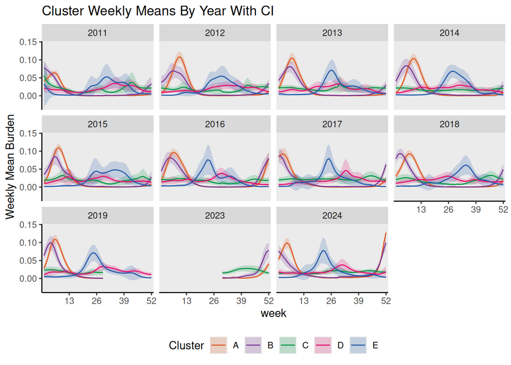

```r
cl_res_by_yr
```

```r
download_file(
  path = "plots/cluster_mean_by_yr.pdf",
  output_name = "cluster_mean_by_yr.pdf",
  button_label = "Download cluster_mean_by_yr.pdf",
  button_type = "danger",
  has_icon = TRUE,
  icon = "fa fa-save",
  self_contained = FALSE
)
```

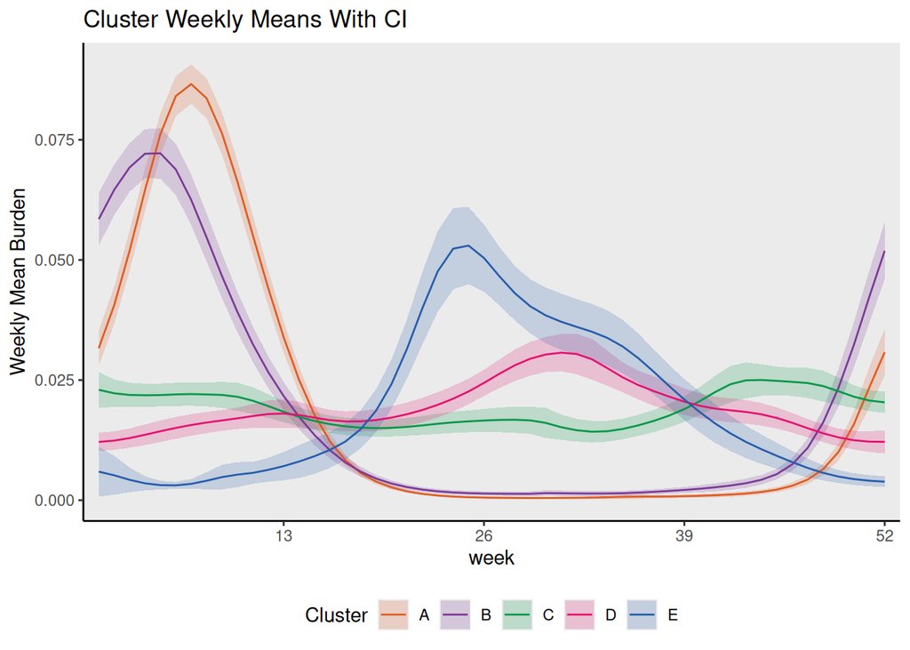

```r
cl_res_by_wk
```

```r
download_file(
  path = "plots/cluster_mean_by_wk.pdf",
  output_name = "cluster_mean_by_yr.pdf",
  button_label = "Download cluster_mean_by_yr.pdf",
  button_type = "danger",
  has_icon = TRUE,
  icon = "fa fa-save",
  self_contained = FALSE
)
```

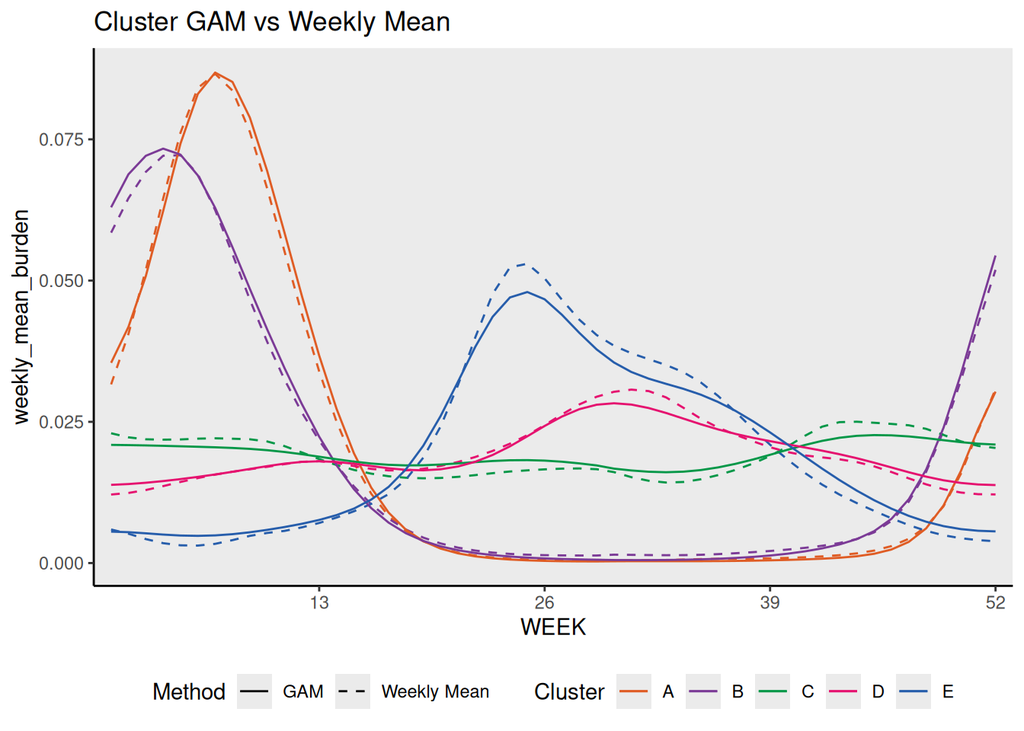

```r
comb_cl_gam_vs_wk_mean
```

```r
download_file(
  path = "plots/cluster_gam_vs_mean.pdf",
  output_name = "cluster_gam_vs_mean.pdf",
  button_label = "Download cluster_gam_vs_mean.pdf",
  button_type = "danger",
  has_icon = TRUE,
  icon = "fa fa-save",
  self_contained = FALSE
)
```

Distribution results are shown above. Both for GAM fits and weekly means with confidence intervals using the underlying data for clusters and countries.

Notice the GAM fits and weekly means are almost identical in their estimations on a cluster level.

## 6. Hypothetical Proxying of Countries With Limited Data

When observing the draft clusters generated, there is a strong latitudinal trend in the resolution. This becomes more evident after mapping the cluster mean latitudes (by country latitudes weighted by city populations).

From this simple concept, we can proxy remaining countries with insufficient (or no) influenza testing data, into the cluster that has the closest average latitude to the country’s latitudinal population center. If a country has a calculation for a maximum quarter from section 2 that information will be used to limit the assignment first to only calendar year or shifted year associated clusters before proxying. If quarter calculation could not be determined, we will do unrestricted latitudinal proxying.

The map with latitudinal country proxying to draft clusters gives us a glimpse at what updated epidemic zones could be. City locations and populations used to compute population-weighted country centroids were obtained from the GeoNames geographical database (GeoNames, n.d.).

```r
# Proxy by latitude

# Obtain dataset of world cities and their population from the maps package
world.cities <- maps::world.cities

# World cities 1000 dataset
world_1000 <- read_tsv("data/cities1000.txt",
                       col_names = c(
                         "geoname_id",
                         "name",
                         "ascii_name",
                         "alternate_names",
                         "latitude",
                         "longitude",
                         "feature_class",
                         "feature_code",
                         "country_code",
                         "cc2",
                         "admin_1_code",
                         "admin_2_code",
                         "admin_3_code",
                         "admin_4_code",
                         "population",
                         "elevation",
                         "dem",
                         "timezone",
                         "modification_date"
                       ))

# Edit maps data to correspond to current country dataset
world_countries <- countrycode(as.character(na.omit(unique(world_1000$country_code))),
                               origin = 'iso2c', destination = 'iso3c')
world_countries[is.na(world_countries == T)] <- c("XKX")

world_countries_names <- countrycode(world_countries,
                               origin = 'iso3c', destination = 'country.name')
world_countries_names[is.na(world_countries_names == T)] <- "Kosovo"

names(world_countries) <- unique(as.character(na.omit(unique(world_1000$country_code))))
world_countries_df <- tibble(country_name = world_countries_names,
                             country_code = names(world_countries),
                             iso3 = world_countries)

# Create avg lat long weighted on population of country cities
world.country.avg.lat.long <- world_1000 %>%
  filter(is.na(country_code) == F) %>%
  left_join(world_countries_df, by = "country_code") %>%
  left_join(co %>% select(COUNTRY_CODE, COUNTRY) %>% distinct(), by = c("iso3" = "COUNTRY_CODE")) %>%
  group_by(country_name, country_code, iso3, COUNTRY) %>%
  summarise(mean_lat = weighted.mean(latitude, population, na.rm = T),
            mean_long = weighted.mean(longitude, population, na.rm = T)) %>%
  mutate(merged_country = coalesce(COUNTRY,country_name))

### What countries are missing from the world_map but are in our list of cities with lat and long?
missing.country.name <- world.country.avg.lat.long$merged_country[world.country.avg.lat.long$merged_country %notin%
                                                                  unique(world_map$region)]

### What countries are missing from the list of cities with lat and long but NOT in the world_map?
missing.region <-  unique(world_map$region)[unique(world_map$region) %notin%
                                              world.country.avg.lat.long$merged_country]

# Re-code countries
merged_country.dict <- c("Congo" = "Republic of Congo",
                         "Congo Democratic Republic" = "Congo (DRC)",
                         "Czech Republic" = "Czechia",
                         "East Timor" = "Timor-Leste",
                         "Ivory Coast" = "Côte d'Ivoire",
                         "Korea North" = "North Korea",
                         "Korea South" = "Republic of Korea",
                         "Laos" = "Lao PDR",
                         "Madeira" = "Madeira Islands",
                         "Moldova" = "Republic of Moldova",
                         "Pitcairn" = "Pitcairn Islands",
                         "Russia" = "Russian Federation",
                         "Saint Vincent and The Grenadines" = "Saint Vincent and the Grenadines",
                         "Saint-Barthelemy" = "Saint Barthélemy",
                         "Saint-Martin" = "Saint Martin",
                         "Turks and Caicos" = "Turks and Caicos Islands",
                         "UK" = "United Kingdom",
                         "USA" = "United States of America",
                         "Vatican City" = "Vatican",
                         "Vietnam" = "Viet Nam",
                         "Curaçao" = "Curacao",
                         "Réunion" = "Reunion",
                         "Micronesia (Federated States of)" = "Micronesia",
                         "Cocos (Keeling) Islands" = "Cocos Islands",
                         "Syrian Arab Republic" = "Syria",
                         "U.S. Virgin Islands" = "US Virgin Islands",
                         "Wallis & Futuna" = "Wallis and Futuna",
                         "Tuvalu" = "Tuvalu",
                         "Tokelau" = "Tokelau")

world.country.avg.lat.long <- world.country.avg.lat.long %>%
  mutate(COUNTRY = if_else(merged_country %notin% unique(world_map$region),
                           as.character(merged_country.dict[merged_country]),
                           merged_country)) %>%
  ungroup() %>%
  select(merged_country, iso3, mean_lat, mean_long, COUNTRY)

# Filter out non-map sub regions
world.country.avg.lat.long <- world.country.avg.lat.long %>%
  filter(is.na(COUNTRY) == F)

world_map_addition <- world_map %>%
  filter(region %notin% world.country.avg.lat.long$COUNTRY) %>%
  group_by(region) %>%
  summarise(mean_lat = mean(lat),
            mean_long = mean(long)) %>%
  mutate(merged_country = region,
         iso3 = countrycode(region, origin = 'country.name', destination = 'iso3c'),
         COUNTRY = region) %>%
  select(merged_country, iso3, mean_lat, mean_long, COUNTRY)


# Complete lat long data set
world.country.avg.lat.long <- bind_rows(world.country.avg.lat.long, world_map_addition) %>%
  mutate(iso3 = case_when(merged_country == "Chagos Archipelago" ~ "IOT", T ~ iso3),
         )

# Compute cluster average lat long values
cluster.avg.lat.long <- co_comb_pass %>%
  select(COUNTRY, COUNTRY_CODE, kmeans_cluster, combined_cluster) %>%
  mutate(cluster_type = "original") %>%
  distinct() %>%
  left_join(world.country.avg.lat.long, by = c("COUNTRY_CODE" = "iso3")) %>%
  group_by(combined_cluster) %>%
  summarise(cl_mean_lat = mean(mean_lat),
            cl_mean_long = mean(mean_long))
```

```r
# Lat values by clusters
dat.temp <- co_comb_pass %>%
  select(COUNTRY, COUNTRY_CODE, kmeans_cluster, combined_cluster) %>%
  mutate(cluster_type = "original") %>%
  distinct() %>%
  left_join(world.country.avg.lat.long, by = c("COUNTRY_CODE" = "iso3"))

# One-way ANOVA comparing the mean Latitude between zones
anova_lat_result <- aov(mean_lat ~ combined_cluster, data = dat.temp)
# Tidy the ANOVA results and extract the p-value
anova_lat_p_value <- tidy(anova_lat_result) %>%
  filter(term == "combined_cluster") %>%
  select(p.value) %>%
  mutate(p.value = case_when(p.value < 0.001 ~ "<0.001",
                           T ~ sprintf("%0.3f", p.value))) %>%
  pull()

# Dotplot of mean_lat grouped by cluster
mean_lat_plot <- dat.temp %>%
ggplot(aes(x = combined_cluster, y = mean_lat, group = combined_cluster)) +
  geom_jitter(aes(color = combined_cluster),
              size = 3, alpha = 0.8, position = position_jitterdodge()) +
  stat_summary(
    fun.data = "mean_sdl", fun.args = list(mult = 1), #
    position = position_dodge(width = .75)
  ) +
  scale_color_manual(values = c("A" = "#DF5C24",
                                "B" = "#7B3A96",
                                "C" = "#059748",
                                "D" = "#E5126F",
                                "E" = "#265DAB"),
                     breaks = c("A","B","C","D","E")) +
  scale_y_continuous(limits = c(-90, 90), breaks = c(-90, -60, -30, 0, 30, 60, 90)) +
  labs(y = "Population-weighted mean latitude",
       x = "Epidemic zone") +
  annotate("text", x = "B", y = -85,
           label = paste0("One-way ANOVA p-value: ", anova_lat_p_value), vjust = -1) +
  theme_bw() +
  theme(legend.position = "none")


# Proxy countries by cluster latitude
lat_proxy_cy <- world.country.avg.lat.long %>%
  filter(COUNTRY %notin% c(unique(co_cy_pass$COUNTRY), unique(co_sy_pass$COUNTRY)) &
           COUNTRY %in% (co_season_max %>%
                           filter(q_season %in% c("Q2","Q3")) %>%
                           distinct(COUNTRY) %>% .$COUNTRY)) %>%
  cross_join(cluster.avg.lat.long %>% filter(combined_cluster %in% c("D","E"))) %>%
  mutate(mean_diff = abs(mean_lat - cl_mean_lat)) %>%
  group_by(COUNTRY) %>%
  filter(mean_diff == min(mean_diff))

lat_proxy_sy <- world.country.avg.lat.long %>%
  filter(COUNTRY %notin% c(unique(co_cy_pass$COUNTRY), unique(co_sy_pass$COUNTRY)) &
           COUNTRY %in% (co_season_max %>%
                           filter(q_season %in% c("Q1","Q4")) %>%
                           distinct(COUNTRY) %>% .$COUNTRY)) %>%
  cross_join(cluster.avg.lat.long %>% filter(combined_cluster %in% c("A","B","C"))) %>%
  mutate(mean_diff = abs(mean_lat - cl_mean_lat)) %>%
  group_by(COUNTRY) %>%
  filter(mean_diff == min(mean_diff))

lat_proxy_ny <- world.country.avg.lat.long %>%
  filter(COUNTRY %notin% c(unique(co_cy_pass$COUNTRY),
                           unique(co_sy_pass$COUNTRY),
                           lat_proxy_cy$COUNTRY,
                           lat_proxy_sy$COUNTRY)) %>%
  cross_join(cluster.avg.lat.long) %>%
  mutate(mean_diff = abs(mean_lat - cl_mean_lat)) %>%
  group_by(COUNTRY) %>%
  filter(mean_diff == min(mean_diff))

# Combine the CY, SY and no partition proxying
lat_proxy <- bind_rows(lat_proxy_cy, lat_proxy_sy, lat_proxy_ny)

# Original cluster map data
original_cluster_map <- co_comb_pass %>%
  select(COUNTRY, COUNTRY_CODE, combined_cluster) %>%
  mutate(cluster_type = "original") %>%
  distinct() %>%
  left_join(world.country.avg.lat.long %>% select(COUNTRY, mean_lat, mean_long), by = "COUNTRY")

# Original cluster map who
original_cluster_map_who <- who_shp %>%
  left_join(original_cluster_map, by = c("ISO_3_CODE" = "COUNTRY_CODE")) %>%
  mutate(COUNTRY_CLEAN = gsub(x = CNTRY_TERR, pattern = "'", replacement = ""))

# Combined cluster map data
combined_cluster_map <- bind_rows(
  (co_comb_pass %>%
     select(COUNTRY, COUNTRY_CODE, combined_cluster) %>%
     mutate(cluster_type = "original") %>%
     distinct()),
  (lat_proxy %>% select(COUNTRY, iso3, combined_cluster) %>%
     magrittr::set_colnames(c("COUNTRY","COUNTRY_CODE", "combined_cluster")) %>%
     mutate(cluster_type = "proxy"))
) %>% left_join(world.country.avg.lat.long %>% select(COUNTRY, mean_lat, mean_long), by = "COUNTRY") %>%
  left_join(co %>% select(COUNTRY, ITZ)) %>% #itz)) #### CHECK: does "itz" need to be capitalized
  distinct()

# Combined cluster map who
combined_cluster_map_who <- who_shp %>%
  left_join(combined_cluster_map, by = c("ISO_3_CODE" = "COUNTRY_CODE")) %>%
  mutate(COUNTRY_CLEAN = gsub(x = CNTRY_TERR, pattern = "'", replacement = ""),
         centroid = st_centroid(geometry),
         centroid = st_coordinates(centroid),
         centroid_ml = centroid[,"Y"]) %>%
  mutate(
    cluster_type = if_else(
      is.na(cluster_type) & is.nan(centroid_ml) == F,
      "proxy",
      cluster_type
    )
  )

combined_cluster_map_who$centroid_cl <- sapply(combined_cluster_map_who$centroid_ml, function(x){
  if(is.na(x) | is.nan(x)) {
    return(x)
  } else {
    return(cluster.avg.lat.long$combined_cluster[which.min(abs(x - cluster.avg.lat.long$cl_mean_lat))])
  }
})

combined_cluster_map_who <- combined_cluster_map_who %>%
  mutate(combined_cluster = coalesce(combined_cluster, centroid_cl))

# Original Cluster Mean Map Plot
original_mean_map_plot <- ggplot() +
  geom_sf(data = original_cluster_map_who,
          fill="#7F7F7F", color="black", linewidth = 0.1) +
  ggiraph::geom_sf_interactive(data = original_cluster_map_who,
                               aes(color = combined_cluster,
                                   tooltip = paste(COUNTRY_CLEAN, combined_cluster, sep = "-"),
                                   data_id = COUNTRY_CLEAN),
                               fill = "lightgray", linewidth = 0.1) +
  geom_point(data = original_cluster_map_who, aes(x = mean_long, y = mean_lat, color = combined_cluster)) +
  geom_hline(cluster.avg.lat.long, mapping = aes(yintercept = cl_mean_lat, colour = combined_cluster), linetype = 2) +
  coord_sf(expand = FALSE) +
  theme(legend.position="bottom",
        panel.grid.major = element_blank(),
        panel.grid.minor = element_blank(),
        panel.border = element_blank(),
        axis.title.x=element_blank(),
        axis.text.x=element_blank(),
        axis.ticks.x=element_blank(),
        axis.title.y=element_blank(),
        axis.text.y=element_blank(),
        axis.ticks.y=element_blank(),
        text = element_text(size = 8)) +
  guides(fill = guide_legend(nrow = 2)) +
  scale_color_manual(values = c("A" = "#DF5C24",
                                "B" = "#7B3A96",
                                "C" = "#059748",
                                "D" = "#E5126F",
                                "E" = "#265DAB"),
                     breaks = c("A","B","C","D","E")) +
  scale_fill_manual(values = c("A" = "#DF5C24",
                               "B" = "#7B3A96",
                               "C" = "#059748",
                               "D" = "#E5126F",
                               "E" = "#265DAB"),
                    breaks = c("A","B","C","D","E")) +
  guides(color=guide_legend(title="Cluster"),
         fill=guide_legend(title="Cluster")) +
  ggtitle("Cluster Mean Latitudes and Geographic Country Population Centers")
```

```r
# Original Cluster Map Plot With Filled Countries
original_map_plot <- ggplot(original_cluster_map_who, aes(data_id = COUNTRY_CLEAN)) +
  geom_sf(data = original_cluster_map_who,
          fill="#7F7F7F", color="black", linewidth = 0.1) +
  ggiraph::geom_sf_interactive(data = original_cluster_map_who,
                               aes(fill = combined_cluster,
                                   tooltip = paste(COUNTRY_CLEAN, combined_cluster, sep = "-"),
                                   data_id = COUNTRY_CLEAN),
                               linewidth = 0.1, color="black") +
  geom_hline(cluster.avg.lat.long, mapping = aes(yintercept = cl_mean_lat, colour = combined_cluster), linetype = 2) +
  coord_sf(expand = FALSE) +
  theme(legend.position="bottom",
        panel.grid.major = element_blank(),
        panel.grid.minor = element_blank(),
        panel.border = element_blank(),
        axis.title.x=element_blank(),
        axis.text.x=element_blank(),
        axis.ticks.x=element_blank(),
        axis.title.y=element_blank(),
        axis.text.y=element_blank(),
        axis.ticks.y=element_blank(),
        text = element_text(size = 8)) +
  guides(fill = guide_legend(nrow = 1)) +
  scale_color_manual(values = c("A" = "#DF5C24",
                                "B" = "#7B3A96",
                                "C" = "#059748",
                                "D" = "#E5126F",
                                "E" = "#265DAB"),
                     breaks = c("A","B","C","D","E")) +
  scale_fill_manual(values = c("A" = "#DF5C24",
                               "B" = "#7B3A96",
                               "C" = "#059748",
                               "D" = "#E5126F",
                               "E" = "#265DAB"),
                    breaks = c("A","B","C","D","E"),
                    na.translate = F) +
  guides(color=guide_legend(title="Cluster"),
         fill=guide_legend(title="Cluster")) +
  ggtitle("Country Clusters With Mean Latitudes")


# Original Cluster Map Plot With Filled Countries (NO LATITUDE LINES)
original_map_plot_concise <- ggplot(original_cluster_map_who, aes(data_id = COUNTRY_CLEAN)) +
  geom_sf(data = original_cluster_map_who,
          fill="#7F7F7F", color="black", size = 0.1) +
  ggiraph::geom_sf_interactive(data = original_cluster_map_who,
                               aes(fill = combined_cluster,
                                   tooltip = paste(COUNTRY_CLEAN, combined_cluster, sep = "-"),
                                   data_id = COUNTRY_CLEAN),
                               linewidth = 0.1, color="black") +
  #geom_hline(cluster.avg.lat.long, mapping = aes(yintercept = cl_mean_lat, colour = combined_cluster), linetype = 2) +
  coord_sf(expand = FALSE) +
  theme(legend.position="bottom",
        panel.grid.major = element_blank(),
        panel.grid.minor = element_blank(),
        panel.border = element_blank(),
        axis.title.x=element_blank(),
        axis.text.x=element_blank(),
        axis.ticks.x=element_blank(),
        axis.title.y=element_blank(),
        axis.text.y=element_blank(),
        axis.ticks.y=element_blank(),
        text = element_text(size = 8)) +
  guides(fill = guide_legend(nrow = 1)) +
  scale_color_manual(values = c("A" = "#DF5C24",
                                "B" = "#7B3A96",
                                "C" = "#059748",
                                "D" = "#E5126F",
                                "E" = "#265DAB"),
                     breaks = c("A","B","C","D","E")) +
  scale_fill_manual(values = c("A" = "#DF5C24",
                               "B" = "#7B3A96",
                               "C" = "#059748",
                               "D" = "#E5126F",
                               "E" = "#265DAB"),
                    breaks = c("A","B","C","D","E")) +
  guides(color=guide_legend(title="Cluster"),
         fill=guide_legend(title="Cluster"))

# Combined Map Plot With Proxied Countries
combined_map_plot <- ggplot(combined_cluster_map_who, aes(data_id = COUNTRY_CLEAN)) +
  geom_sf(data = combined_cluster_map_who,
          fill="#7F7F7F", color="black", size = 0.1) +
  ggiraph::geom_sf_interactive(data = combined_cluster_map_who,
                               aes(fill = combined_cluster,
                                   tooltip = paste(COUNTRY_CLEAN, combined_cluster, cluster_type, sep = "\n"),
                                   data_id = COUNTRY_CLEAN),
                               linewidth = 0.1, color = "black") +
  geom_hline(cluster.avg.lat.long, mapping = aes(yintercept = cl_mean_lat, colour = combined_cluster), linetype = 2) +
  coord_sf(expand = FALSE) +
  theme(legend.position="bottom",
        panel.grid.major = element_blank(),
        panel.grid.minor = element_blank(),
        panel.border = element_blank(),
        axis.title.x=element_blank(),
        axis.text.x=element_blank(),
        axis.ticks.x=element_blank(),
        axis.title.y=element_blank(),
        axis.text.y=element_blank(),
        axis.ticks.y=element_blank(),
        text = element_text(size = 8)) +
  guides(fill = guide_legend(nrow = 1)) +
  scale_color_manual(values = c("A" = "#DF5C24",
                                "B" = "#7B3A96",
                                "C" = "#059748",
                                "D" = "#E5126F",
                                "E" = "#265DAB"),
                     breaks = c("A","B","C","D","E")) +
  scale_fill_manual(values = c("A" = "#DF5C24",
                               "B" = "#7B3A96",
                               "C" = "#059748",
                               "D" = "#E5126F",
                               "E" = "#265DAB"),
                    breaks = c("A","B","C","D","E")) +
  guides(color=guide_legend(title="Cluster"),
         fill=guide_legend(title="Cluster")) +
  ggtitle("Clusters With Latitudial Proxying")

# Combined Map Plot With Proxied Countries (alpha is determined by whether it was proxied or not)
combined_map_plot_alpha <- ggplot(combined_cluster_map_who, aes(data_id = COUNTRY_CLEAN)) +
  geom_sf(data = combined_cluster_map_who,
          fill="white", color="white", size = 0.1) +
  ggiraph::geom_sf_interactive(data = combined_cluster_map_who,
                               aes(fill = combined_cluster,
                                   alpha = cluster_type,
                                   tooltip = paste(COUNTRY_CLEAN, combined_cluster, sep = "-"),
                                   data_id = COUNTRY_CLEAN),
                               size = 0.05, color="black") +
  #geom_hline(cluster.avg.lat.long, mapping = aes(yintercept = cl_mean_lat, colour = combined_cluster), linetype = 2) +
  coord_sf(expand = FALSE) +
  theme(legend.position="bottom",
        panel.grid.major = element_blank(),
        panel.grid.minor = element_blank(),
        panel.border = element_rect(color = "black", fill = NA),
        panel.background = element_blank(),
        axis.title.x=element_blank(),
        axis.text.x=element_blank(),
        axis.ticks.x=element_blank(),
        axis.title.y=element_blank(),
        axis.text.y=element_blank(),
        axis.ticks.y=element_blank(),
        text = element_text(size = 8)) +
  guides(fill = guide_legend(nrow = 1)) +
  scale_color_manual(values = c("A" = "#DF5C24",
                                "B" = "#7B3A96",
                                "C" = "#059748",
                                "D" = "#E5126F",
                                "E" = "#265DAB"),
                     breaks = c("A","B","C","D","E")) +
  scale_fill_manual(values = c("A" = "#DF5C24",
                               "B" = "#7B3A96",
                               "C" = "#059748",
                               "D" = "#E5126F",
                               "E" = "#265DAB"),
                    breaks = c("A","B","C","D","E")) +
  scale_alpha_manual(values = c(1, 0.5),
                     breaks = c("original", "proxy"),
                     guide="none") +
  guides(color=guide_legend(title="Cluster"),
         fill=guide_legend(title="Cluster"))  #+
#ggtitle("Clusters With Latitudial Proxying")
```

```r
# Comparison plot with original and combined with cluster proxy countries
proxy_comparison_plot <- cowplot::plot_grid(original_map_plot, combined_map_plot, ncol = 1)

# Interactive Version
proxy_comparison_plot_int <- ggiraph::girafe(ggobj = proxy_comparison_plot)

original_plot_int <- ggiraph::girafe(ggobj = original_map_plot)

comb_plot_int <- ggiraph::girafe(ggobj = combined_map_plot)


# Extract the legend
leg <- ggpubr::get_legend(original_map_plot)
leg_plot <- ggpubr::as_ggplot(leg)

top_map <- cowplot::plot_grid(original_map_plot + theme(legend.position="none"),
                              combined_map_plot + theme(legend.position="none"),
                              ncol = 2)

bottom_dist <- inf_cluster_gam_plot + theme(legend.position="none")

comb_total_plot <- cowplot::plot_grid(top_map, bottom_dist, leg_plot, ncol = 1,
                                      rel_heights = c(1.75, 1, 0.1))

ggsave("plots/proxy_clustering_and_distributions.pdf", comb_total_plot, units = "in", width = 11, height = 8.5)
```

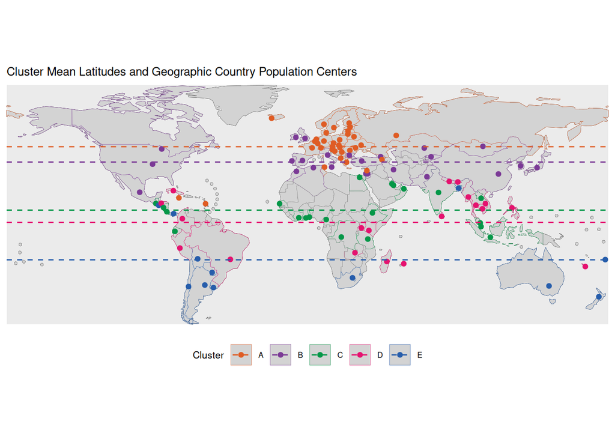

```r
original_mean_map_plot
```

```r
original_plot_int
```

[interactive chart not shown]

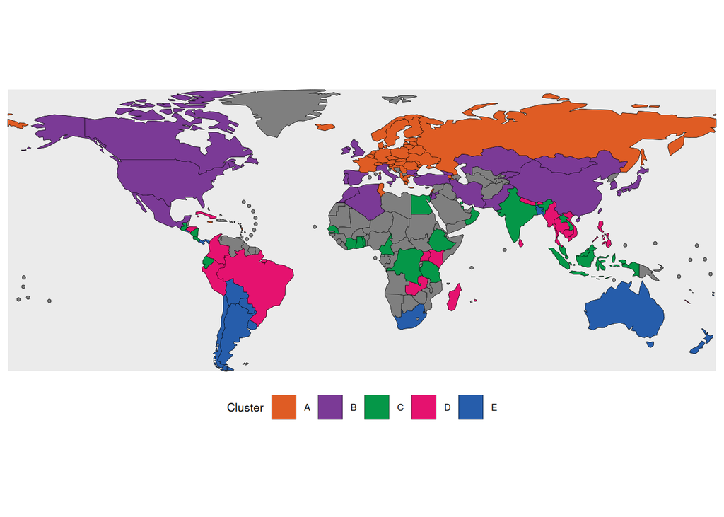

```r
original_map_plot_concise
```

```r
ggsave("plots/map_original_countries.pdf", original_map_plot_concise, units = "in", width = 11, height = 8.5)
```

```r
comb_plot_int
```

[interactive chart not shown]

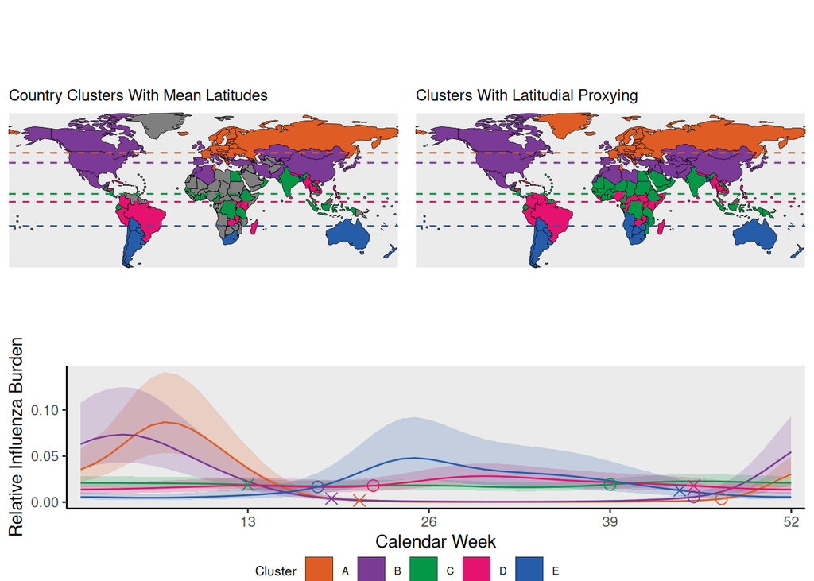

```r
comb_total_plot
```

```r
download_file(
  path = "plots/proxy_clustering_and_distributions.pdf",
  output_name = "proxy_clustering_and_distributions.pdf",
  button_label = "Download proxy_clustering_and_distributions.pdf",
  button_type = "danger",
  has_icon = TRUE,
  icon = "fa fa-save",
  self_contained = FALSE
)
```

The latitudes were quite similar within clusters, with a significant one-way ANOVA difference in mean latitude between epidemic zones (p-value: <0.001).

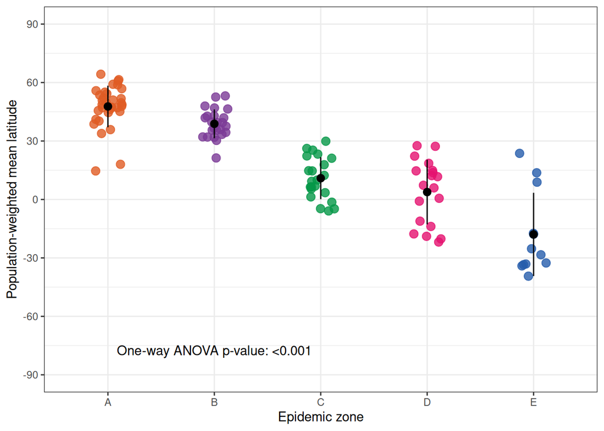

```r
mean_lat_plot
```

```r
ggsave("plots/mean_latitude_bycluster.pdf", mean_lat_plot, units = "in", width = 11, height = 8.5)
```

From these analyses **111** countries were used to establish the initial draft clusters (the `*_pass` partitions used for consensus clustering and the cluster/country-level burden-curve GAMs above). The initial influenza testing data had **180** countries listed. From that broader set, **150** countries had estimated country-period GAMs in Section 3 (used to compute `inf_all_burden`) – a larger set than the 111 countries retained for clustering, since it also includes countries that passed the basic detection/weeks-reported thresholds but lacked the >=5 years of data required for the consensus ensemble. The final dataset with latitudinal cluster proxying has all **253** countries with a cluster assignment. These assignments may be refined in the future with continuing years of data from countries and the possible inclusion of more countries into the primary analysis.

We will then generate tables of information for cluster distributions for outside use.

```r
# Create GAM fit tables
comb_cluster_prob <- inf_cluster_gam_v %>%
  ungroup() %>%
  dplyr::select(combined_cluster, inf_clust_fit, WEEK, inf_clust_fit_new, inf_clust_lwr_new, inf_clust_upr_new) %>%
  mutate(inf_clust_fit = as.numeric(inf_clust_fit),
         inf_clust_fit_new = as.numeric(inf_clust_fit_new),
         inf_clust_lwr_new = as.numeric(inf_clust_lwr_new),
         inf_clust_upr_new = as.numeric(inf_clust_upr_new)) %>%
  magrittr::set_colnames(c("combined_cluster","inf_gam_fit","week","inf_gam_fit_adj","inf_gam_fit_adj_lwr","inf_gam_fit_adj_upr"))

write_tsv(comb_cluster_prob, "data/co_cluster_probabilities.tsv", na = "")
write_tsv(comb_cluster_prob, "data/co_cluster_probabilities_tbl.tsv", na = "\\N", col_names = F)

# Output Cluster Mapping Tables
write_tsv(combined_cluster_map, "data/co_cluster_mapping.tsv", na = "")
write_tsv(combined_cluster_map, "data/co_cluster_mapping_tbl.tsv", na = "\\N", col_names = F)

# Output Country GAM fits for passing data
write_tsv(inf_co_gam_v %>%
            ungroup() %>%
            mutate(inf_clust_fit = as.numeric(inf_clust_fit),
                   inf_clust_se = as.numeric(inf_clust_se),
                   inf_clust_lwr = as.numeric(inf_clust_lwr),
                   inf_clust_upr = as.numeric(inf_clust_upr),
                   inf_clust_fit_new = as.numeric(inf_clust_fit_new),
                   inf_clust_lwr_new = as.numeric(inf_clust_lwr_new),
                   inf_clust_upr_new = as.numeric(inf_clust_upr_new)),
          "data/co_country_gams.tsv", na = "")
```

### 6.1 Assessment of Latitudinal Proxying by Leave One Out Analysis

After generating the tables of distributions, we completed a leave-one-out analysis to assess the validity of assigning countries with insufficient data to clusters by latitudinal proxying. The leave one out was conducted by sequentially leaving countries out of each analysis partition, recomputing the entire clustering using the same algorithms and resampling as the final result runs, and then proxying the country that was left out to closest cluster mean latitude. First, we need to save the necessary data into an `.Rdata` bundle, in order to offload the compute outside of the Rmarkdown document.

```r
# Save the necessary objects to file to complete a leave-one-out analysis
# assessing latitudinal proxying
# This packages up everything the LOO cluster script needs into ONE .RData
# file: the RAW data for both partitions, each partition's chosen final clustering
# labels, and a latitude lookup table.

# Raw data frames for each partition required:
# These should be your original raw data frames with columns:
#   COUNTRY, COUNTRY_CODE, YEAR, WEEK, inf_all_burden (calendar)
#   COUNTRY, COUNTRY_CODE, shifted_year, shifted_week, inf_all_burden (shifted)
raw_df_list <- list(
  co_cy_pass = co_cy_pass,
  co_sy_pass = co_sy_pass
)

# Original final clustering labels for each partition:
original_labels_list <- list(
  co_cy_pass = final_calendar_clustering$labels,
  co_sy_pass = final_shifted_clustering$labels
)

# Latitude lookup table:
lat_lookup <- world.country.avg.lat.long %>%
  mutate(country_code = iso3,
         latitude = mean_lat)

lat_lookup_list <- list(
  co_cy_pass = lat_lookup,
  co_sy_pass = lat_lookup
)

# Checks before saving
for (p in names(raw_df_list)) {
  cat(sprintf("\n--- Checking partition: %s ---\n", p))

  raw_df <- raw_df_list[[p]]
  labels <- original_labels_list[[p]]
  lat_lkp <- lat_lookup_list[[p]]

  # Check raw_df has the columns standardize_columns() will need
  has_cy_cols <- all(c("YEAR", "WEEK") %in% names(raw_df))
  has_sy_cols <- all(c("shifted_year", "shifted_week") %in% names(raw_df))
  cat(sprintf("  Has calendar columns (YEAR, WEEK): %s\n", has_cy_cols))
  cat(sprintf("  Has shifted columns (shifted_year, shifted_week): %s\n", has_sy_cols))
  cat(sprintf("  Has COUNTRY, COUNTRY_CODE, inf_all_burden: %s\n",
              all(c("COUNTRY", "COUNTRY_CODE", "inf_all_burden") %in% names(raw_df))))

  # Check labels is a named vector
  cat(sprintf("  original_labels: %d countries, named vector: %s\n",
              length(labels), !is.null(names(labels))))

  # Check lat_lookup has required columns
  cat(sprintf("  lat_lookup: %d rows, has country_code/latitude columns: %s\n",
              nrow(lat_lkp), all(c("country_code", "latitude") %in% names(lat_lkp))))

  # Check for countries in labels but missing from lat_lookup (these will
  # produce NA latitude-proxy results, worth knowing about upfront)
  missing_lat <- setdiff(names(labels), lat_lkp$country_code)
  if (length(missing_lat) > 0) {
    cat(sprintf("  WARNING: %d countries in original_labels have NO latitude entry: %s\n",
                length(missing_lat), paste(missing_lat, collapse = ", ")))
  }
}
```

```
##
## --- Checking partition: co_cy_pass ---
##   Has calendar columns (YEAR, WEEK): TRUE
##   Has shifted columns (shifted_year, shifted_week): TRUE
##   Has COUNTRY, COUNTRY_CODE, inf_all_burden: TRUE
##   original_labels: 31 countries, named vector: TRUE
##   lat_lookup: 255 rows, has country_code/latitude columns: TRUE
##
## --- Checking partition: co_sy_pass ---
##   Has calendar columns (YEAR, WEEK): TRUE
##   Has shifted columns (shifted_year, shifted_week): TRUE
##   Has COUNTRY, COUNTRY_CODE, inf_all_burden: TRUE
##   original_labels: 80 countries, named vector: TRUE
##   lat_lookup: 255 rows, has country_code/latitude columns: TRUE
```

```r
# Save the bundle
save(raw_df_list, original_labels_list, lat_lookup_list,
     file = "data/loo_input_bundle.RData")

cat("\n=== Bundle saved to data/loo_input_bundle.RData ===\n")
```

```
##
## === Bundle saved to data/loo_input_bundle.RData ===
```

```r
cat(sprintf("File size: %.1f MB\n", file.size("data/loo_input_bundle.RData") / 1e6))
```

```
## File size: 3.7 MB
```

The scripts to conduct the compute is located in `scripts/loo_analysis.R` and `scripts/loo_analysis_alignment.R`. The first script conducts the leave one out analysis run itself and saves all the run results. The second script (`scripts/loo_analysis_alignment.R`) loads all the computed results and aligns each analysis clustering run with the original analysis clustering by consensus grouping, as clustering number assignment is arbitrary. This way we can easily assess the percentage of countries that are assigned to their original cluster via latitudinal proxying, and also the run to run variation in clustering assignment for countries included in each run.

The following are accessory functions to the leave one out analysis:

```r
# Load a consolidated LOO .RData file:
# Returns a named list matching the cluster script's saved structure:
#   loo_results: loo_results[[partition]][[country]], nested list
#   loo_summary: flat data frame, one row per (partition, country)
#   loo_run_metadata: loo_run_metadata[[partition]], settings used per partition
#   country_lookups: country_lookups[[partition]]
#   original_labels_list: original_labels_list[[partition]] (needed by
#    the alignment/stability functions below)
#   lat_lookups: lat_lookups[[partition]]
load_loo_results <- function(rdata_path) {
  if (!file.exists(rdata_path)) stop("LOO results file not found: ", rdata_path)

  e <- new.env()
  loaded_names <- load(rdata_path, envir = e)

  required <- c("loo_results", "loo_summary", "loo_run_metadata")
  missing <- setdiff(required, loaded_names)
  if (length(missing) > 0) {
    stop("LOO results file is missing expected objects: ", paste(missing, collapse = ", "))
  }

  cat("Loaded LOO analysis results:\n")
  for (p in names(e$loo_run_metadata)) {
    if (p == "total_elapsed_hours") next
    meta <- e$loo_run_metadata[[p]]
    cat(sprintf("  [%s] dataset_type=%s | algo=%s | k=%d | final=%s | n_boot=%d | resample_pct=%.2f | n_countries=%d\n",
                p, meta$dataset_type %||% "NA", meta$chosen_algo, meta$k_final, meta$final_algorithm,
                meta$n_boot, meta$resample_pct, meta$n_countries))
  }
  if (!is.null(e$loo_run_metadata$total_elapsed_hours)) {
    cat(sprintf("  Total elapsed: %.2f hours\n", e$loo_run_metadata$total_elapsed_hours))
  }
  cat(sprintf("  Successful: %d / %d\n", sum(e$loo_summary$loo_rerun_succeeded), nrow(e$loo_summary)))

  as.list(e)
}

# Align LOO run labels to the ORIGINAL clustering:
# Each LOO run's cluster labels are arbitrary. Before any
# cross-run comparison is meaningful, every LOO run's labels must be mapped
# onto the original final clustering's numbering via best-overlap matching.
align_loo_labels_to_original <- function(loo_labels, original_labels) {
  common <- intersect(names(loo_labels), names(original_labels))
  if (length(common) == 0) return(NULL)

  overlap <- table(loo_labels[common], original_labels[common])

  mapping <- c()
  used_original <- c()
  for (r in rownames(overlap)[order(-apply(overlap, 1, max))]) {
    candidates <- overlap[r, ]
    candidates[names(candidates) %in% used_original] <- -1
    best_original <- names(candidates)[which.max(candidates)]
    mapping[r] <- best_original
    used_original <- c(used_original, best_original)
  }

  aligned <- as.integer(mapping[as.character(loo_labels)])
  names(aligned) <- names(loo_labels)
  aligned
}

# Verify label correspondence quality for every LOO run:
# For each LOO run, reports how well its aligned labels actually agree with
# the original clustering (via ARI, computed on the aligned labels vs.
# original, over the common countries). A low ARI here means the rest of the
# partition reorganized substantially when that country was excluded.
verify_loo_label_correspondence <- function(loo_data) {
  results <- do.call(rbind, lapply(names(loo_data$loo_results), function(partition_name) {
    partition_results <- loo_data$loo_results[[partition_name]]
    original_labels <- loo_data$original_labels_list[[partition_name]]

    do.call(rbind, lapply(names(partition_results), function(excluded) {
      entry <- partition_results[[excluded]]
      if (!entry$succeeded) {
        return(data.frame(partition = partition_name, excluded_country = excluded,
                           n_common = NA, ari = NA, note = "LOO run failed"))
      }

      aligned <- align_loo_labels_to_original(entry$final$labels, original_labels)
      common <- intersect(names(aligned), names(original_labels))
      ari <- compute_ari(aligned, original_labels)

      data.frame(partition = partition_name, excluded_country = excluded,
                 n_common = length(common), ari = round(ari, 4), note = NA)
    }))
  }))

  rownames(results) <- NULL
  cat("Label correspondence (aligned LOO labels vs. original clustering) by run:\n")
  print(results)
  cat(sprintf("\nMean ARI across all successful LOO runs: %.4f\n", mean(results$ari, na.rm = TRUE)))
  cat("Runs with notably LOW ARI indicate the partition reorganized substantially\n")
  cat("when that country was excluded -- worth inspecting those specifically.\n")

  results
}

## Cross-LOO-run membership stability per country:
## For every country, across every LOO run where it was NOT the excluded one,
## records which (ALIGNED) cluster it landed in. Summarizes as: the country's
## MODAL (most common) aligned cluster across all those runs, and a stability
## score = the fraction of runs where it landed in that modal cluster (1.0 =
## perfectly consistent across every LOO run; lower = the country's cluster
## assignment is sensitive to which other country gets excluded).
##
## This is conceptually parallel to compute_raw_cluster_tally()'s shift_score,
## but the axis of perturbation here is "which country was excluded from the
## WHOLE ensemble rebuild," rather than "which bootstrap resample."
compute_loo_membership_stability <- function(loo_data, partition_name) {
  partition_results <- loo_data$loo_results[[partition_name]]
  original_labels <- loo_data$original_labels_list[[partition_name]]
  all_countries <- names(original_labels)

  # tally[country, cluster] = number of LOO runs (excluding ones where this
  # country itself was the excluded one, since it has no assignment then)
  # where this country landed in that ALIGNED cluster
  k <- length(unique(original_labels))
  tally <- matrix(0, nrow = length(all_countries), ncol = k,
                   dimnames = list(all_countries, paste0("cluster_", seq_len(k))))
  n_runs_present <- setNames(rep(0, length(all_countries)), all_countries)

  for (excluded in names(partition_results)) {
    entry <- partition_results[[excluded]]
    if (!entry$succeeded) next

    aligned <- align_loo_labels_to_original(entry$final$labels, original_labels)
    if (is.null(aligned)) next

    for (c in names(aligned)) {
      cl <- aligned[c]
      if (is.na(cl) || cl < 1 || cl > k) next
      tally[c, cl] <- tally[c, cl] + 1
      n_runs_present[c] <- n_runs_present[c] + 1
    }
  }

  tally_df <- as.data.frame(tally)
  tally_df$country_code <- rownames(tally_df)
  tally_df$n_loo_runs_present <- n_runs_present[rownames(tally_df)]
  tally_df$original_cluster <- original_labels[rownames(tally_df)]

  tally_df$modal_cluster <- apply(tally[, seq_len(k), drop = FALSE], 1, function(x) {
    if (sum(x) == 0) return(NA)
    which.max(x)
  })
  tally_df$stability_score <- apply(tally[, seq_len(k), drop = FALSE], 1, function(x) {
    if (sum(x) == 0) return(NA)
    max(x) / sum(x)
  })
  tally_df$modal_matches_original <- tally_df$modal_cluster == tally_df$original_cluster

  tally_df <- tally_df %>%
    select(country_code, original_cluster, modal_cluster, modal_matches_original,
           stability_score, n_loo_runs_present, everything()) %>%
    arrange(stability_score)

  cat(sprintf("\nLOO membership stability for partition '%s' (k = %d):\n", partition_name, k))
  cat(sprintf("Mean stability score across all countries: %.3f\n", mean(tally_df$stability_score, na.rm = TRUE)))
  cat(sprintf("Countries whose modal LOO cluster does NOT match their original cluster: %d / %d\n",
              sum(!tally_df$modal_matches_original, na.rm = TRUE), nrow(tally_df)))
  cat("\nLeast stable countries (lowest stability_score):\n")
  print(head(tally_df[, c("country_code", "original_cluster", "modal_cluster", "modal_matches_original", "stability_score", "n_loo_runs_present")], 10))

  tally_df
}
```

After completing the analysis run and alignment we can then load the results (`data/loo_analysis_final_corrected.RData`) for assessment.

```r
loo_data <- load_loo_results("data/loo_analysis_final_corrected.RData")
```

```
## Loaded LOO analysis results:
##   [co_cy_pass] dataset_type=calendar | algo=kmeans | k=2 | final=spectral | n_boot=1000 | resample_pct=0.90 | n_countries=31
##   [co_sy_pass] dataset_type=shifted | algo=kmeans | k=3 | final=spectral | n_boot=1000 | resample_pct=0.90 | n_countries=80
##   Total elapsed: 3.90 hours
##   Successful: 111 / 111
```

```r
# Overall mean rate of proxying success
loo_mean <- loo_data$loo_summary %>%
  summarise(m = sum(original_cluster == proxy_cluster)/length(original_cluster))

# --- Quick look at the overall summary across both partitions ---
loo_data$loo_summary %>%
  mutate(combinded_cluster = case_when(partition == "co_sy_pass" & original_cluster == 1 ~ "A",
                                       partition == "co_sy_pass" & original_cluster == 2 ~ "C",
                                       partition == "co_sy_pass" & original_cluster == 3 ~ "B",
                                       partition == "co_cy_pass" & original_cluster == 1 ~ "E",
                                       partition == "co_cy_pass" & original_cluster == 2 ~ "D")) %>%
  group_by(combinded_cluster, partition, original_cluster) %>%
  summarise(n_countries = n(),
            n_lat_proxy_match = sum(original_cluster == proxy_cluster),
            perc_proxy_match = n_lat_proxy_match/n_countries) %>%
  kable(format = "html") %>%
  kable_styling(bootstrap_options = c("striped", "hover", "condensed"), full_width = FALSE) %>%
  scroll_box(height = "400px")
```

| combinded_cluster | partition | original_cluster | n_countries | n_lat_proxy_match | perc_proxy_match |
| --- | --- | --- | --- | --- | --- |
| A | co_sy_pass | 1 | 34 | 27 | 0.7941176 |
| B | co_sy_pass | 3 | 24 | 17 | 0.7083333 |
| C | co_sy_pass | 2 | 22 | 19 | 0.8636364 |
| D | co_cy_pass | 2 | 19 | 13 | 0.6842105 |
| E | co_cy_pass | 1 | 12 | 9 | 0.7500000 |

From the results of the leave one out analysis we can see a high level of congruence between the final “original cluster” and the leave one out run “modal” cluster with an overall proxying match rate of 76.6%. With a minimum of 68.4% (combined cluster D) and maximum of 86.4% (combined cluster C) of intracluster proxying match rates.

We can also evaluate the stability of the clusters from run to run in the leave one out analysis.

```r
correspondence <- verify_loo_label_correspondence(loo_data)
```

```
## Label correspondence (aligned LOO labels vs. original clustering) by run:
##      partition excluded_country n_common    ari note
## 1   co_cy_pass              ARG       30 0.8666   NA
## 2   co_cy_pass              AUS       30 1.0000   NA
## 3   co_cy_pass              BGD       30 1.0000   NA
## 4   co_cy_pass              BOL       30 1.0000   NA
## 5   co_cy_pass              BRA       30 1.0000   NA
## 6   co_cy_pass              BTN       30 1.0000   NA
## 7   co_cy_pass              CHL       30 1.0000   NA
## 8   co_cy_pass              COL       30 1.0000   NA
## 9   co_cy_pass              CUB       30 1.0000   NA
## 10  co_cy_pass              FJI       30 1.0000   NA
## 11  co_cy_pass              HND       30 1.0000   NA
## 12  co_cy_pass              KEN       30 1.0000   NA
## 13  co_cy_pass              KHM       30 1.0000   NA
```

[output cut: 102 more lines]

```r
stability_cy <- compute_loo_membership_stability(loo_data, partition_name = "co_cy_pass")
```

```
##
## LOO membership stability for partition 'co_cy_pass' (k = 2):
## Mean stability score across all countries: 0.997
## Countries whose modal LOO cluster does NOT match their original cluster: 0 / 31
##
## Least stable countries (lowest stability_score):
##     country_code original_cluster modal_cluster modal_matches_original
## BRA          BRA                2             2                   TRUE
## ARG          ARG                1             1                   TRUE
## AUS          AUS                1             1                   TRUE
## BGD          BGD                1             1                   TRUE
## BOL          BOL                1             1                   TRUE
## BTN          BTN                2             2                   TRUE
## CHL          CHL                1             1                   TRUE
## COL          COL                2             2                   TRUE
## CUB          CUB                2             2                   TRUE
## FJI          FJI                1             1                   TRUE
##     stability_score n_loo_runs_present
## BRA             0.9                 30
## ARG             1.0                 30
## AUS             1.0                 30
## BGD             1.0                 30
## BOL             1.0                 30
## BTN             1.0                 30
## CHL             1.0                 30
## COL             1.0                 30
## CUB             1.0                 30
## FJI             1.0                 30
```

```r
stability_cy %>%
  mutate(combined_cluster = case_when(original_cluster == 1 ~ "E",
                                      original_cluster == 2 ~ "D")) %>%
  relocate(combined_cluster) %>%
  kable(format = "html") %>%
  kable_styling(bootstrap_options = c("striped", "hover", "condensed"), full_width = FALSE) %>%
  scroll_box(height = "400px")
```

|  | combined_cluster | country_code | original_cluster | modal_cluster | modal_matches_original | stability_score | n_loo_runs_present | cluster_1 | cluster_2 |
| --- | --- | --- | --- | --- | --- | --- | --- | --- | --- |
| BRA | D | BRA | 2 | 2 | TRUE | 0.9 | 30 | 3 | 27 |
| ARG | E | ARG | 1 | 1 | TRUE | 1.0 | 30 | 30 | 0 |
| AUS | E | AUS | 1 | 1 | TRUE | 1.0 | 30 | 30 | 0 |
| BGD | E | BGD | 1 | 1 | TRUE | 1.0 | 30 | 30 | 0 |
| BOL | E | BOL | 1 | 1 | TRUE | 1.0 | 30 | 30 | 0 |
| BTN | D | BTN | 2 | 2 | TRUE | 1.0 | 30 | 0 | 30 |
| CHL | E | CHL | 1 | 1 | TRUE | 1.0 | 30 | 30 | 0 |
| COL | D | COL | 2 | 2 | TRUE | 1.0 | 30 | 0 | 30 |
| CUB | D | CUB | 2 | 2 | TRUE | 1.0 | 30 | 0 | 30 |
| FJI | E | FJI | 1 | 1 | TRUE | 1.0 | 30 | 30 | 0 |
| HND | D | HND | 2 | 2 | TRUE | 1.0 | 30 | 0 | 30 |
| KEN | D | KEN | 2 | 2 | TRUE | 1.0 | 30 | 0 | 30 |
| KHM | D | KHM | 2 | 2 | TRUE | 1.0 | 30 | 0 | 30 |
| LKA | D | LKA | 2 | 2 | TRUE | 1.0 | 30 | 0 | 30 |
| MDG | D | MDG | 2 | 2 | TRUE | 1.0 | 30 | 0 | 30 |
| MMR | D | MMR | 2 | 2 | TRUE | 1.0 | 30 | 0 | 30 |
| MUS | D | MUS | 2 | 2 | TRUE | 1.0 | 30 | 0 | 30 |
| NCL | D | NCL | 2 | 2 | TRUE | 1.0 | 30 | 0 | 30 |
| NPL | D | NPL | 2 | 2 | TRUE | 1.0 | 30 | 0 | 30 |
| NZL | E | NZL | 1 | 1 | TRUE | 1.0 | 30 | 30 | 0 |
| PAN | E | PAN | 1 | 1 | TRUE | 1.0 | 30 | 30 | 0 |
| PER | D | PER | 2 | 2 | TRUE | 1.0 | 30 | 0 | 30 |
| PHL | D | PHL | 2 | 2 | TRUE | 1.0 | 30 | 0 | 30 |
| PRY | E | PRY | 1 | 1 | TRUE | 1.0 | 30 | 30 | 0 |
| SLV | E | SLV | 1 | 1 | TRUE | 1.0 | 30 | 30 | 0 |
| THA | D | THA | 2 | 2 | TRUE | 1.0 | 30 | 0 | 30 |
| UGA | D | UGA | 2 | 2 | TRUE | 1.0 | 30 | 0 | 30 |
| URY | E | URY | 1 | 1 | TRUE | 1.0 | 30 | 30 | 0 |
| VNM | D | VNM | 2 | 2 | TRUE | 1.0 | 30 | 0 | 30 |
| ZAF | E | ZAF | 1 | 1 | TRUE | 1.0 | 30 | 30 | 0 |
| ZMB | D | ZMB | 2 | 2 | TRUE | 1.0 | 30 | 0 | 30 |

```r
stability_sy <- compute_loo_membership_stability(loo_data, partition_name = "co_sy_pass")
```

```
##
## LOO membership stability for partition 'co_sy_pass' (k = 3):
## Mean stability score across all countries: 0.986
## Countries whose modal LOO cluster does NOT match their original cluster: 1 / 80
##
## Least stable countries (lowest stability_score):
##     country_code original_cluster modal_cluster modal_matches_original
## GEO          GEO                3             1                  FALSE
## KAZ          KAZ                3             3                   TRUE
## FRA          FRA                1             1                   TRUE
## KGZ          KGZ                3             3                   TRUE
## DNK          DNK                1             1                   TRUE
## HRV          HRV                1             1                   TRUE
## ALB          ALB                1             1                   TRUE
## ARM          ARM                1             1                   TRUE
## AUT          AUT                1             1                   TRUE
## BEL          BEL                1             1                   TRUE
##     stability_score n_loo_runs_present
## GEO       0.5443038                 79
## KAZ       0.6708861                 79
## FRA       0.7341772                 79
## KGZ       0.9493671                 79
## DNK       0.9873418                 79
## HRV       0.9873418                 79
## ALB       1.0000000                 79
## ARM       1.0000000                 79
## AUT       1.0000000                 79
## BEL       1.0000000                 79
```

```r
stability_sy %>%
  mutate(combined_cluster = case_when(original_cluster == 1 ~ "A",
                                      original_cluster == 2 ~ "C",
                                      original_cluster == 3 ~ "B")) %>%
  relocate(combined_cluster) %>%
  kable(format = "html") %>%
  kable_styling(bootstrap_options = c("striped", "hover", "condensed"), full_width = FALSE) %>%
  scroll_box(height = "400px")
```

|  | combined_cluster | country_code | original_cluster | modal_cluster | modal_matches_original | stability_score | n_loo_runs_present | cluster_1 | cluster_2 | cluster_3 |
| --- | --- | --- | --- | --- | --- | --- | --- | --- | --- | --- |
| GEO | B | GEO | 3 | 1 | FALSE | 0.5443038 | 79 | 43 | 0 | 36 |
| KAZ | B | KAZ | 3 | 3 | TRUE | 0.6708861 | 79 | 26 | 0 | 53 |
| FRA | A | FRA | 1 | 1 | TRUE | 0.7341772 | 79 | 58 | 0 | 21 |
| KGZ | B | KGZ | 3 | 3 | TRUE | 0.9493671 | 79 | 4 | 0 | 75 |
| DNK | A | DNK | 1 | 1 | TRUE | 0.9873418 | 79 | 78 | 0 | 1 |
| HRV | A | HRV | 1 | 1 | TRUE | 0.9873418 | 79 | 78 | 0 | 1 |
| ALB | A | ALB | 1 | 1 | TRUE | 1.0000000 | 79 | 79 | 0 | 0 |
| ARM | A | ARM | 1 | 1 | TRUE | 1.0000000 | 79 | 79 | 0 | 0 |
| AUT | A | AUT | 1 | 1 | TRUE | 1.0000000 | 79 | 79 | 0 | 0 |
| BEL | A | BEL | 1 | 1 | TRUE | 1.0000000 | 79 | 79 | 0 | 0 |
| BGR | B | BGR | 3 | 3 | TRUE | 1.0000000 | 79 | 0 | 0 | 79 |
| BHR | C | BHR | 2 | 2 | TRUE | 1.0000000 | 79 | 0 | 79 | 0 |
| BLR | A | BLR | 1 | 1 | TRUE | 1.0000000 | 79 | 79 | 0 | 0 |
| CAN | B | CAN | 3 | 3 | TRUE | 1.0000000 | 79 | 0 | 0 | 79 |
| CHE | A | CHE | 1 | 1 | TRUE | 1.0000000 | 79 | 79 | 0 | 0 |
| CHN | B | CHN | 3 | 3 | TRUE | 1.0000000 | 79 | 0 | 0 | 79 |
| CIV | C | CIV | 2 | 2 | TRUE | 1.0000000 | 79 | 0 | 79 | 0 |
| CMR | C | CMR | 2 | 2 | TRUE | 1.0000000 | 79 | 0 | 79 | 0 |
| COD | C | COD | 2 | 2 | TRUE | 1.0000000 | 79 | 0 | 79 | 0 |
| CRI | C | CRI | 2 | 2 | TRUE | 1.0000000 | 79 | 0 | 79 | 0 |
| CZE | A | CZE | 1 | 1 | TRUE | 1.0000000 | 79 | 79 | 0 | 0 |
| DEU | A | DEU | 1 | 1 | TRUE | 1.0000000 | 79 | 79 | 0 | 0 |
| DZA | B | DZA | 3 | 3 | TRUE | 1.0000000 | 79 | 0 | 0 | 79 |
| ECU | C | ECU | 2 | 2 | TRUE | 1.0000000 | 79 | 0 | 79 | 0 |
| EGY | C | EGY | 2 | 2 | TRUE | 1.0000000 | 79 | 0 | 79 | 0 |
| ESP | B | ESP | 3 | 3 | TRUE | 1.0000000 | 79 | 0 | 0 | 79 |
| EST | A | EST | 1 | 1 | TRUE | 1.0000000 | 79 | 79 | 0 | 0 |
| ETH | C | ETH | 2 | 2 | TRUE | 1.0000000 | 79 | 0 | 79 | 0 |
| FIN | A | FIN | 1 | 1 | TRUE | 1.0000000 | 79 | 79 | 0 | 0 |
| GBR | B | GBR | 3 | 3 | TRUE | 1.0000000 | 79 | 0 | 0 | 79 |
| GHA | C | GHA | 2 | 2 | TRUE | 1.0000000 | 79 | 0 | 79 | 0 |
| GRC | A | GRC | 1 | 1 | TRUE | 1.0000000 | 79 | 79 | 0 | 0 |
| GTM | C | GTM | 2 | 2 | TRUE | 1.0000000 | 79 | 0 | 79 | 0 |
| HKG | C | HKG | 2 | 2 | TRUE | 1.0000000 | 79 | 0 | 79 | 0 |
| HUN | A | HUN | 1 | 1 | TRUE | 1.0000000 | 79 | 79 | 0 | 0 |
| IDN | C | IDN | 2 | 2 | TRUE | 1.0000000 | 79 | 0 | 79 | 0 |
| IND | C | IND | 2 | 2 | TRUE | 1.0000000 | 79 | 0 | 79 | 0 |
| IRL | B | IRL | 3 | 3 | TRUE | 1.0000000 | 79 | 0 | 0 | 79 |
| IRN | B | IRN | 3 | 3 | TRUE | 1.0000000 | 79 | 0 | 0 | 79 |
| ISL | A | ISL | 1 | 1 | TRUE | 1.0000000 | 79 | 79 | 0 | 0 |
| ISR | B | ISR | 3 | 3 | TRUE | 1.0000000 | 79 | 0 | 0 | 79 |
| ITA | B | ITA | 3 | 3 | TRUE | 1.0000000 | 79 | 0 | 0 | 79 |
| JAM | A | JAM | 1 | 1 | TRUE | 1.0000000 | 79 | 79 | 0 | 0 |
| JOR | B | JOR | 3 | 3 | TRUE | 1.0000000 | 79 | 0 | 0 | 79 |
| JPN | B | JPN | 3 | 3 | TRUE | 1.0000000 | 79 | 0 | 0 | 79 |
| KOR | B | KOR | 3 | 3 | TRUE | 1.0000000 | 79 | 0 | 0 | 79 |
| LAO | C | LAO | 2 | 2 | TRUE | 1.0000000 | 79 | 0 | 79 | 0 |
| LBN | A | LBN | 1 | 1 | TRUE | 1.0000000 | 79 | 79 | 0 | 0 |
| LTU | A | LTU | 1 | 1 | TRUE | 1.0000000 | 79 | 79 | 0 | 0 |
| LUX | A | LUX | 1 | 1 | TRUE | 1.0000000 | 79 | 79 | 0 | 0 |
| LVA | A | LVA | 1 | 1 | TRUE | 1.0000000 | 79 | 79 | 0 | 0 |
| MAR | B | MAR | 3 | 3 | TRUE | 1.0000000 | 79 | 0 | 0 | 79 |
| MDA | A | MDA | 1 | 1 | TRUE | 1.0000000 | 79 | 79 | 0 | 0 |
| MEX | B | MEX | 3 | 3 | TRUE | 1.0000000 | 79 | 0 | 0 | 79 |
| MLT | B | MLT | 3 | 3 | TRUE | 1.0000000 | 79 | 0 | 0 | 79 |
| MNG | B | MNG | 3 | 3 | TRUE | 1.0000000 | 79 | 0 | 0 | 79 |
| MTQ | A | MTQ | 1 | 1 | TRUE | 1.0000000 | 79 | 79 | 0 | 0 |
| MYS | C | MYS | 2 | 2 | TRUE | 1.0000000 | 79 | 0 | 79 | 0 |
| NIC | C | NIC | 2 | 2 | TRUE | 1.0000000 | 79 | 0 | 79 | 0 |
| NLD | A | NLD | 1 | 1 | TRUE | 1.0000000 | 79 | 79 | 0 | 0 |
| NOR | A | NOR | 1 | 1 | TRUE | 1.0000000 | 79 | 79 | 0 | 0 |
| OMN | C | OMN | 2 | 2 | TRUE | 1.0000000 | 79 | 0 | 79 | 0 |
| PAK | B | PAK | 3 | 3 | TRUE | 1.0000000 | 79 | 0 | 0 | 79 |
| POL | A | POL | 1 | 1 | TRUE | 1.0000000 | 79 | 79 | 0 | 0 |
| PRT | B | PRT | 3 | 3 | TRUE | 1.0000000 | 79 | 0 | 0 | 79 |
| QAT | C | QAT | 2 | 2 | TRUE | 1.0000000 | 79 | 0 | 79 | 0 |
| ROU | A | ROU | 1 | 1 | TRUE | 1.0000000 | 79 | 79 | 0 | 0 |
| RUS | A | RUS | 1 | 1 | TRUE | 1.0000000 | 79 | 79 | 0 | 0 |
| SEN | C | SEN | 2 | 2 | TRUE | 1.0000000 | 79 | 0 | 79 | 0 |
| SGP | C | SGP | 2 | 2 | TRUE | 1.0000000 | 79 | 0 | 79 | 0 |
| SRB | A | SRB | 1 | 1 | TRUE | 1.0000000 | 79 | 79 | 0 | 0 |
| SVK | A | SVK | 1 | 1 | TRUE | 1.0000000 | 79 | 79 | 0 | 0 |
| SVN | A | SVN | 1 | 1 | TRUE | 1.0000000 | 79 | 79 | 0 | 0 |
| SWE | A | SWE | 1 | 1 | TRUE | 1.0000000 | 79 | 79 | 0 | 0 |
| TGO | C | TGO | 2 | 2 | TRUE | 1.0000000 | 79 | 0 | 79 | 0 |
| TUN | A | TUN | 1 | 1 | TRUE | 1.0000000 | 79 | 79 | 0 | 0 |
| TUR | B | TUR | 3 | 3 | TRUE | 1.0000000 | 79 | 0 | 0 | 79 |
| TZA | C | TZA | 2 | 2 | TRUE | 1.0000000 | 79 | 0 | 79 | 0 |
| UKR | A | UKR | 1 | 1 | TRUE | 1.0000000 | 79 | 79 | 0 | 0 |
| USA | B | USA | 3 | 3 | TRUE | 1.0000000 | 79 | 0 | 0 | 79 |

## 7. Epidemic Zones Compared to Transmission Zones

Here is a visual of how epidemic zones compare with the 18 defined influenza transmission zones:

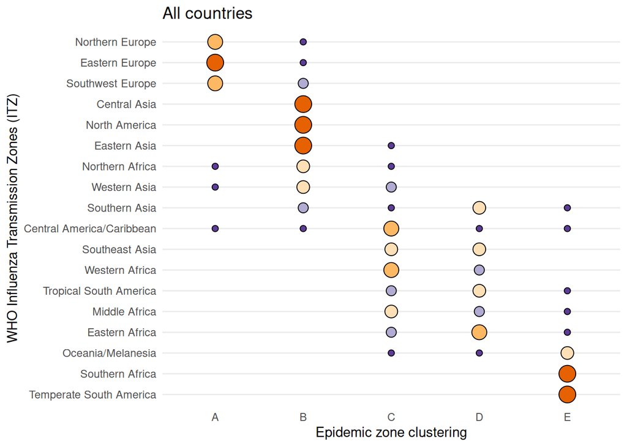

```r
library(networkD3)
library(dplyr)
library(gridExtra)
library(grid)

# Summarize how many countries are in each of the ITZ and epidemic zones... overall (then separately, I'll make one based on "original")
comparison <- combined_cluster_map %>%
  select(COUNTRY, ITZ, combined_cluster, mean_lat) %>%
  group_by(COUNTRY, ITZ, combined_cluster) %>%
  summarise(med_lat = median(mean_lat)) %>%
  #distinct() %>%
  #filter(cluster_type == "original") %>%  ### Keeping only the original countries contributing data
  filter(!is.na(ITZ)) %>% ### Keep only countries in the ITZs
  group_by(ITZ) %>%
  mutate(itzmed_lat = median(med_lat)) %>%
  group_by(ITZ, combined_cluster) %>%
  summarise(n_countries = n(),
            itzmed_lat = min(itzmed_lat)) %>%
  ungroup() %>%
  group_by(ITZ) %>%
  mutate(n_total = sum(n_countries),
         n_prop = n_countries / n_total * 100,
         n_prop_cat = factor(case_when(n_prop <=20 ~ "<=20%",
                                       n_prop > 20 & n_prop <= 40 ~ "21-40%",
                                       n_prop > 40 & n_prop <= 60 ~ "41-60%",
                                       n_prop > 60 & n_prop <= 80 ~ "61-80%",
                                       n_prop > 80 & n_prop <= 100 ~ "81-100%"),
                              levels = c("<=20%", "21-40%", "41-60%", "61-80%", "81-100%"),
                              labels = c("<=20%", "21-40%", "41-60%", "61-80%", "81-100%"))) %>%
  arrange(itzmed_lat) %>%
  mutate(itz.name = factor(case_when(ITZ == "FLU_NTH_EUR" ~ "Northern Europe",
                                     ITZ == "FLU_EST_EUR" ~ "Eastern Europe",
                                     ITZ == "FLU_CNT_ASIA" ~ "Central Asia",
                                     ITZ == "FLU_SW_EUR" ~ "Southwest Europe",
                                     ITZ == "FLU_EST_ASIA" ~ "Eastern Asia",
                                     ITZ == "FLU_NRT_AMR" ~ "North America",
                                     ITZ == "FLU_NRT_AFR" ~ "Northern Africa",
                                     ITZ == "FLU_WST_ASIA" ~ "Western Asia",
                                     ITZ == "FLU_STH_ASIA" ~ "Southern Asia",
                                     ITZ == "FLU_CNT_AMC" ~ "Central America/Caribbean",
                                     ITZ == "FLU_WST_AFR" ~ "Western Africa",
                                     ITZ == "FLU_MID_AFR" ~ "Middle Africa",
                                     ITZ == "FLU_TRP_SAMR" ~ "Tropical South America",
                                     ITZ == "FLU_SE_ASIA" ~ "Southeast Asia",
                                     ITZ == "FLU_EST_AFR" ~ "Eastern Africa",
                                     ITZ == "FLU_OCE_MEL_POL" ~ "Oceania/Melanesia",
                                     ITZ == "FLU_STH_AFR" ~ "Southern Africa",
                                     ITZ == "FLU_TEMP_SAMR" ~ "Temperate South America")))

#comparison$ITZ <- fct_reorder(comparison$ITZ, comparison$itzmed_lat)
comparison$itz.name <- fct_reorder(comparison$itz.name, comparison$itzmed_lat)


########## Countries with data included in the original analysis only

comparison_original <- combined_cluster_map %>% filter(cluster_type == "original") %>%
  select(COUNTRY, ITZ, combined_cluster, mean_lat) %>%
  group_by(COUNTRY, ITZ, combined_cluster) %>%
  summarise(med_lat = median(mean_lat)) %>%
  #distinct() %>%
  #filter(cluster_type == "original") %>%  ### Keeping only the original countries contributing data
  filter(!is.na(ITZ)) %>% ### Keep only countries in the ITZs
  group_by(ITZ) %>%
  mutate(itzmed_lat = median(med_lat)) %>%
  group_by(ITZ, combined_cluster) %>%
  summarise(n_countries = n(),
            itzmed_lat = min(itzmed_lat)) %>%
  ungroup() %>%
  group_by(ITZ) %>%
  mutate(n_total = sum(n_countries),
         n_prop = n_countries / n_total * 100,
         n_prop_cat = factor(case_when(n_prop <=20 ~ "<=20%",
                                       n_prop > 20 & n_prop <= 40 ~ "21-40%",
                                       n_prop > 40 & n_prop <= 60 ~ "41-60%",
                                       n_prop > 60 & n_prop <= 80 ~ "61-80%",
                                       n_prop > 80 & n_prop <= 100 ~ "81-100%"),
                              levels = c("<=20%", "21-40%", "41-60%", "61-80%", "81-100%"),
                              labels = c("<=20%", "21-40%", "41-60%", "61-80%", "81-100%"))) %>%
  arrange(itzmed_lat) %>%
  mutate(itz.name = factor(case_when(ITZ == "FLU_NTH_EUR" ~ "Northern Europe",
                                     ITZ == "FLU_EST_EUR" ~ "Eastern Europe",
                                     ITZ == "FLU_CNT_ASIA" ~ "Central Asia",
                                     ITZ == "FLU_SW_EUR" ~ "Southwest Europe",
                                     ITZ == "FLU_EST_ASIA" ~ "Eastern Asia",
                                     ITZ == "FLU_NRT_AMR" ~ "North America",
                                     ITZ == "FLU_NRT_AFR" ~ "Northern Africa",
                                     ITZ == "FLU_WST_ASIA" ~ "Western Asia",
                                     ITZ == "FLU_STH_ASIA" ~ "Southern Asia",
                                     ITZ == "FLU_CNT_AMC" ~ "Central America/Caribbean",
                                     ITZ == "FLU_WST_AFR" ~ "Western Africa",
                                     ITZ == "FLU_MID_AFR" ~ "Middle Africa",
                                     ITZ == "FLU_TRP_SAMR" ~ "Tropical South America",
                                     ITZ == "FLU_SE_ASIA" ~ "Southeast Asia",
                                     ITZ == "FLU_EST_AFR" ~ "Eastern Africa",
                                     ITZ == "FLU_OCE_MEL_POL" ~ "Oceania/Melanesia",
                                     ITZ == "FLU_STH_AFR" ~ "Southern Africa",
                                     ITZ == "FLU_TEMP_SAMR" ~ "Temperate South America")))

#comparison_original$ITZ <- fct_reorder(comparison_original$ITZ, comparison_original$itzmed_lat)
comparison_original$itz.name <- fct_reorder(comparison_original$itz.name, comparison_original$itzmed_lat)



# Make a connection data frame
# links <- data.frame(
#   source=c("group_A","group_A", "group_B", "group_C", "group_C", "group_E"),
#   target=c("group_C","group_D", "group_E", "group_F", "group_G", "group_H"),
#   value=c(2,3, 2, 3, 1, 3)
# )
#
# # From these flows we need to create a node data frame: it lists every entities involved in the flow
# nodes <- data.frame(
#   name=c(as.character(comparison$ITZ), as.character(comparison$combined_cluster)) %>%
#     unique()
# )
#
# # With networkD3, connection must be provided using id, not using real name like in the links dataframe.. So we need to reformat it.
# comparison$ID.ITZ     <- match(comparison$ITZ, nodes$name)-1
# comparison$ID.cluster <- match(comparison$combined_cluster, nodes$name)-1
#
# # prepare color scale: I give one specific color for each node.
# my_color <- 'd3.scaleOrdinal() .domain(["group_A", "group_B","group_C", "group_D", "group_E", "group_F", "group_G", "group_H"]) .range(["blue", "blue" , "blue", "red", "red", "yellow", "purple", "purple"])'
#
# # Make the Network. I call my colour scale with the colourScale argument
# sankey <- sankeyNetwork(Links = comparison, Nodes = nodes, Source = "ID.ITZ", Target = "ID.cluster",
#               Value = "n_countries", NodeID = "name" ) #, colourScale=my_color)
# sankey


########################################################
### Alternative visual

itz_comparison <- ggplot(comparison, aes(x = combined_cluster, y = itz.name,
                       size = factor(n_prop_cat),
                       fill = factor(n_prop_cat))) +
  geom_point(shape = 21, color = "black") +
  #scale_size_manual() + # Adjust maximum balloon size
  scale_fill_manual(values = c("#5e3c99", "#b2abd2", "#fee0b6", "#fdb863","#e66101")) +
  labs(title = "All countries",
       x = "Epidemic zone clustering",
       y = "WHO Influenza Transmission Zones (ITZ)",
       size = "Proportion of ITZ assigned",
       fill = "Proportion of ITZ assigned") +
  theme_minimal() +
  theme(legend.position = "none",
        panel.grid.major.x = element_blank())

itz_comparison
```

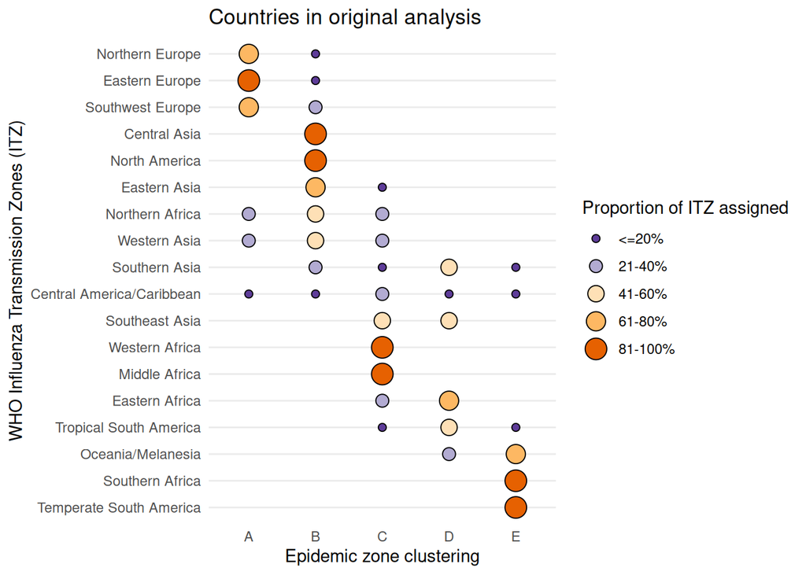

```r
ggsave("plots/cluster_vs_itz_allcountries.pdf", itz_comparison, units = "in", width = 11, height = 8.5)



#### original analysis countries only
itz_comparison_orig <- ggplot(comparison_original, aes(x = combined_cluster, y = itz.name,
                       size = factor(n_prop_cat),
                       fill = factor(n_prop_cat))) +
  geom_point(shape = 21, color = "black") +
  #scale_size_manual() + # Adjust maximum balloon size
  scale_fill_manual(values = c("#5e3c99", "#b2abd2", "#fee0b6", "#fdb863","#e66101")) +
  labs(title = "Countries in original analysis",
       x = "Epidemic zone clustering",
       y = "WHO Influenza Transmission Zones (ITZ)",
       size = "Proportion of ITZ assigned",
       fill = "Proportion of ITZ assigned") +
  theme_minimal() +
  theme(#axis.title.y = element_blank(),
        panel.grid.major.x = element_blank())

itz_comparison_orig
```

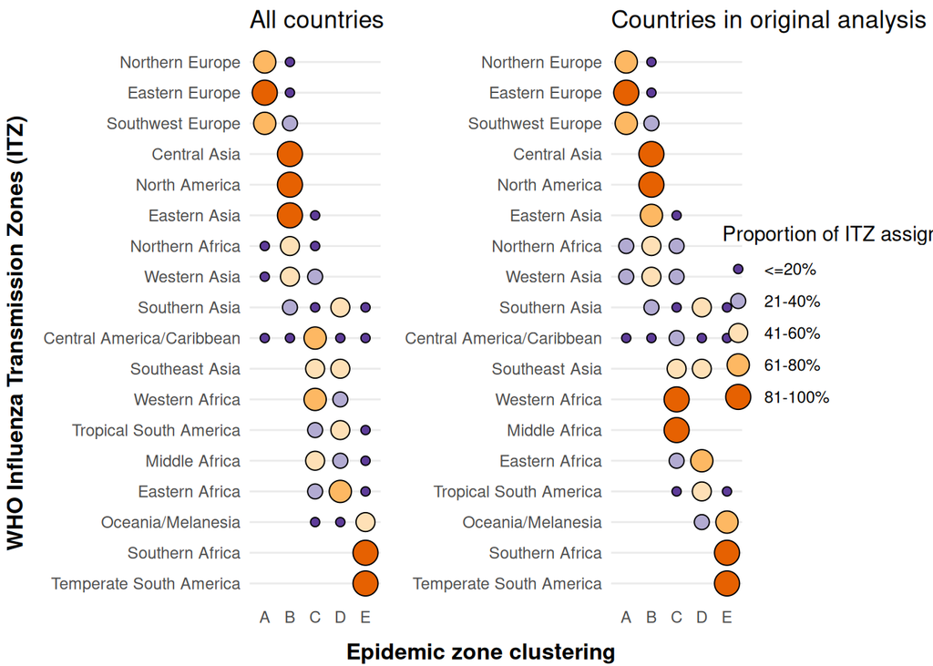

```r
ggsave("plots/cluster_vs_itz_originalcountries.pdf", itz_comparison_orig, units = "in", width = 11, height = 8.5)

### Combined

itz_leg <- ggpubr::as_ggplot(ggpubr::get_legend(itz_comparison_orig))

combo_comparison_plot <- plot_grid(itz_comparison +
                                     theme(axis.title = element_blank(), axis.title.y=element_blank()),
                                   itz_comparison_orig +
                                     theme(axis.title = element_blank(), axis.title.y=element_blank(),
                                           legend.position = "none"),
                                   itz_leg,
                                   ncol = 3, rel_widths = c(1, 1, 0.5))

# create common x and y labels
y.grob <- textGrob("WHO Influenza Transmission Zones (ITZ)",
                   gp=gpar(fontface="bold", col="black", fontsize=12), rot=90)

x.grob <- textGrob("Epidemic zone clustering",
                   gp=gpar(fontface="bold", col="black", fontsize=12))

# add labels to plot
ggsave("plots/cluster_vs_itz_combined.pdf",
       grid.arrange(arrangeGrob(combo_comparison_plot, left = y.grob, bottom = x.grob)),
       units = "in", width = 11, height = 8.5)
```

Comparison of countries in Africa, which have WHO ITZs, “pattern assignments” from Igboh, et al. (Igboh et al. 2023), and Epidemic zones from this clustering.

```r
afro_comparison0 <- combined_cluster_map %>%
  filter(cluster_type == "original") %>%  select(-ITZ) %>% left_join(., itz_co, by = c("COUNTRY"))

afro_comparison <- afro_comparison0 %>%
  select(COUNTRY, ITZ, combined_cluster, mean_lat, afro_pattern) %>%
  filter(!is.na(afro_pattern)) %>%
    mutate(itz.name = factor(case_when(ITZ == "FLU_NTH_EUR" ~ "Northern Europe",
                                     ITZ == "FLU_EST_EUR" ~ "Eastern Europe",
                                     ITZ == "FLU_CNT_ASIA" ~ "Central Asia",
                                     ITZ == "FLU_SW_EUR" ~ "Southwest Europe",
                                     ITZ == "FLU_EST_ASIA" ~ "Eastern Asia",
                                     ITZ == "FLU_NRT_AMR" ~ "North America",
                                     ITZ == "FLU_NRT_AFR" ~ "Northern Africa",
                                     ITZ == "FLU_WST_ASIA" ~ "Western Asia",
                                     ITZ == "FLU_STH_ASIA" ~ "Southern Asia",
                                     ITZ == "FLU_CNT_AMC" ~ "Central America/Caribbean",
                                     ITZ == "FLU_WST_AFR" ~ "Western Africa",
                                     ITZ == "FLU_MID_AFR" ~ "Middle Africa",
                                     ITZ == "FLU_TRP_SAMR" ~ "Tropical South America",
                                     ITZ == "FLU_SE_ASIA" ~ "Southeast Asia",
                                     ITZ == "FLU_EST_AFR" ~ "Eastern Africa",
                                     ITZ == "FLU_OCE_MEL_POL" ~ "Oceania/Melanesia",
                                     ITZ == "FLU_STH_AFR" ~ "Southern Africa",
                                     ITZ == "FLU_TEMP_SAMR" ~ "Temperate South America"))) %>%
  arrange(-mean_lat) %>% distinct()

afro_tibble <- afro_comparison %>% select(COUNTRY, combined_cluster, itz.name, afro_pattern) %>%
  kable(format = "html",
        col.names = c("Country", "Epidemic zone", "Influenza transmission zone", "Influenza pattern")) %>%
  kable_styling(bootstrap_options = c("striped", "hover", "condensed"),
                full_width = FALSE)

afro_tibble
```

| Country | Epidemic zone | Influenza transmission zone | Influenza pattern |
| --- | --- | --- | --- |
| Tunisia | A | Northern Africa | NH |
| Algeria | B | Northern Africa | NH |
| Morocco | B | Northern Africa | NH |
| Egypt | C | Northern Africa | NH |
| Senegal | C | Western Africa | NH, some SH |
| Ethiopia | C | Eastern Africa | NH, some SH |
| Togo | C | Western Africa | NH, some SH |
| Ghana | C | Western Africa | SH, some NH |
| Cameroon | C | Middle Africa | NH, some SH |
| Kenya | D | Eastern Africa | SH, some NH |
| Congo (DRC) | C | Middle Africa | not clear |
| Tanzania | C | Eastern Africa | NH, some SH |
| Zambia | D | Eastern Africa | SH |
| Madagascar | D | Eastern Africa | not clear |
| Mauritius | D | Eastern Africa | not clear |
| South Africa | E | Southern Africa | SH |

## 8. Code in preparation for Supplementary Tables and descriptive statistics in the Results

### Supplementary table, outlining peak season by quarter, partition, and filtering criteria

```r
##Supplementary table 1, outlining peak season by quarter, partition, and filtering criteria
co_sy_supp1 <- co_cat %>% dplyr::select(-inf_all_dist) %>%
  filter(max_season %in% c("Fall", "Winter")) %>%
  mutate(max_season = case_when(max_season == "Winter" ~ "Q1",
                                max_season == "Spring" ~ "Q2",
                                max_season == "Summer" ~ "Q3",
                                max_season == "Fall" ~ "Q4"),
         window = ifelse(max_season %in% c("Q1", "Q4"), "Shifted year", "Calendar year")) %>%
  select(COUNTRY, max_season, window) %>%
  unique()

co_cy_supp1 <- co_cat %>% dplyr::select(-inf_all_dist) %>%
  filter(max_season %in% c("Spring", "Summer")) %>%
  mutate(max_season = case_when(max_season == "Winter" ~ "Q1",
                                max_season == "Spring" ~ "Q2",
                                max_season == "Summer" ~ "Q3",
                                max_season == "Fall" ~ "Q4"),
         window = ifelse(max_season %in% c("Q1", "Q4"), "Shifted year", "Calendar year")) %>%
    select(COUNTRY, max_season, window) %>%
  unique()

co_supp1 <- rbind(co_sy_supp1, co_cy_supp1) %>%
  arrange(COUNTRY) %>%
  left_join(tbl_exclusions2, by = "COUNTRY") %>%
  mutate(total = ifelse(is.na(total), 0, total))



co_supp1_headers <- co_supp1 %>%
  select(COUNTRY, max_season, window, flag_100detections_sum, flag_fewweeks_sum, total, flag_matrixpass,
         sequential_flags) %>%
  rename(Country = COUNTRY,
         "Calendar quarter (Q) in which most influenza virus detections occurred" = max_season,
         "Time window used for analysis" = window,
         "Number of time windows with \u2265100 detections" = flag_100detections_sum,
         "Number of time windows with data for \u226540% of weeks" = flag_fewweeks_sum,
         "Number of complete time windows available for analysis" = total,
         "Country cross-comparison matrix time window* available for analysis" = flag_matrixpass,
         "Inclusion\u271D into clustering analysis" = sequential_flags) #,
         #"Country included in clustering analysis (No/Yes) *" = incl_clust)

write.csv(co_supp1_headers, "data/supplemental_table1_availabledata.csv")
```

### Supplementary table

Regional and sub-regional groupings used in the country-level summaries below follow the UN Statistics Division’s M49 standard country classification (United Nations Statistics Division, n.d.).

```r
##Descriptive analyses of country clusters

#If starting anew, pull in saved final tsv file
#combined_cluster_map <- read_tsv("data/co_cluster_mapping.tsv")

#Import UN geoschemes to use as regional unit of analysis
un <- read_csv("data/UNSD_geoschemes.csv") %>%
  rename(REGION = `Region Name`,
         SUBREGION = `Sub-region Name`,
         INTREGION = `Intermediate Region Name`,
         COUNTRY = `Country or Area`,
         COUNTRY_CODE = `ISO-alpha3 Code`) %>%
  select(REGION, SUBREGION, INTREGION, COUNTRY_CODE, COUNTRY) %>%
  mutate(INTREGION = ifelse(is.na(INTREGION), SUBREGION, INTREGION))

# Align UN and cluster map datasets to maximize geographic coverage
combined_cluster_map_data_1 <- combined_cluster_map %>%
  mutate(COUNTRY_CODE = case_when(COUNTRY == "Chagos Archipelago" ~ "IOT",
                                  COUNTRY %in% c("Saba", "Sint Eustatius", "Bonaire") ~ "BES",
                                  COUNTRY == "Heard Island" ~ "HMD",
                                  TRUE ~ COUNTRY_CODE)) %>%
  filter(!COUNTRY %in% c("Bonaire", "Saba")) %>%
  mutate(COUNTRY = case_when(COUNTRY_CODE == "BES" ~ "Bonaire, Sint Eustatius and Saba",
                             COUNTRY_CODE == "HMD" ~ "Heard Island and McDonald Islands",
                             TRUE ~ COUNTRY))

clusters <- un %>%
  full_join(combined_cluster_map_data_1, by = "COUNTRY_CODE") %>%
  select(-c(COUNTRY.x, SUBREGION)) %>%
  rename(COUNTRY = COUNTRY.y) %>%
  mutate(REGION = case_when(COUNTRY == "Kosovo" ~ "Europe",
                            COUNTRY =="Taiwan" ~ "Asia",
                            TRUE ~ REGION),
         INTREGION = case_when(COUNTRY %in% c("Kosovo") ~ "Southern Europe",
                               COUNTRY %in% c("Azores", "Madeira Islands", "Canary Islands") ~ "Macaronesia",
                               COUNTRY == "Taiwan" ~ "Eastern Asia",
                               TRUE ~ INTREGION),
         COUNTRY = case_when(COUNTRY_CODE == "MAC" ~ "China, Macao Special Administrative Region",
                             COUNTRY_CODE == "ALA" ~ "Åland Islands",
                             COUNTRY_CODE == "SJM" ~ "Svalbard and Jan Mayen Islands",
                             COUNTRY_CODE == "GIB" ~ "Gibraltar",
                             COUNTRY_CODE == "TKL" ~ "Tokelau",
                             COUNTRY_CODE == "TUV" ~ "Tuvalu",
                             COUNTRY_CODE == "UMI" ~ "United States Minor Outlying Islands",
                             TRUE ~ COUNTRY),
         combined_cluster = case_when(COUNTRY_CODE == "MAC" ~ "B", #felt comfortable manually coding these territories since they are
                                     COUNTRY_CODE %in% c("ALA", "SJM", "GIB") ~ "A", # within countries with original assigned zones
                                     TRUE ~ combined_cluster),
         cluster_type = ifelse(COUNTRY_CODE %in% c("MAC", "ALA", "SJM", "GIB", "UMI", "TUV", "TKL"), "proxy", cluster_type)) %>%
  filter(!COUNTRY %in% c("Siachen Glacier", "Ascension Island", "Barbuda", "Grenadines")) %>%
  filter(!COUNTRY_CODE %in% c("BVT"))
```

### Final map

Final map for the manuscript (excludes out and combines some minor outlying islands)

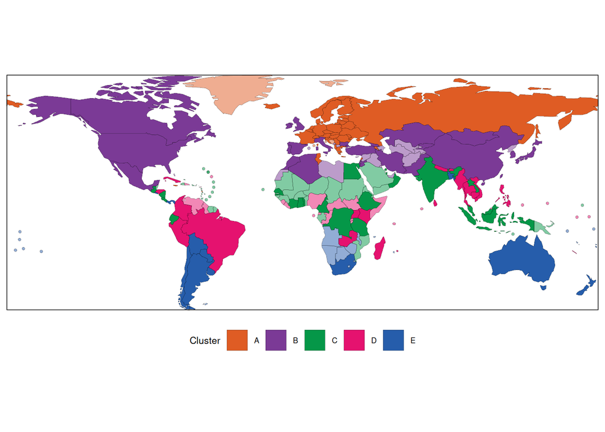

```r
# Combined Map Plot With Proxied Countries (alpha is determined by whether it was proxied or not)

### uses dataset "clusters" which resolves the outerlying islands and UN designations, etc.
combined_map_plot_alpha <- ggplot(combined_cluster_map_who, aes(data_id = COUNTRY_CLEAN)) +
  geom_sf(data = combined_cluster_map_who,
          fill="white", color="white", size = 0.1) +
  ggiraph::geom_sf_interactive(data = combined_cluster_map_who,
                               aes(fill = combined_cluster,
                                   alpha = cluster_type,
                                   tooltip = paste(COUNTRY_CLEAN, combined_cluster, cluster_type, sep = "\n"),
                                   data_id = COUNTRY_CLEAN),
                               size = 0.05, color="black") +
  coord_sf(expand = FALSE) +
  theme(legend.position="bottom",
        panel.grid.major = element_blank(),
        panel.grid.minor = element_blank(),
        panel.border = element_rect(color = "black", fill = NA),
        panel.background = element_blank(),
        axis.title.x=element_blank(),
        axis.text.x=element_blank(),
        axis.ticks.x=element_blank(),
        axis.title.y=element_blank(),
        axis.text.y=element_blank(),
        axis.ticks.y=element_blank(),
        text = element_text(size = 8)) +
  guides(fill = guide_legend(nrow = 1)) +
  scale_color_manual(values = c("A" = "#DF5C24",
                                "B" = "#7B3A96",
                                "C" = "#059748",
                                "D" = "#E5126F",
                                "E" = "#265DAB"),
                     breaks = c("A","B","C","D","E")) +
  scale_fill_manual(values = c("A" = "#DF5C24",
                               "B" = "#7B3A96",
                               "C" = "#059748",
                               "D" = "#E5126F",
                               "E" = "#265DAB"),
                    breaks = c("A","B","C","D","E")) +
    scale_alpha_manual(values = c(1, 0.5),
                       breaks = c("original", "proxy"),
                       guide="none") +
  guides(color=guide_legend(title="Cluster"),
         fill=guide_legend(title="Cluster"))

combined_map_plot_alpha
```

```r
ggsave("plots/map_alphabyclustertype.pdf", combined_map_plot_alpha, units = "in", width = 11, height = 8.5)
```

```r
### Supplemental table:
### - Country
### - Population-weighted mean latitude
### - Epidemic zone assignment
### - Epidemic zone was based on original analysis or proxy
### - Calendar weeks in which most influenza detections occurred
orig_co_activityrange <- epidemic_thresholds_co %>% ungroup() %>%
  mutate(orig_range = paste0(month.name[epidemic_start_month], "-", month.name[epidemic_end_month])) %>%
  select(COUNTRY, orig_range)

proxy_co_activityrange <- epidemic_thresholds %>% ungroup() %>%
  mutate(proxy_range = paste0(month.name[epidemic_start_month], "-", month.name[epidemic_end_month])) %>%
  select(combined_cluster, proxy_range)


supp_tbl2_clusterlatrange <- clusters %>%
  select(COUNTRY, mean_lat, cluster_type, combined_cluster) %>%
  left_join(., orig_co_activityrange, by = "COUNTRY") %>%
  left_join(., proxy_co_activityrange, by = "combined_cluster") %>%
  distinct() %>%
  mutate(month_range = case_when(cluster_type == "original" ~ orig_range,
                                 cluster_type == "proxy" ~ paste0("[",proxy_range, "]")))  %>%
  arrange(combined_cluster, -mean_lat) %>%
  left_join(tbl_exclusions2, by = "COUNTRY")

write.csv(supp_tbl2_clusterlatrange, "data/supp_table2_co_latcluster.csv")
```

Table of sub-regions in each cluster. This helps us populate the Results section of the manuscript. There are 2 tables made: one for original analysis and one for the proxy countries.

*Original countries:*

```r
### Dealing with original analysis countries first

original_regions <- clusters %>% filter(cluster_type == "original") %>%
  select(combined_cluster, COUNTRY, INTREGION, mean_lat) %>% distinct() %>%
  mutate(INTREGION = factor(INTREGION))

original_regions$INTREGION <- fct_reorder(original_regions$INTREGION, -original_regions$mean_lat)

original_regions %>%
  select(-COUNTRY, -mean_lat) %>%
  tbl_summary(by = combined_cluster,
              statistic = all_categorical() ~ "{n} ({p}%)")
```

| **Characteristic** | **A** N = 34<sup>1</sup> | **B** N = 24<sup>1</sup> | **C** N = 22<sup>1</sup> | **D** N = 19<sup>1</sup> | **E** N = 12<sup>1</sup> |
| --- | --- | --- | --- | --- | --- |
| INTREGION |  |  |  |  |  |
| Northern Europe | 8 (24%) | 2 (8.3%) | 0 (0%) | 0 (0%) | 0 (0%) |
| Western Europe | 7 (21%) | 0 (0%) | 0 (0%) | 0 (0%) | 0 (0%) |
| Eastern Europe | 9 (26%) | 1 (4.2%) | 0 (0%) | 0 (0%) | 0 (0%) |
| Central Asia | 0 (0%) | 2 (8.3%) | 0 (0%) | 0 (0%) | 0 (0%) |
| Northern America | 0 (0%) | 2 (8.3%) | 0 (0%) | 0 (0%) | 0 (0%) |
| Southern Europe | 5 (15%) | 4 (17%) | 0 (0%) | 0 (0%) | 0 (0%) |
| Eastern Asia | 0 (0%) | 4 (17%) | 1 (4.5%) | 0 (0%) | 0 (0%) |
| Northern Africa | 1 (2.9%) | 2 (8.3%) | 1 (4.5%) | 0 (0%) | 0 (0%) |
| Western Asia | 2 (5.9%) | 4 (17%) | 3 (14%) | 0 (0%) | 0 (0%) |
| Southern Asia | 0 (0%) | 2 (8.3%) | 1 (4.5%) | 3 (16%) | 1 (8.3%) |
| Caribbean | 2 (5.9%) | 0 (0%) | 0 (0%) | 1 (5.3%) | 0 (0%) |
| Central America | 0 (0%) | 1 (4.2%) | 3 (14%) | 1 (5.3%) | 2 (17%) |
| South-eastern Asia | 0 (0%) | 0 (0%) | 4 (18%) | 5 (26%) | 0 (0%) |
| Western Africa | 0 (0%) | 0 (0%) | 4 (18%) | 0 (0%) | 0 (0%) |
| Middle Africa | 0 (0%) | 0 (0%) | 2 (9.1%) | 0 (0%) | 0 (0%) |
| Eastern Africa | 0 (0%) | 0 (0%) | 2 (9.1%) | 5 (26%) | 0 (0%) |
| South America | 0 (0%) | 0 (0%) | 1 (4.5%) | 3 (16%) | 5 (42%) |
| Melanesia | 0 (0%) | 0 (0%) | 0 (0%) | 1 (5.3%) | 1 (8.3%) |
| Southern Africa | 0 (0%) | 0 (0%) | 0 (0%) | 0 (0%) | 1 (8.3%) |
| Australia and New Zealand | 0 (0%) | 0 (0%) | 0 (0%) | 0 (0%) | 2 (17%) |

<sup>1</sup> n (%)

*Proxy countries:*

```r
### Dealing with countries assigned to cluster by proxy

proxy_regions <- clusters %>% filter(cluster_type == "proxy") %>%
  select(combined_cluster, COUNTRY, INTREGION, mean_lat) %>% distinct() %>%
  mutate(INTREGION = factor(INTREGION))

proxy_regions$INTREGION <- fct_reorder(proxy_regions$INTREGION, -proxy_regions$mean_lat)

proxy_regions %>%
  select(-COUNTRY, -mean_lat) %>%
  tbl_summary(by = combined_cluster,
              statistic = all_categorical() ~ "{n} ({p}%)")
```

| **Characteristic** | **A** N = 13<sup>1</sup> | **B** N = 25<sup>1</sup> | **C** N = 49<sup>1</sup> | **D** N = 22<sup>1</sup> | **E** N = 33<sup>1</sup> |
| --- | --- | --- | --- | --- | --- |
| INTREGION |  |  |  |  |  |
| Northern Europe | 6 (46%) | 0 (0%) | 0 (0%) | 0 (0%) | 0 (0%) |
| Northern America | 2 (15%) | 1 (4.0%) | 0 (0%) | 0 (0%) | 0 (0%) |
| Western Europe | 2 (15%) | 0 (0%) | 0 (0%) | 0 (0%) | 0 (0%) |
| Southern Europe | 3 (23%) | 5 (20%) | 0 (0%) | 0 (0%) | 0 (0%) |
| Central Asia | 0 (0%) | 3 (12%) | 0 (0%) | 0 (0%) | 0 (0%) |
| Macaronesia | 0 (0%) | 3 (12%) | 0 (0%) | 0 (0%) | 0 (0%) |
| Eastern Asia | 0 (0%) | 2 (8.0%) | 1 (2.0%) | 0 (0%) | 0 (0%) |
| Western Asia | 0 (0%) | 7 (28%) | 2 (4.1%) | 0 (0%) | 0 (0%) |
| Northern Africa | 0 (0%) | 2 (8.0%) | 1 (2.0%) | 0 (0%) | 0 (0%) |
| Southern Asia | 0 (0%) | 1 (4.0%) | 0 (0%) | 1 (4.5%) | 0 (0%) |
| Central America | 0 (0%) | 0 (0%) | 1 (2.0%) | 0 (0%) | 0 (0%) |
| Caribbean | 0 (0%) | 1 (4.0%) | 23 (47%) | 2 (9.1%) | 0 (0%) |
| Western Africa | 0 (0%) | 0 (0%) | 9 (18%) | 3 (14%) | 1 (3.1%) |
| Micronesia | 0 (0%) | 0 (0%) | 3 (6.1%) | 4 (18%) | 0 (0%) |
| South America | 0 (0%) | 0 (0%) | 2 (4.1%) | 2 (9.1%) | 3 (9.4%) |
| Middle Africa | 0 (0%) | 0 (0%) | 2 (4.1%) | 4 (18%) | 1 (3.1%) |
| South-eastern Asia | 0 (0%) | 0 (0%) | 1 (2.0%) | 1 (4.5%) | 0 (0%) |
| Eastern Africa | 0 (0%) | 0 (0%) | 3 (6.1%) | 5 (23%) | 7 (22%) |
| Melanesia | 0 (0%) | 0 (0%) | 1 (2.0%) | 0 (0%) | 2 (6.3%) |
| Polynesia | 0 (0%) | 0 (0%) | 0 (0%) | 0 (0%) | 10 (31%) |
| Australia and New Zealand | 0 (0%) | 0 (0%) | 0 (0%) | 0 (0%) | 4 (13%) |
| Southern Africa | 0 (0%) | 0 (0%) | 0 (0%) | 0 (0%) | 4 (13%) |
| Unknown | 0 | 0 | 0 | 0 | 1 |

<sup>1</sup> n (%)

```r
#Original countries
clust_ori <- clusters %>%
  filter(cluster_type == 'original') %>%
  distinct()

sy1 <- clust_ori %>%
  filter(combined_cluster == "A")

sy1 %>%
  group_by(REGION) %>%
  summarise(countries = n()) %>%
  mutate(per_countries = 100*countries/sum(countries)) %>%
  view()

sy1 %>%
  group_by(REGION, INTREGION) %>%
  summarise(countries = n()) %>%
  mutate(per_countries = 100*countries/sum(countries)) %>%
  view()

sy1 %>%
  filter(mean_lat > 0) %>%
  view()


sy2 <- clust_ori %>%
  filter(combined_cluster == "B")

sy2 %>%
  group_by(REGION) %>%
  summarise(countries = n()) %>%
  mutate(per_countries = 100*countries/sum(countries)) %>%
  view()

sy2 %>%
  group_by(REGION, INTREGION) %>%
  summarise(countries = n()) %>%
  mutate(per_countries = 100*countries/sum(countries)) %>%
  view()

sy2 %>%
  filter(mean_lat > 0) %>%
  view()


sy3 <- clust_ori %>%
  filter(combined_cluster == "C")

sy3 %>%
  group_by(REGION) %>%
  summarise(countries = n()) %>%
  mutate(per_countries = 100*countries/sum(countries)) %>%
  view()

sy3 %>%
  group_by(REGION, INTREGION) %>%
  summarise(countries = n()) %>%
  mutate(per_countries = 100*countries/sum(countries)) %>%
  view()

sy3 %>%
  filter(mean_lat <= 23.5 & mean_lat >= -23.5) %>%
  view()


cy1 <- clust_ori %>%
  filter(combined_cluster == "E")

cy1 %>%
  group_by(REGION) %>%
  summarise(countries = n()) %>%
  mutate(per_countries = 100*countries/sum(countries)) %>%
  view()

cy1 %>%
  group_by(REGION, INTREGION) %>%
  summarise(countries = n()) %>%
  mutate(per_countries = 100*countries/sum(countries)) %>%
  view()

cy1 %>%
  filter(mean_lat < 0) %>%
  view()

cy2 <- clust_ori %>%
  filter(combined_cluster == "D")

cy2 %>%
  group_by(REGION) %>%
  summarise(countries = n()) %>%
  mutate(per_countries = 100*countries/sum(countries)) %>%
  view()

cy2 %>%
  group_by(REGION, INTREGION) %>%
  summarise(countries = n()) %>%
  mutate(per_countries = 100*countries/sum(countries)) %>%
  view()

cy2 %>%
  filter(mean_lat < 0) %>%
  view()


#Proxied countries
clust_pro <- clusters %>%
  filter(cluster_type == 'proxy') %>%
  distinct()

clust_pro %>%
  group_by(REGION) %>%
  summarise(countries = n()) %>%
  mutate(per_countries = 100*countries/sum(countries)) %>%
  view()


sy1_pro <- clust_pro %>%
  filter(combined_cluster == "A")

sy1_pro %>%
  group_by(REGION) %>%
  summarise(countries = n()) %>%
  mutate(per_countries = 100*countries/sum(countries)) %>%
  view()

sy1_pro %>%
  group_by(REGION, INTREGION) %>%
  summarise(countries = n()) %>%
  mutate(per_countries = 100*countries/sum(countries)) %>%
  view()

sy1_pro %>%
  filter(mean_lat > 0) %>%
  view()


sy2_pro <- clust_pro %>%
  filter(combined_cluster == "B")

sy2_pro %>%
  group_by(REGION) %>%
  summarise(countries = n()) %>%
  mutate(per_countries = 100*countries/sum(countries)) %>%
  view()

sy2_pro %>%
  group_by(REGION, INTREGION) %>%
  summarise(countries = n()) %>%
  mutate(per_countries = 100*countries/sum(countries)) %>%
  view()

sy2_pro %>%
  filter(mean_lat > 0) %>%
  view()


sy3_pro <- clust_pro %>%
  filter(combined_cluster == "C")

sy3_pro %>%
  group_by(REGION) %>%
  summarise(countries = n()) %>%
  mutate(per_countries = 100*countries/sum(countries)) %>%
  view()

sy3_pro %>%
  group_by(REGION, INTREGION) %>%
  summarise(countries = n()) %>%
  mutate(per_countries = 100*countries/sum(countries)) %>%
  view()

sy3_pro %>%
  filter(mean_lat <= 23.5 & mean_lat >= -23.5) %>%
  view()


cy1_pro <- clust_pro %>%
  filter(combined_cluster == "E")

cy1_pro %>%
  group_by(REGION) %>%
  summarise(countries = n()) %>%
  mutate(per_countries = 100*countries/sum(countries)) %>%
  view()

cy1_pro %>%
  group_by(REGION, INTREGION) %>%
  summarise(countries = n()) %>%
  mutate(per_countries = 100*countries/sum(countries)) %>%
  view()

cy1_pro %>%
  filter(mean_lat < 0) %>%
  view()


cy2_pro <- clust_pro %>%
  filter(combined_cluster == "D")

cy2_pro %>%
  group_by(REGION) %>%
  summarise(countries = n()) %>%
  mutate(per_countries = 100*countries/sum(countries)) %>%
  view()

cy2_pro %>%
  group_by(REGION, INTREGION) %>%
  summarise(countries = n()) %>%
  mutate(per_countries = 100*countries/sum(countries)) %>%
  view()

cy2_pro %>%
  filter(mean_lat < 0) %>%
  view()
```

**Final Figure 2:**

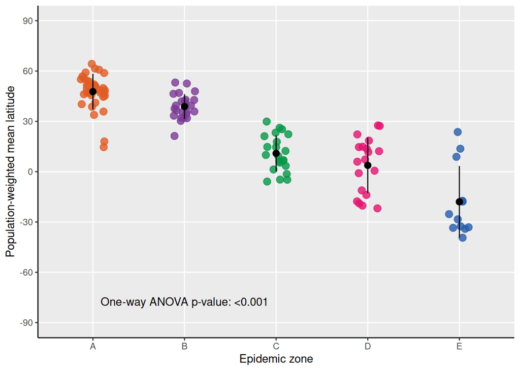

```r
figure_2 <- dat.temp %>%
ggplot(aes(x = combined_cluster, y = mean_lat, group = combined_cluster)) +
  geom_jitter(aes(color = combined_cluster),
              size = 3, alpha = 0.8, position = position_jitterdodge()) +
  stat_summary(
    fun.data = "mean_sdl", fun.args = list(mult = 1), #
    position = position_dodge(width = .75)
  ) +
  scale_color_manual(values = c("A" = "#DF5C24",
                                "B" = "#7B3A96",
                                "C" = "#059748",
                                "D" = "#E5126F",
                                "E" = "#265DAB"),
                     breaks = c("A","B","C","D","E")) +
  scale_y_continuous(limits = c(-90, 90), breaks = c(-90, -60, -30, 0, 30, 60, 90)) +
  labs(y = "Population-weighted mean latitude",
       x = "Epidemic zone") +
  annotate("text", x = "B", y = -85,
           label = paste0("One-way ANOVA p-value: ", anova_lat_p_value), vjust = -1) +
  theme(panel.grid.minor = element_blank(),
        axis.line = element_line(colour = "black"),
        legend.position="none")

figure_2
```

```r
ggsave("plots/figure_2.pdf", figure_2, units = "in", width = 9, height = 6)
```

**Final Figure 3:**

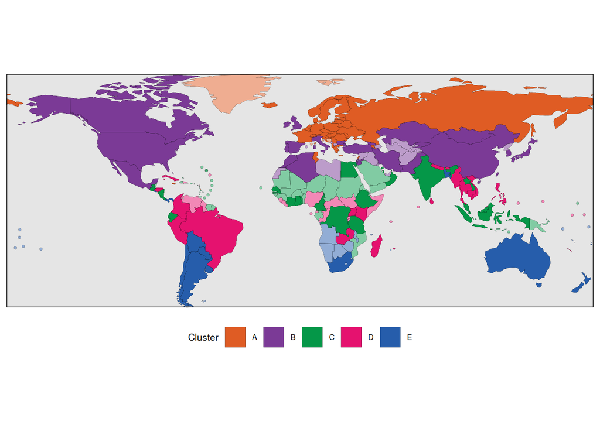

```r
figure_3 <- ggplot(combined_cluster_map_who, aes(data_id = COUNTRY_CLEAN)) +
  geom_sf(data = combined_cluster_map_who,
          fill="white", color="white", size = 0.1) +
  ggiraph::geom_sf_interactive(data = combined_cluster_map_who,
                               aes(fill = combined_cluster,
                                   alpha = cluster_type,
                                   tooltip = paste(COUNTRY_CLEAN, combined_cluster, cluster_type, sep = "\n"),
                                   data_id = COUNTRY_CLEAN),
                               size = 0.05, color="black") +
  coord_sf(expand = FALSE) +
  theme(legend.position="bottom",
        panel.grid.major = element_blank(),
        panel.grid.minor = element_blank(),
        panel.border = element_rect(color = "black", fill = NA),
        panel.background = element_rect(fill = "#E5E5E5"),
        axis.title.x=element_blank(),
        axis.text.x=element_blank(),
        axis.ticks.x=element_blank(),
        axis.title.y=element_blank(),
        axis.text.y=element_blank(),
        axis.ticks.y=element_blank(),
        text = element_text(size = 8)) +
  guides(fill = guide_legend(nrow = 1)) +
  scale_color_manual(values = c("A" = "#DF5C24",
                                "B" = "#7B3A96",
                                "C" = "#059748",
                                "D" = "#E5126F",
                                "E" = "#265DAB"),
                     breaks = c("A","B","C","D","E")) +
  scale_fill_manual(values = c("A" = "#DF5C24",
                               "B" = "#7B3A96",
                               "C" = "#059748",
                               "D" = "#E5126F",
                               "E" = "#265DAB"),
                    breaks = c("A","B","C","D","E")) +
    scale_alpha_manual(values = c(1, 0.5),
                       breaks = c("original", "proxy"),
                       guide="none") +
  guides(color=guide_legend(title="Cluster"),
         fill=guide_legend(title="Cluster"))

figure_3
```

```r
ggsave("plots/figure_3.pdf", figure_3, units = "in", width = 9.5, height = 4.5)
```

**Final Figure 4:**

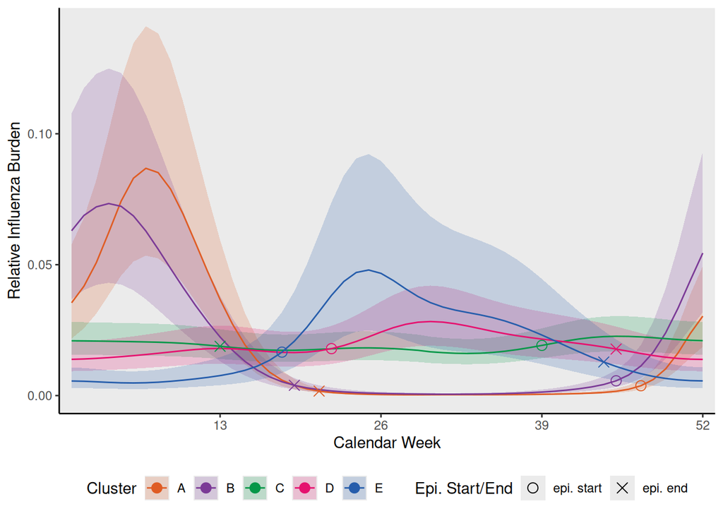

```r
inf_cluster_gam_plot
```

```r
ggsave("plots/figure_4.pdf", inf_cluster_gam_plot, units = "in", height = 6, width = 9)
```

**Supplementary Figure 1:**

Calendar year partition:

```r
# plot out INF_ALL poisson vs. negative binomial gam fits against raw data
s1_color_scale <- c("Influenza all - Raw" = "grey36",
                    "Influenza all - Negative Binomial GAM" = "red")


# plot out INF_ALL poisson vs. negative binomial gam fits against raw data
s_figure_1a <- co_cy %>%
  ggplot(aes(x=WEEK, group=YEAR)) +
  geom_point(size=0.5, shape = 3, aes(y = INF_ALL, color = "Influenza all - Raw")) +
  geom_line(size=0.5, aes(y = inf_all_pred_nb, color = "Influenza all - Negative Binomial GAM")) +
  scale_colour_manual(values = s1_color_scale,
                      limits = names(s1_color_scale)) +
  theme(legend.position = 'bottom') +
  facet_grid_paginate(COUNTRY ~ YEAR, nrow=5, ncol=10, page=1, scales = "free_y") +
  scale_x_continuous(expand = c(0,0), breaks = c(13,26,39,52), limits = c(0,53)) +
  ylab('Influenza all number positive reported vs. GAM') +
  xlab('Calendar Week') +
  theme(axis.text=element_text(size=8),
        axis.title=element_text(size=11),
        plot.title=element_text(size=14, hjust=0.5)) +
  theme(panel.grid.major = element_blank(), panel.grid.minor = element_blank(),
        axis.line = element_line(colour = "black")) +
  guides(colour=guide_legend(ncol=2)) +
  labs(color = NULL)

num_pg_s_figure_1a <- n_pages(s_figure_1a)

pdf("plots/s_figure_1a.pdf", paper = "USr", width = 9)
for(i in 1:num_pg_s_figure_1a) {
  print(
    co_cy %>%
      ggplot(aes(x=WEEK, group=YEAR)) +
      geom_point(size=0.5, shape = 3, aes(y = INF_ALL, color = "Influenza all - Raw")) +
      geom_line(size=0.5, aes(y = inf_all_pred_nb, color = "Influenza all - Negative Binomial GAM")) +
      scale_colour_manual(values = s1_color_scale,
                          limits = names(s1_color_scale)) +
      theme(legend.position = 'bottom') +
      facet_grid_paginate(COUNTRY ~ YEAR, nrow=5, ncol=10, page=i, scales = "free_y") +
      scale_x_continuous(expand = c(0,0), breaks = c(13,26,39,52), limits = c(0,53)) +
      ylab('Influenza all number positive reported vs. GAM') +
      xlab('Calendar Week') +
      theme(axis.text=element_text(size=8),
            axis.title=element_text(size=11),
            plot.title=element_text(size=14, hjust=0.5)) +
      theme(panel.grid.major = element_blank(), panel.grid.minor = element_blank(),
            axis.line = element_line(colour = "black")) +
      guides(colour=guide_legend(ncol=2)) +
      labs(color = NULL)
  )
}
invisible(dev.off())
```

Shifted year partition:

```r
# plot out INF_ALL poisson vs. negative binomial gam fits against raw data
s_figure_1b <- co_sy %>%
  ggplot(aes(x=shifted_week, group=season_name)) +
  geom_point(size=0.5, alpha=0.8, shape = 3, aes(y = INF_ALL, color = "Influenza all - Raw")) +
  geom_line(size=0.5, alpha=0.8, aes(y = inf_all_pred_nb, color = "Influenza all - Negative Binomial GAM")) +
  scale_colour_manual(values = s1_color_scale,
                      limits = names(s1_color_scale)) +
  theme(legend.position = 'bottom') +
  facet_grid_paginate(COUNTRY ~ season_name, nrow=5, ncol=11, page=1, scales = "free_y") +
  scale_x_continuous(expand = c(0,0), breaks = c(13,26,39,52), limits = c(0,53)) +
  ylab('Influenza all number positive reported vs. GAM') +
  xlab('Shifted Week') +
  theme(axis.text=element_text(size=8),
        axis.title=element_text(size=11),
        plot.title=element_text(size=14, hjust=0.5)) +
  theme(panel.grid.major = element_blank(), panel.grid.minor = element_blank(),
        axis.line = element_line(colour = "black")) +
  guides(colour=guide_legend(ncol=2)) +
  labs(color = NULL)

num_pg_s_figure_1b <- n_pages(s_figure_1b)

pdf("plots/s_figure_1b.pdf", paper = "USr", width = 9)
for(i in 1:num_pg_s_figure_1b) {
  print(
    co_sy %>%
      ggplot(aes(x=shifted_week, group=season_name)) +
      geom_point(size=0.5, alpha=0.8, shape = 3, aes(y = INF_ALL, color = "Influenza all - Raw")) +
      geom_line(size=0.5, alpha=0.8, aes(y = inf_all_pred_nb, color = "Influenza all - Negative Binomial GAM")) +
      scale_colour_manual(values = s1_color_scale,
                          limits = names(s1_color_scale)) +
      theme(legend.position = 'bottom') +
      facet_grid_paginate(COUNTRY ~ season_name, nrow=5, ncol=11, page=i, scales = "free_y") +
      scale_x_continuous(expand = c(0,0), breaks = c(13,26,39,52), limits = c(0,53)) +
      ylab('Influenza all number positive reported vs. GAM') +
      xlab('Shifted Week') +
      theme(axis.text=element_text(size=8),
            axis.title=element_text(size=11),
            plot.title=element_text(size=14, hjust=0.5)) +
      theme(panel.grid.major = element_blank(), panel.grid.minor = element_blank(),
            axis.line = element_line(colour = "black")) +
      guides(colour=guide_legend(ncol=2)) +
      labs(color = NULL)
  )
}
invisible(dev.off())
```

Figures were combined outside of script into `plots/s_figure_1.pdf`

**Supplementary Figure 2:**

```r
# CY
s2a_p1 <- plot_algorithm_ranking(algo_ranking) +
  ylim(0, 1) +
  labs(title = "Composite Algorithm Ranking",
       subtitle = NULL,
       x = "k", y = "Composite score") +
  theme_gray() +
  theme(panel.grid.major = element_blank(), panel.grid.minor = element_blank(),
        axis.line = element_line(colour = "black"),
        legend.text = element_text(size = 7),
        legend.position="bottom")

s2a_p2 <- panel_plots$elbow +
  geom_vline(xintercept = 2, linetype = "dashed", color = "red") +
  theme_gray() +
  theme(panel.grid.major = element_blank(), panel.grid.minor = element_blank(),
        axis.line = element_line(colour = "black"))

s2a_p3 <- panel_plots$silhouette +
  theme_gray() +
  theme(panel.grid.major = element_blank(), panel.grid.minor = element_blank(),
        axis.line = element_line(colour = "black"))

s2a_p4 <- panel_plots$ch +
  labs(subtitle = NULL) +
  theme_gray() +
  theme(panel.grid.major = element_blank(), panel.grid.minor = element_blank(),
        axis.line = element_line(colour = "black"))

s2a_plot <- cowplot::plot_grid(s2a_p1, s2a_p2, s2a_p3, s2a_p4,
                               labels = c("A","B","C","D"))

s2a_title <- ggdraw() +
  draw_label(
    "Calendar Year Partition Assessment",
    fontface = 'bold',
    size = 16,
    x = 0.5,      # Centers the title horizontally
    hjust = 0.5   # Centers the text anchor
  )

s2a_plot_final <- plot_grid(s2a_title, s2a_plot, ncol = 1, rel_heights = c(0.1, 1))


# SY
s2b_p1 <- plot_algorithm_ranking(algo_ranking_shifted) +
  ylim(0, 1) +
  labs(title = "Composite Algorithm Ranking",
       subtitle = NULL,
       x = "k", y = "Composite score") +
  theme_gray() +
  theme(panel.grid.major = element_blank(), panel.grid.minor = element_blank(),
        axis.line = element_line(colour = "black"),
        legend.text = element_text(size = 7),
        legend.position="bottom")

s2b_p2 <- panel_plots_shifted$elbow +
  geom_vline(xintercept = 3, linetype = "dashed", color = "red") +
  theme_gray() +
  theme(panel.grid.major = element_blank(), panel.grid.minor = element_blank(),
        axis.line = element_line(colour = "black"))

s2b_p3 <- panel_plots_shifted$silhouette +
  theme_gray() +
  theme(panel.grid.major = element_blank(), panel.grid.minor = element_blank(),
        axis.line = element_line(colour = "black"))

s2b_p4 <- panel_plots_shifted$ch +
  labs(subtitle = NULL) +
  theme_gray() +
  theme(panel.grid.major = element_blank(), panel.grid.minor = element_blank(),
        axis.line = element_line(colour = "black"))

s2b_plot <- cowplot::plot_grid(s2b_p1, s2b_p2, s2b_p3, s2b_p4,
                               labels = c("E","F","G","H"))

s2b_title <- ggdraw() +
  draw_label(
    "Shifted Year Partition Assessment",
    fontface = 'bold',
    size = 16,
    x = 0.5,      # Centers the title horizontally
    hjust = 0.5   # Centers the text anchor
  )

s2b_plot_final <- plot_grid(s2b_title, s2b_plot, ncol = 1, rel_heights = c(0.1, 1))

s2_plot_final <- plot_grid(s2a_plot_final, s2b_plot_final, ncol = 1)

ggsave("plots/s_figure_2.pdf", s2_plot_final, units = "in", height = 11, width = 8.5)
```

**Supplementary Figure 3:**

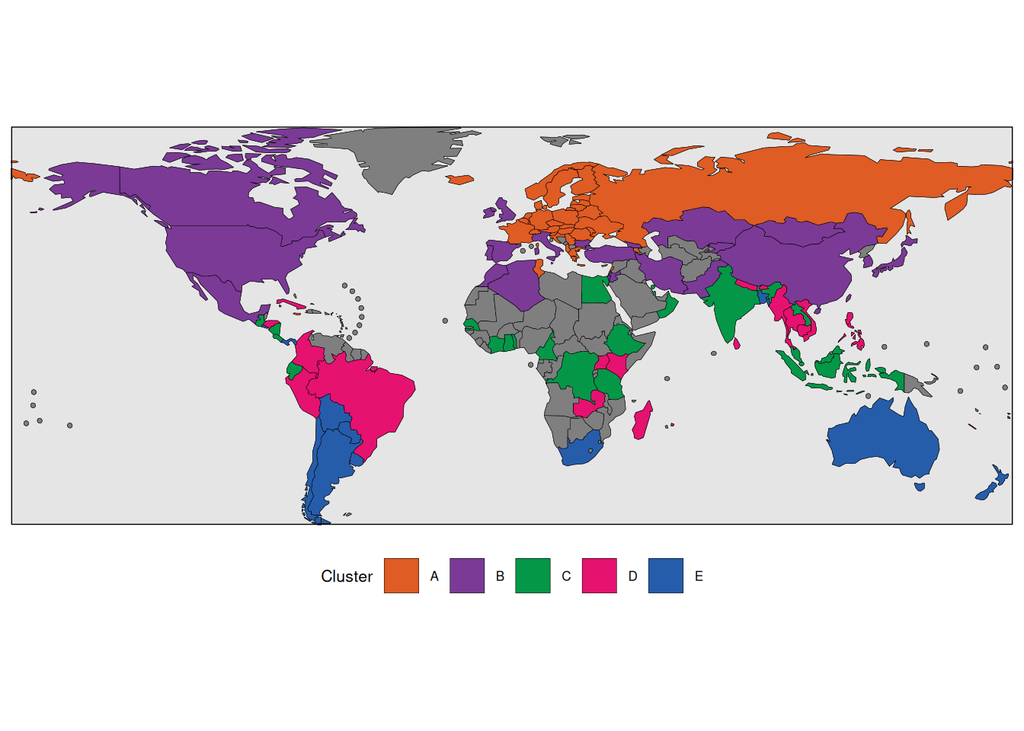

```r
s_figure_3 <- original_map_plot_concise +
  theme(legend.position="bottom",
        panel.grid.major = element_blank(),
        panel.grid.minor = element_blank(),
        panel.border = element_rect(color = "black", fill = NA),
        panel.background = element_rect(fill = "#E5E5E5"),
        axis.title.x=element_blank(),
        axis.text.x=element_blank(),
        axis.ticks.x=element_blank(),
        axis.title.y=element_blank(),
        axis.text.y=element_blank(),
        axis.ticks.y=element_blank(),
        text = element_text(size = 8))


s_figure_3
```

```r
ggsave("plots/s_figure_3.pdf", s_figure_3, units = "in", width = 9.5, height = 4.5)
```

**Supplementary Figure 4:**

```r
s_figure_4 <- ggplot(inf_co_gam_v, aes(x = WEEK, y = inf_clust_fit_new, group = combined_cluster)) +
  geom_point(data = co_comb_pass %>% filter(WEEK < 53), aes(x = WEEK, y = inf_all_burden), alpha = 0.1) +
  geom_ribbon(alpha = 0.5, aes(ymin = inf_clust_lwr_new,
                               ymax = inf_clust_upr_new, fill = combined_cluster)) +
  geom_line(aes(color = combined_cluster)) +
  scale_color_manual(values = c("A" = "#DF5C24",
                                "B" = "#7B3A96",
                                "C" = "#059748",
                                "D" = "#E5126F",
                                "E" = "#265DAB"),
                     breaks = c("A","B","C","D","E")) +
  scale_fill_manual(values = c("A" = "#DF5C24",
                               "B" = "#7B3A96",
                               "C" = "#059748",
                               "D" = "#E5126F",
                               "E" = "#265DAB"),
                    breaks = c("A","B","C","D","E")) +
  ylab("Relative Influenza Burden") +
  xlab("Calendar Week") +
  scale_x_continuous(expand = c(0,0), breaks = c(13,26,39,52), limits = c(0,53)) +
  guides(color=guide_legend(title="Cluster", nrow = 1),
         fill=guide_legend(title="Cluster", nrow = 1)) +
  facet_wrap_paginate(~LABEL, ncol = 4, nrow = 5, page = 1) +
  theme(panel.grid.major = element_blank(), panel.grid.minor = element_blank(),
        axis.line = element_line(colour = "black"),
        legend.position="bottom")

s_figure_4_num_pg <- n_pages(s_figure_4)

pdf("plots/s_figure_4.pdf", paper = "USr", width = 9)
for(i in 1:s_figure_4_num_pg) {
  print(
    ggplot(inf_co_gam_v, aes(x = WEEK, y = inf_clust_fit_new, group = combined_cluster)) +
      geom_point(data = co_comb_pass %>% filter(WEEK < 53), aes(x = WEEK, y = inf_all_burden), alpha = 0.1) +
      geom_ribbon(alpha = 0.5, aes(ymin = inf_clust_lwr_new,
                                   ymax = inf_clust_upr_new, fill = combined_cluster)) +
      geom_line(aes(color = combined_cluster)) +
      scale_color_manual(values = c("A" = "#DF5C24",
                                    "B" = "#7B3A96",
                                    "C" = "#059748",
                                    "D" = "#E5126F",
                                    "E" = "#265DAB"),
                         breaks = c("A","B","C","D","E")) +
      scale_fill_manual(values = c("A" = "#DF5C24",
                                   "B" = "#7B3A96",
                                   "C" = "#059748",
                                   "D" = "#E5126F",
                                   "E" = "#265DAB"),
                        breaks = c("A","B","C","D","E")) +
      ylab("Relative Influenza Burden") +
      xlab("Calendar Week") +
      scale_x_continuous(expand = c(0,0), breaks = c(13,26,39,52), limits = c(0,53)) +
      guides(color=guide_legend(title="Cluster", nrow = 1),
             fill=guide_legend(title="Cluster", nrow = 1)) +
      facet_wrap_paginate(~LABEL, ncol = 4, nrow = 5, page = i) +
      theme(panel.grid.major = element_blank(), panel.grid.minor = element_blank(),
            axis.line = element_line(colour = "black"),
            legend.position="bottom")
  )
}
invisible(dev.off())
```

**Supplementary Figure 5:**

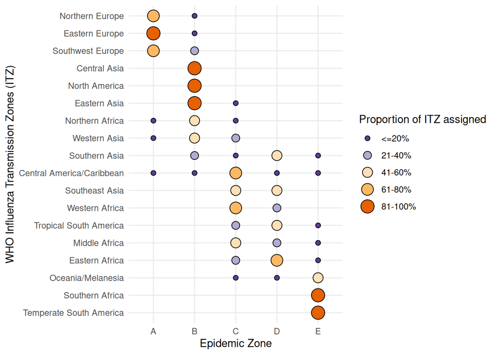

```r
s_figure_5_v1 <- ggplot(comparison, aes(x = combined_cluster, y = itz.name,
                       size = factor(n_prop_cat),
                       fill = factor(n_prop_cat))) +
  geom_point(shape = 21, color = "black") +
  #scale_size_manual() + # Adjust maximum balloon size
  scale_fill_manual(values = c("#5e3c99", "#b2abd2", "#fee0b6", "#fdb863","#e66101")) +
  labs(x = "Epidemic Zone",
       y = "WHO Influenza Transmission Zones (ITZ)",
       size = "Proportion of ITZ assigned",
       fill = "Proportion of ITZ assigned") +
  theme_minimal()

s_figure_5_v1
```

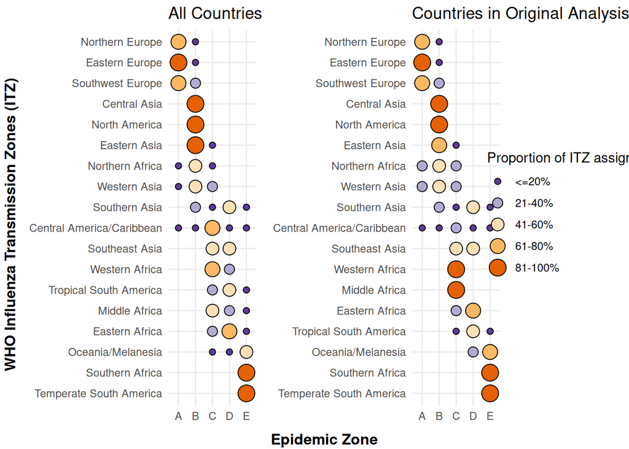

```r
ggsave("plots/s_figure_5_v1.pdf", s_figure_5_v1, units = "in", width = 9, height = 7)



#### original analysis countries only
s_figure_5_v2_a <- ggplot(comparison, aes(x = combined_cluster, y = itz.name,
                       size = factor(n_prop_cat),
                       fill = factor(n_prop_cat))) +
  geom_point(shape = 21, color = "black") +
  #scale_size_manual() + # Adjust maximum balloon size
  scale_fill_manual(values = c("#5e3c99", "#b2abd2", "#fee0b6", "#fdb863","#e66101")) +
  labs(title = "All Countries",
       x = "Epidemic zone clustering",
       y = "WHO Influenza Transmission Zones (ITZ)",
       size = "Proportion of ITZ assigned",
       fill = "Proportion of ITZ assigned") +
  theme_minimal()


s_figure_5_v2_b <- ggplot(comparison_original, aes(x = combined_cluster, y = itz.name,
                       size = factor(n_prop_cat),
                       fill = factor(n_prop_cat))) +
  geom_point(shape = 21, color = "black") +
  #scale_size_manual() + # Adjust maximum balloon size
  scale_fill_manual(values = c("#5e3c99", "#b2abd2", "#fee0b6", "#fdb863","#e66101")) +
  labs(title = "Countries in Original Analysis",
       x = "Epidemic zone clustering",
       y = "WHO Influenza Transmission Zones (ITZ)",
       size = "Proportion of ITZ assigned",
       fill = "Proportion of ITZ assigned") +
  theme_minimal()

### Combined

s_figure_5_v2_leg <- ggpubr::as_ggplot(ggpubr::get_legend(s_figure_5_v2_a))

s_figure_5_v2_int <- plot_grid(s_figure_5_v2_a +
                                 theme(axis.title = element_blank(), axis.title.y=element_blank(),
                                       legend.position = "none"),
                               s_figure_5_v2_b  +
                                 theme(axis.title = element_blank(), axis.title.y=element_blank(),
                                       legend.position = "none"),
                               s_figure_5_v2_leg,
                               ncol = 3, rel_widths = c(1, 1, 0.5))

# create common x and y labels
y.grob <- textGrob("WHO Influenza Transmission Zones (ITZ)",
                   gp=gpar(fontface="bold", col="black", fontsize=12), rot=90)

x.grob <- textGrob("Epidemic Zone",
                   gp=gpar(fontface="bold", col="black", fontsize=12))

# add labels to plot
ggsave("plots/s_figure_5_v2.pdf",
       grid.arrange(arrangeGrob(s_figure_5_v2_int, left = y.grob, bottom = x.grob)),
       units = "in", width = 11, height = 8.5)
```

```r
save.image(file = "epidemic_zones.RData") # for saving all analysis if needed
```

## References

Fischer, William A., Michelle Gong, Satish Bhagwanjee, and Jonathan Sevransky. 2014. “Global Burden of Influenza: Contributions from Resource Limited and Low-Income Settings.” *Global Heart* 9 (3): 325–36. https://doi.org/10.1016/j.gheart.2014.08.004.

GeoNames. n.d. *GeoNames Geographical Database*. https://www.geonames.org/.

Igboh, Ledor S., Katherine Roguski, Perrine Marcenac, et al. 2023. “Timing of Seasonal Influenza Epidemics for 25 Countries in Africa During 2010–19: A Retrospective Analysis.” *The Lancet Global Health* 11 (May): e729–39. https://doi.org/10.1016/S2214-109X(23)00109-2.

Ng, Andrew, Michael Jordan, and Yair Weiss. 2001. *On Spectral Clustering: Analysis and an Algorithm*. 14: 849–56. https://proceedings.neurips.cc/paper_files/paper/2001/file/801272ee79cfde7fa5960571fee36b9b-Paper.pdf.

Pedersen, Eric J., David L. Miller, Gavin L. Simpson, and Noam Ross. 2019. “Hierarchical Generalized Additive Models in Ecology: An Introduction with Mgcv.” *PeerJ* 7: e6876. https://doi.org/10.7717/peerj.6876.

United Nations Statistics Division. n.d. *Standard Country or Area Codes for Statistical Use (M49)*. United Nations Statistics Division. https://unstats.un.org/unsd/methodology/m49/.

Wood, Simon N. 2011. “Fast Stable Restricted Maximum Likelihood and Marginal Likelihood Estimation of Semiparametric Generalized Linear Models.” *Journal of the Royal Statistical Society: Series B (Statistical Methodology)* 73 (1): 3–36. https://doi.org/10.1111/j.1467-9868.2010.00749.x.

World Health Organization. n.d.-a. *FluNet*. World Health Organization. https://www.who.int/tools/flunet.

World Health Organization. n.d.-b. *WHO Country Boundary Shapefile*. World Health Organization.